# Project 5: US Births

DS202 Group Summative Assessment

Author

[Group Members]

Published

February 9, 2026

# Project 5: US Births (2014)

Birth weight and gestational age are critical indicators of infant health. Low birth weight (below 5.5lbs) and preterm birth (before 37 weeks) are associated with increased infant mortality, developmental delays, and chronic health conditions later in life (Hack et al, 1995). In the United States, approximately 8% of infants are born with low birth weight and 10% are born preterm, with substantial disparities across racial and socioeconomic groups (Martin et al, 2018).

This project analyses 1,000 US births from 2014, examining maternal characteristics (age, smoking, marital status, race), prenatal care (visits, weight gained), and birth outcomes (weight, gestational weeks, prematurity status). We examine two primary outcomes: birth weight and gestational age. Birth weight receives primary focus due to its direct clinical significance, while gestational weeks serve both as an outcome of interest and as a potential mediator in pathways affecting birth weight.

The research question guiding this analysis asks: **How do observed relationships between maternal characteristics and birth outcomes change once relevant subgroups are taken into account, and under what assumptions could any effects be interpreted causally?**

```r
# Core data manipulation and formatting
library(tidyverse)
library(knitr)
library(broom)
library(kableExtra)

# Visualization
library(ggplot2)
library(corrplot)
library(scales)

# Clustering
library(cluster)
library(mclust)
library(factoextra)
library(patchwork)
library(reshape2)

# Causal inference / Propensity score matching
library(MatchIt)
library(cobalt)

# Tree-based models
library(rpart)
library(rpart.plot)
library(vip)

# Tidymodels framework
library(tidymodels)

# Set seed for reproducibility
set.seed(123)
```

# Part 1: Investigating the data set

We first load the dataset from OpenIntro: US Births, 2014 into our working directory. We can then read in and glimpse the dataframe.

```r
data <- read.csv("births14.csv")

glimpse(data)
```

```
Rows: 1,000
Columns: 13
$ fage           <int> 34, 36, 37, NA, 32, 32, 37, 29, 30, 29, 30, 34, 28, 28,…
$ mage           <int> 34, 31, 36, 16, 31, 26, 36, 24, 32, 26, 34, 27, 22, 31,…
$ mature         <chr> "younger mom", "younger mom", "mature mom", "younger mo…
$ weeks          <int> 37, 41, 37, 38, 36, 39, 36, 40, 39, 39, 42, 40, 40, 39,…
$ premie         <chr> "full term", "full term", "full term", "full term", "pr…
$ visits         <int> 14, 12, 10, NA, 12, 14, 10, 13, 15, 11, 14, 16, 20, 15,…
$ gained         <int> 28, 41, 28, 29, 48, 45, 20, 65, 25, 22, 40, 30, 31, NA,…
$ weight         <dbl> 6.96, 8.86, 7.51, 6.19, 6.75, 6.69, 6.13, 6.74, 8.94, 9…
$ lowbirthweight <chr> "not low", "not low", "not low", "not low", "not low", …
$ sex            <chr> "male", "female", "female", "male", "female", "female",…
$ habit          <chr> "nonsmoker", "nonsmoker", "nonsmoker", "nonsmoker", "no…
$ marital        <chr> "married", "married", "married", "not married", "marrie…
$ whitemom       <chr> "white", "white", "not white", "white", "white", "white…
```

From the glimpse of the data set, we see it contains a mix of numeric and categorical variables related to the mother, father, and birth outcomes.

We next clean categorical variables by ensuring they are treated as factors.

```r
data <- data %>%
  mutate(across(c(mature, premie, lowbirthweight, sex, habit, marital, whitemom), as.factor))
```

## 1.1 Variable Descriptions

| Variable | Description | Variable type |
| --- | --- | --- |
| `fage` | Father’s age | Numeric (years) |
| `mage` | Mother’s age | Numeric (years) |
| `mature` | Mother’s maturity status | Categorical (`younger mom` or `mature mom`) |
| `weeks` | Gestation length | Numeric (weeks) |
| `premie` | Prematurity status | Categorical (`full term` or `premie`) |
| `visits` | Number of prenatal visits | Numeric |
| `gained` | Pregnancy weight gain | Numeric (lbs) |
| `weight` | Birthweight | Numeric (lbs) |
| `lowbirthweight` | Low birthweight indicator | Categorical (`low` or `not low`) |
| `sex` | Baby’s sex | Categorical (`female` or `male`) |
| `habit` | Mother’s smoking status | Categorical (`smoker` or `nonsmoker`) |
| `marital` | Mother’s marital status | Categorical (`married` or `not married`) |
| `whitemom` | Mother’s race | Categorical (`white` or `not white`) |

One limitation we immediately note is that `whitemom` is binary rather than a multi-leveled race variable. This prevents us from distinguishing between different racial and ethnic minority groups, limiting our ability to examine disparities across non-white populations in a racially diverse country. Similarly, the binary `habit` variable does not capture smoking intensity (cigarettes per day) or timing during pregnancy, potentially masking dose-response relationships.

We also immediately see that several variables represent the same underlying phenomena in different formats. `lowbirthweight` is a binary threshold of continuous `weight`, `premie` categorises continuous `weeks`, and `mature` splits continuous `mage` into age groups. These pairs are highly correlated by definition and would introduce multicollinearity if used together in models. We use binary measures to examine threshold effects such as clinical cutoffs for low birth weight and continuous measures to capture full variability in relationships.

## 1.2 Missingness

Understanding the patterns and mechanisms of missing data is critical before proceeding with analysis, as inappropriate handling can introduce bias into our estimates. Four variables in this dataset contain missing values, each requiring a different approach based on the missingness pattern and the variable’s role in our analysis.

```r
missing_summary <- data %>%
  summarise(across(everything(), ~sum(is.na(.)))) %>%
  pivot_longer(everything(), names_to = "Variable", values_to = "Missing") %>%
  mutate(
    Total = nrow(data),
    Percent = round(Missing / Total * 100, 2)
  ) %>%
  arrange(desc(Missing)) %>%
  filter(Missing > 0)

kable(missing_summary, caption = "Missing Data Summary")
```

Missing Data Summary

| Variable | Missing | Total | Percent |
| --- | --- | --- | --- |
| fage | 114 | 1000 | 11.4 |
| visits | 56 | 1000 | 5.6 |
| gained | 42 | 1000 | 4.2 |
| habit | 19 | 1000 | 1.9 |

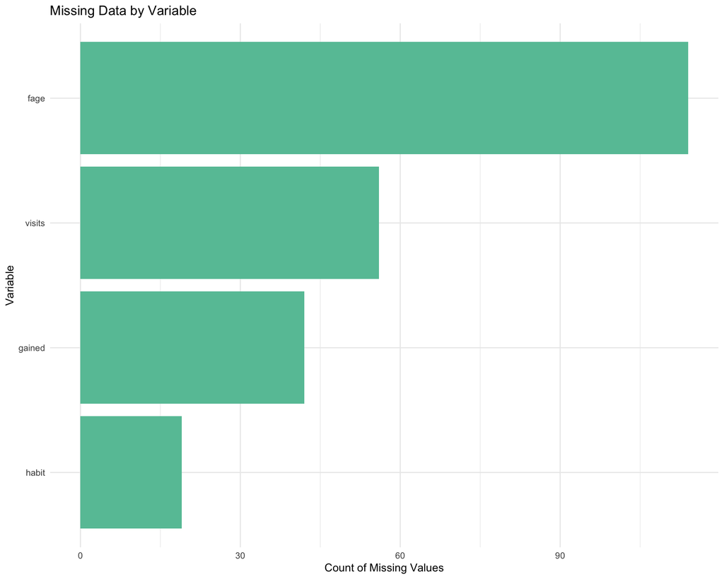

```r
ggplot(missing_summary, aes(x = reorder(Variable, Missing), y = Missing)) +
  geom_col(fill='#66C2A5') +
  coord_flip() +
  labs(title = "Missing Data by Variable",
       x = "Variable", y = "Count of Missing Values") +
  theme_minimal()
```

*Smoking status (1.9% missing):* nineteen observations (1.9%) lack smoking status information. Since maternal smoking is our primary exposure variable (the central focus of our analysis), we cannot meaningfully include these observations. Imputation would be inappropriate as it would involve adding noise and estimation to the key variable we are trying to study. These rows were excluded, yielding a final analytic sample of n = 981. Although we do not formally assess the missingness mechanism, the small proportion of excluded observations makes substantial bias unlikely.

```r
data <- data %>%
  filter(!is.na(habit))
```

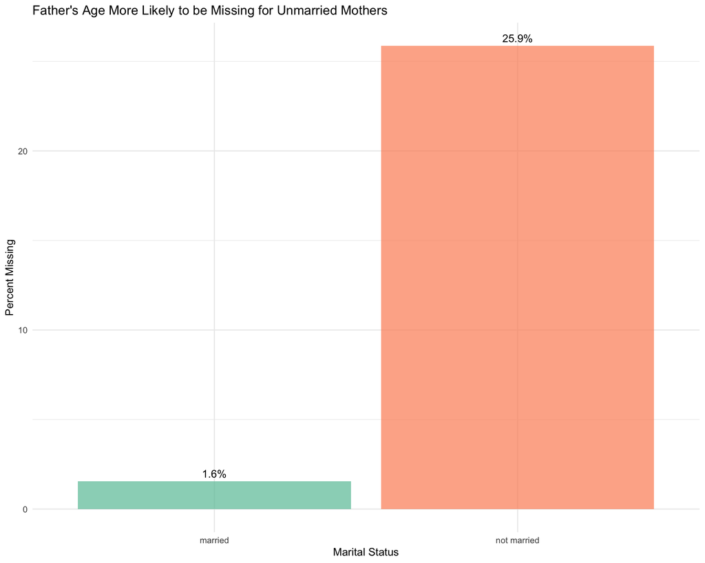

```r
data %>%
  group_by(marital) %>%
  summarise(
    Total = n(),
    Missing_fage = sum(is.na(fage)),
    Pct_Missing = Missing_fage / Total * 100,
    .groups = "drop"
  ) %>%
  ggplot(aes(x = marital, y = Pct_Missing, fill = marital)) +
  geom_bar(stat = "identity", alpha = 0.7) +
  geom_text(aes(label = sprintf("%.1f%%", Pct_Missing)), vjust = -0.5) +
  labs(
    title = "Father's Age More Likely to be Missing for Unmarried Mothers",
    x = "Marital Status",
    y = "Percent Missing"
  ) +
  theme_minimal() +
  theme(legend.position = "none") +
  scale_fill_brewer(palette = "Set2")
```

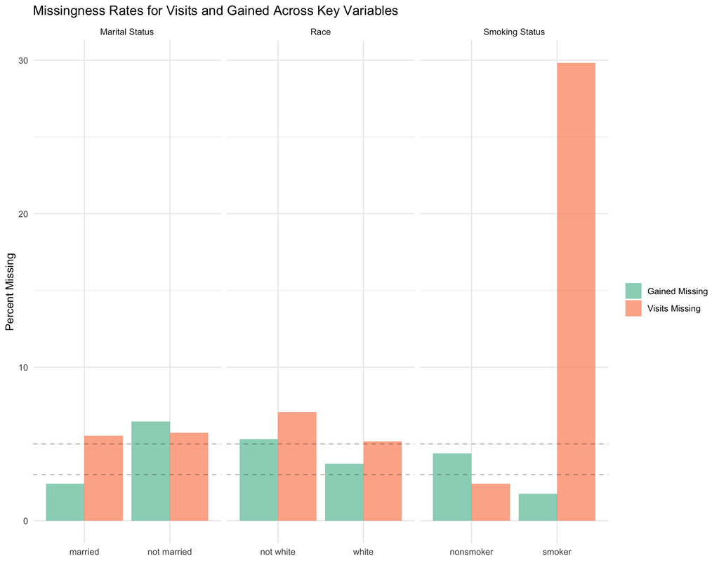

```r
data_missing_check <- data %>%
  mutate(
    visits_missing = is.na(visits),
    gained_missing = is.na(gained)
  )

missing_viz_data <- bind_rows(
  data_missing_check %>%
    group_by(habit) %>%
    summarise(
      `Visits Missing` = mean(visits_missing) * 100,
      `Gained Missing` = mean(gained_missing) * 100,
      .groups = "drop"
    ) %>%
    pivot_longer(-habit, names_to = "Variable", values_to = "Pct_Missing") %>%
    rename(Group = habit) %>%
    mutate(Category = "Smoking Status"),

  data_missing_check %>%
    group_by(marital) %>%
    summarise(
      `Visits Missing` = mean(visits_missing) * 100,
      `Gained Missing` = mean(gained_missing) * 100,
      .groups = "drop"
    ) %>%
    pivot_longer(-marital, names_to = "Variable", values_to = "Pct_Missing") %>%
    rename(Group = marital) %>%
    mutate(Category = "Marital Status"),

  data_missing_check %>%
    group_by(whitemom) %>%
    summarise(
      `Visits Missing` = mean(visits_missing) * 100,
      `Gained Missing` = mean(gained_missing) * 100,
      .groups = "drop"
    ) %>%
    pivot_longer(-whitemom, names_to = "Variable", values_to = "Pct_Missing") %>%
    rename(Group = whitemom) %>%
    mutate(Category = "Race")
)

ggplot(missing_viz_data, aes(x = Group, y = Pct_Missing, fill = Variable)) +
  geom_bar(stat = "identity", position = "dodge", alpha = 0.7) +
  facet_wrap(~ Category, scales = "free_x") +
  geom_hline(yintercept = c(3, 5), linetype = "dashed", alpha = 0.3) +
  labs(
    title = "Missingness Rates for Visits and Gained Across Key Variables",
    x = "",
    y = "Percent Missing",
    fill = ""
  ) +
  theme_minimal() +
  scale_fill_brewer(palette = "Set2")
```

*Prenatal visits (5.6% missing)*: although overall missingness in the number of prenatal visits is modest, stratified analysis reveals a highly non-random pattern: approximately 30% of smokers have missing prenatal visit data, compared to only 2.5% of nonsmokers. Excluding observations with missing visits would therefore disproportionately remove smokers from the analytic sample, exacerbating an existing class imbalance and selectively excluding the group whose outcomes are central to our research question.

Moreover, prenatal visits plausibly lie downstream of smoking behaviour rather than acting solely as a pre-treatment confounder. Quantitative and clinical research documents that smoking during pregnancy is associated with stigma, concealment, and strained interactions with healthcare providers, which can reduce engagement with prenatal care services (Grant et al, 2018). Conversely, reduced contact with prenatal care may limit access to smoking cessation counselling, reinforcing smoking behaviour. Conditioning on prenatal visits when estimating the total effect of smoking on birth outcomes may therefore induce post-treatment bias by blocking or distorting part of the causal pathway (Montgomery et al, 2021).

For these reasons, observations with missing prenatal visit data are retained in the main analytic sample. Prenatal visits are treated cautiously in subsequent analyses, and, when included in regression or causal models, are explicitly interpreted as potential mediators rather than unambiguous confounders. Results conditioning on prenatal visits are therefore reported with appropriate caveats.

*Weight gained during pregnancy (4.1% missing)*: weight gained during pregnancy has a moderate level of missingness. Missingness is slightly more common among unmarried and non-white mothers, but does not display a strong differential pattern by smoking status, our primary exposure. This reduces concern that missingness in this variable would substantially bias comparisons between smokers and non-smokers.

Given the low overall rate of missingness and the absence of problematic confounding with smoking, observations with missing weight gain values are retained in the dataset. Models that include weight gained are estimated on complete cases for this variable, with the resulting reduction in sample size explicitly noted where applicable.

## 1.3 Numeric Variables

```r
numeric_vars <- data %>% dplyr::select(where(is.numeric))

numeric_summary <- data.frame(
  Variable = names(numeric_vars),
  N = sapply(numeric_vars, function(x) sum(!is.na(x))),
  Mean = sapply(numeric_vars, function(x) round(mean(x, na.rm = TRUE), 2)),
  SD = sapply(numeric_vars, function(x) round(sd(x, na.rm = TRUE), 2)),
  Min = sapply(numeric_vars, function(x) round(min(x, na.rm = TRUE), 2)),
  Median = sapply(numeric_vars, function(x) round(median(x, na.rm = TRUE), 2)),
  Max = sapply(numeric_vars, function(x) round(max(x, na.rm = TRUE), 2))
)

kable(numeric_summary, caption = "Summary Statistics for Numeric Variables", row.names = FALSE)
```

Summary Statistics for Numeric Variables

| Variable | N | Mean | SD | Min | Median | Max |
| --- | --- | --- | --- | --- | --- | --- |
| fage | 868 | 31.08 | 7.06 | 15.00 | 31.00 | 85.00 |
| mage | 981 | 28.41 | 5.75 | 14.00 | 28.00 | 47.00 |
| weeks | 981 | 38.67 | 2.55 | 21.00 | 39.00 | 46.00 |
| visits | 926 | 11.36 | 4.09 | 0.00 | 12.00 | 30.00 |
| gained | 941 | 30.48 | 15.34 | 0.00 | 30.00 | 98.00 |
| weight | 981 | 7.20 | 1.29 | 0.75 | 7.31 | 10.42 |

*Summary Statistics for Numeric Variables*

The numeric variables capture parental demographics, prenatal care intensity, and birth outcomes. Birth weight has a mean of 7.20 lbs (SD=1.29), with values ranging from 0.75 to 10.42 lbs. The lower bound reflects extremely preterm or very low birth weight births rather than implausible measurements. Gestational age averaged 38.67 weeks (SD=2.55), with a minimum of 21 weeks, indicating the presence of very preterm deliveries in the sample.

Maternal age has a mean of 28.41 years (ranging from 14 to 47), consistent with typical childbearing ages (CDC, 2025), while father’s age averages slightly higher at 31.08 years (ranging from 15 to 85). Although the upper bound for father’s age is unusually high, it is not biologically implausible. As noted earlier, this variable also exhibits the highest level of missingness and is therefore not used in subsequent modelling.

Measures of prenatal care show substantial variability. The number of prenatal visits averages 11.36 (SD=4.09), spanning from 0 to 30 visits, while pregnancy weight gain averages 30.48 lbs (SD=15.34), with values ranging from 0 to 98 lbs. Zero values in both variables may reflect limited access to care of measurement limitations rather than true absence of prenatal engagement, and are retained to preserve variation in prenatal experiences.

Across all numeric variables, means and medians are closely aligned, suggesting no severe skewness. Visual inspection of histograms (shown below) confirms broadly regular distributions without extreme outliers. As a result, no transformations such as logarithmic scaling are required for subsequent analysis, and the variables exhibit sufficient variation to be informative predictors in later modelling stages.

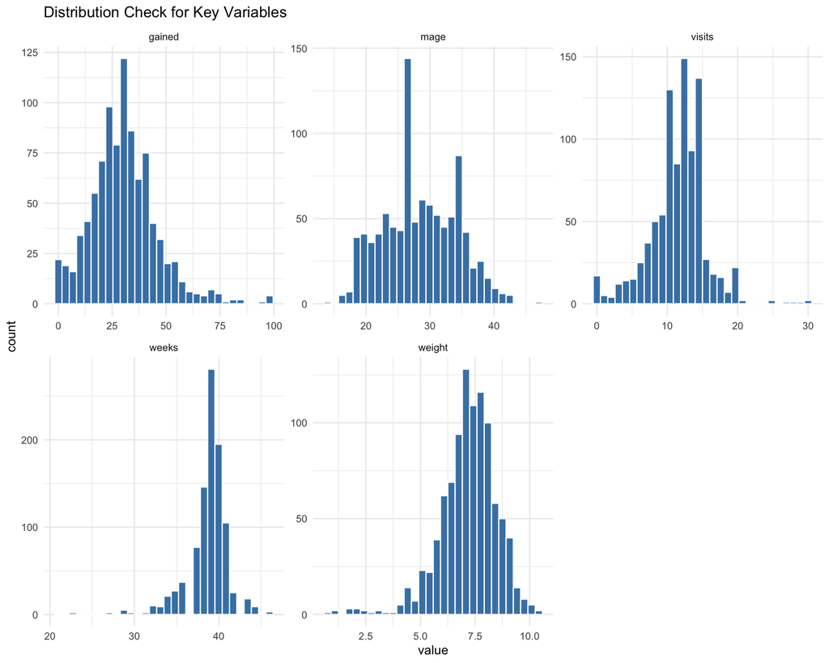

```r
data %>%
  dplyr::select(weight, weeks, mage, visits, gained) %>%
  pivot_longer(everything()) %>%
  ggplot(aes(x = value)) +
  geom_histogram(bins = 30, fill = "steelblue", color = "white") +
  facet_wrap(~name, scales = "free") +
  theme_minimal() +
  labs(title = "Distribution Check for Key Variables")
```

*Distribution of Numeric Variables + Outliers*

Visual inspection of the numeric variables indicates distributions that are broadly consistent with expected clinical patterns and suitable for subsequent modelling. Pregnancy weight gain displays moderate right skew, with most observations concentrated between approximately 15 and 40 lbs and a centre around 25-30 lbs. A small number of observations extend towards higher values, approaching 100 lbs. Current clinical guidelines from the US Institute of Medicine recommend gestational weight gain ranges between roughly 11 and 40 lbs, depending on the pre-pregnancy body mass index, while documenting that gains above these thresholds are observed in practice (Rasmussen and Yaktine, 2009). Values at the upper end of the distribution are therefore plausible and may reflect high-risk pregnancies, underlying health conditions, or heterogeneity in measurement rather than data errors.

Gestational age shows the expected left-skewed distribution, with most births clustered around full term (39-40 weeks) and a left tail extending to approximately 22 weeks, representing very preterm deliveries. Birth weight is approximately normally distributed around 7 lbs, with a left tail capturing low birth weight infants. Importantly, extremely low birth weight values align with very early gestational ages in the week’s distribution, providing internal consistency across variables and supporting the interpretation that these observations reflect genuine clinical outcomes rather than recording errors.

Across all numeric variables, no biologically implausible values were identified such as negative weights or gestational ages exceeding feasible limits. Given the modest sample size (n=1000), removing extreme but plausible observations would risk discarding meaningful variation, particularly for outcomes of clinical interest. All observations are therefore retained.

From a modelling perspective, the absence of extreme skewness or heavy tails suggests that these variables can be incorporated directly into linear and semi-parametric models without transformation. At the same time, the observed variability in prenatal care measures, gestational age, and birth weight provides sufficient dispersion for these variables to function as informative predictors and outcomes in subsequent analyses.

## 1.4 Categorical Variables

```r
cat_vars <- c("mature", "premie", "lowbirthweight", "sex", "habit", "marital", "whitemom")

cat_summary <- data %>%
  dplyr::select(all_of(cat_vars)) %>%
  pivot_longer(everything(), names_to = "Variable", values_to = "Level") %>%
  dplyr::count(Variable, Level) %>%
  group_by(Variable) %>%
  mutate(Percent = round(n / sum(n) * 100, 1)) %>%
  ungroup()

kable(cat_summary, caption = "Frequency Distribution of Categorical Variables")
```

Frequency Distribution of Categorical Variables

| Variable | Level | n | Percent |
| --- | --- | --- | --- |
| habit | nonsmoker | 867 | 88.4 |
| habit | smoker | 114 | 11.6 |
| lowbirthweight | low | 78 | 8.0 |
| lowbirthweight | not low | 903 | 92.0 |
| marital | married | 579 | 59.0 |
| marital | not married | 402 | 41.0 |
| mature | mature mom | 155 | 15.8 |
| mature | younger mom | 826 | 84.2 |
| premie | full term | 860 | 87.7 |
| premie | premie | 121 | 12.3 |
| sex | female | 488 | 49.7 |
| sex | male | 493 | 50.3 |
| whitemom | not white | 226 | 23.0 |
| whitemom | white | 755 | 77.0 |

*Frequency Distribution of Categorical Variables*

The above table summarises the distribution of categorical variables capturing maternal characteristics and birth outcomes. Maternal smoking during pregnancy is relatively uncommon in this sample, 11.6% of mothers are classified as smokers (n=114), while 88.4% are nonsmokers (n=867). This imbalance is important for subsequent subgroup comparisons and model precision, particularly in analyses that stratify by demographic characteristics.

Adverse birth outcomes are also relatively infrequent. Low birth weights account for 8.0% of observations (n=78), and preterm births account for 12.3% (n=121). The low birth weight prevalence matches reported national estimates for 2014 (8.0%), while the sample preterm rate is higher than the national estimate reported for 2014 (~9.6% using the measure reported in CDC statistics), which is plausible given sampling variability and definitional differences in prematurity indicators (CDC, 2015). We therefore interpret these outcome frequencies as clinically plausible and not suggestive of data quality problems.

With respect to maternal demographics, 59.0% of mothers in the sample are married, 77.0% are classified as white, and 15.8% are categorised as ‘mature mothers’ (aged 35 or older). Infant sex is approximately evenly split (49.7% female, 50.3% male), consistent with expected sex ratios at birth. A key limitation is that the race variable is binary, which prevents analysis of heterogeneity across specific racial/ethnic groups; this limitation is revised in later sections.

From a modelling perspective, we note class imbalance in both binary outcomes, particularly low birth weight (8%) and prematurity (12.3%). While not extreme, this motivates careful interpretation of subgroup event rates and supports retaining both continuous outcomes (birth weight, gestational weeks) and binary indicators (low birth weight, prematurely) to capture potential threshold effects that mean comparisons alone may miss.

# Part 2: Bivariate Relationships

Having established the structure and quality of the dataset, we next examine bivariate relationships between maternal characteristics and birth outcomes. The aim of this stage is exploratory: to identify which predictors exhibit meaningful associations with birth outcomes and therefore warrant deeper investigations in subsequent modelling and subgroup analyses.

We treat prematurity and low birth weight as outcomes rather than predictors, reflecting their interpretation as adverse birth events. We retain both continuous outcomes, birth weight (lbs) and gestational lengths (weeks), and their binary counterparts to capture complementary aspects of risk. Continuous measures reflect shifts across the full outcome distribution, while binary indicators correspond to clinically meaningful thresholds that may not be evident from mean differences alone (Kramer, 1987).

This dual representation is important because maternal behaviours, demographics, and prenatal care may influence birth outcomes through multiple pathways. Factors such as smoking, maternal age, marital status, race, and prenatal care utilisation have been shown to affect both gestational duration and fetal growth, sometimes independently (Cnattingius, 2004). Examining both weeks and weight therefore allows us to assess whether associations operate through earlier delivery, restricted growth, or both.

In the sections that follow, categorical procedures are screened using mean differences and differences in outcome rates, while continuous predictors are examined via correlations. These results inform outcome prioritisation, motivate smoking as the primary exposure of interest, and guide the modelling and subgroup analyses developed later.

## 2.1 Screening Categorical Predictors

We assess how each categorical predictor relates to our four candidate outcomes. We report mean differences for continuous outcomes and percentage-point differences in event rates for binary outcomes.

*Continuous outcomes*

```r
cat_vars <- c("habit", "marital", "whitemom", "sex", "mature")
cat_labels <- c(habit = "Smoking status", marital = "Marital status",
                whitemom = "Mother's race", sex = "Baby's sex",
                mature = "Mother's Age Group")

screen_continuous <- map_dfr(cat_vars, function(var) {
  d <- data %>%
    filter(!is.na(.data[[var]])) %>%
    mutate("{var}" := droplevels(factor(.data[[var]])))

  levs <- levels(d[[var]])

  g1 <- d %>% filter(.data[[var]] == levs[1])
  g2 <- d %>% filter(.data[[var]] == levs[2])

  tibble(
    Predictor = cat_labels[var],
    Comparison = sprintf("%s − %s", levs[1], levs[2]),
    `n₁ / n₂` = sprintf("%d / %d", nrow(g1), nrow(g2)),
    `Δ Weight (lbs)` = sprintf("%+.2f", mean(g1$weight, na.rm = TRUE) - mean(g2$weight, na.rm = TRUE)),
    `Δ Weeks` = sprintf("%+.2f", mean(g1$weeks, na.rm = TRUE) - mean(g2$weeks, na.rm = TRUE))
  )
})

kable(screen_continuous,
      caption = 'Association of Categorical Predictors with Continuous Birth Outcomes')
```

Association of Categorical Predictors with Continuous Birth Outcomes

| Predictor | Comparison | n₁ / n₂ | Δ Weight (lbs) | Δ Weeks |
| --- | --- | --- | --- | --- |
| Smoking status | nonsmoker − smoker | 867 / 114 | +0.59 | +0.76 |
| Marital status | married − not married | 579 / 402 | +0.24 | +0.23 |
| Mother’s race | not white − white | 226 / 755 | -0.41 | -0.42 |
| Baby’s sex | female − male | 488 / 493 | -0.35 | +0.07 |
| Mother’s Age Group | mature mom − younger mom | 155 / 826 | +0.20 | -0.11 |

Smoking stands out as the largest gap across both continuous outcomes. Babies born to nonsmokers weigh on average 0.59 lbs more and are born 0.76 weeks later than those born to smokers. Mother’s race shows a comparably large association with birth weight (-0.41 lbs) and gestational length (-0.42 weeks), with non-white mothers experiencing worse outcomes on average. Marital status, maternal age group, and infant sex show smaller but notable differences.

These comparisons are purely descriptive and unadjusted, but they highlight smoking and race as the most salient predictors at this stage. Importantly, smoking prevalence differs across demographic groups that also exhibit baseline differences in birth outcomes, suggesting potential confounding. This motivates closer examination of subgroup structure and adjusted analyses in subsequent sections.

*Binary outcomes*

```r
screen_binary <- map_dfr(cat_vars, function(var) {
  d <- data %>%
    filter(!is.na(.data[[var]])) %>%
    mutate("{var}" := droplevels(factor(.data[[var]])))

  levs <- levels(d[[var]])
  if (length(levs) != 2) return(NULL)

  g1 <- d %>% filter(.data[[var]] == levs[1])
  g2 <- d %>% filter(.data[[var]] == levs[2])

  prem1 <- mean(g1$premie == "premie", na.rm = TRUE) * 100
  prem2 <- mean(g2$premie == "premie", na.rm = TRUE) * 100

  lbw1 <- mean(g1$lowbirthweight == "low", na.rm = TRUE) * 100
  lbw2 <- mean(g2$lowbirthweight == "low", na.rm = TRUE) * 100

  tibble(
    Predictor = cat_labels[var],
    Comparison = sprintf("%s − %s", levs[1], levs[2]),
    `n₁ / n₂` = sprintf("%d / %d", nrow(g1), nrow(g2)),
    `Δ Premie rate (pp)` = sprintf("%+.1f", prem1 - prem2),
    `Δ LBW rate (pp)` = sprintf("%+.1f", lbw1 - lbw2)
  )
})

kable(screen_binary,
      caption = 'Association of Categorical Predictors with Binary Birth Outcomes')
```

Association of Categorical Predictors with Binary Birth Outcomes

| Predictor | Comparison | n₁ / n₂ | Δ Premie rate (pp) | Δ LBW rate (pp) |
| --- | --- | --- | --- | --- |
| Smoking status | nonsmoker − smoker | 867 / 114 | -10.9 | -14.8 |
| Marital status | married − not married | 579 / 402 | +0.2 | -2.1 |
| Mother’s race | not white − white | 226 / 755 | +4.7 | +4.0 |
| Baby’s sex | female − male | 488 / 493 | -2.9 | +1.3 |
| Mother’s Age Group | mature mom − younger mom | 155 / 826 | +3.7 | +1.3 |

The binary outcomes amplify smoking’s signal, babies born to smokers have a 10.9pp higher prematurity rate and a 14.8pp higher low birth weight rate. These gaps are large relative to the baseline prevalences of prematurity (12.3%) and low birth weight (8.0%), indicating that smoking is strongly associated with crossing clinically defined risk thresholds rather than merely shifting average outcomes.

Mother’s race shows a consistent 4-5pp elevation in both adverse outcomes for non-white mothers. While these differences are smaller than those observed for smoking, they mirror patterns seen in the continuous outcomes, suggesting race is associated with broad shifts in risk rather than effects concentrated solely at the extremes. This divergence between continuous and binary representations highlights the importance of retaining both outcome types.

Maternal age group shows a moderate but consistent relationship, with older mothers experiencing higher rates of prematurity and low birth weight. Marital status, which displayed a noticeable mean birth weight difference in the continuous outcomes, shows almost no difference in prematurity rates (+0.2pp), suggesting that this association may operate primarily within the normal range rather than at clinical thresholds.

As with the continuous outcomes, these comparisons are unadjusted and descriptive. Nevertheless, they reinforce smoking and race as the most salient predictors and motivate careful adjustment for confounding in subsequent analyses.

## 2.2 Screening Continuous Predictors

To assess associations involving continuous predictors, we examine a correlation matrix that includes all continuous variables and numerically encoded binary outcomes (1= event, 0= no event). This provides a compact summary of pairwise relationships with all four outcomes and allows us to assess potential redundancy among predictors, both of which are important for subsequent model specification. Correlations are computed using pairwise complete observations; associations involving prenatal visits should be interpreted cautiously given its non-random missingness, as mentioned previously in Part 1.

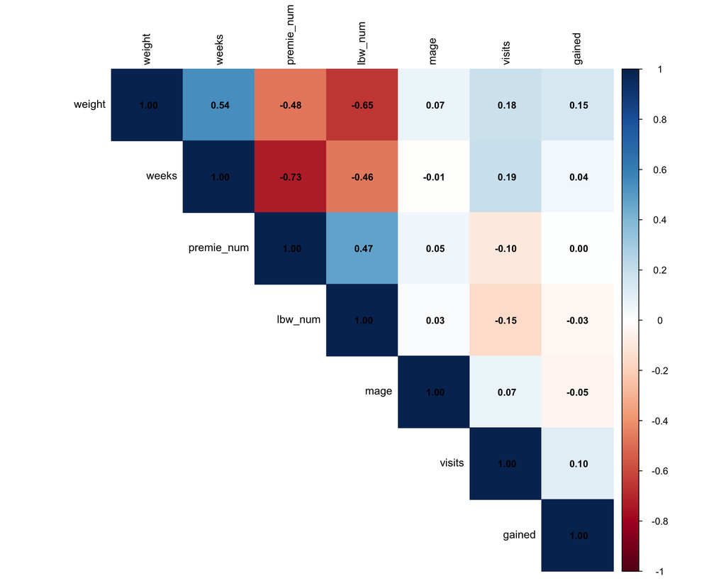

```r
data %>%
  mutate(
    premie_num = as.numeric(premie == "premie"),
    lbw_num = as.numeric(lowbirthweight == "low")
  ) %>%
  dplyr::select(weight, weeks, premie_num, lbw_num, mage, visits, gained) %>%
  cor(use = "pairwise.complete.obs") %>%
  corrplot(method = "color", type = "upper",
           addCoef.col = "black", number.cex = 0.8,
           tl.col = "black", tl.cex = 0.9)
```

As expected, strong correlations are observed among outcome variables that capture closely related aspects of birth outcomes. Birth weight and gestational length are positively correlated (r=0.54), while both are strongly negatively correlated with their corresponding binary indicators for prematurity and low birth weight. These patterns confirm internal consistency across outcome measures and reinforce the decision to avoid including multiple representations of the same outcome simultaneously in regression models.

Among the remaining predictors, maternal age, prenatal visits, and pregnancy weight gain show only weak correlations with birth outcomes (|r| ≤ 0.2). Prenatal visits are modestly negatively correlated with prematurity and low birth weight, which is intuitively plausible but may also reflect selection effects related to smoking or pregnancy risk rather than a direct protective effect. Importantly, correlations among predictors themselves are uniformly slow, indicating no obvious multicollinearity concerns at this stage.

Taken together, these results suggest that continuous predictors provide complementary rather than redundant information and can be included jointly in multivariable models. At the same time, the strong correlations between gestational weeks and birth weight highlight a potential mediation structure, motivating careful consideration of whether gestational age should be treated as a covariate or outcome in later modelling.

## 2.3 Preliminary Screening Summary and Transition to Clustering

Taken together, the categorical screening results and the correlation analysis reveal a clear hierarchy among predictors of birth outcomes. Although all comparisons are descriptive and unadjusted, several patterns are sufficiently strong and consistent to guide the next stage of analysis.

**Smoking emerges as the dominant predictor:** Among categorical predictors, maternal smoking shows the largest and most consistent associations across all four outcomes: a 0.59 lb deficit in birth weight, 0.76 fewer gestational weeks, and 10.9 and 14.8 percentage-point elevations in prematurity and low birth weight respectively. These differences are large in both absolute and relative relative to baseline outcome prevalences, motivating smoking as the primary exposure of interest in subsequent analyses.

**Mother’s race shows strong consistent signals:** Babies born to non-white mothers are lighter on average (−0.41 lbs), born earlier (−0.42 weeks), and experience elevated rates of both prematurity and low birth weight (approximately 4–5 percentage points). The divergence between continuous and binary representations suggests that race may be associated with shifts across the normal range of outcomes rather than concentrated increases at extreme thresholds.

**Other predictors show weaker or inconsistent patterns:** Marital status shows a noticeable difference in mean birth weight but almost no difference in prematurity rates, suggesting effects primarily within the normal range. Baby’s sex and maternal age group exhibit comparatively small differences across outcomes.

**Smoking prevalence varies across demographic groups:** Importantly, smoking rates differ substantially across the same demographic characteristics (race, marital status) that also predict birth outcomes. This overlap establishes a clear confounding structure: crude comparisons of smokers and nonsmokers risk conflating the effects of smoking with underlying demographic differences which requires careful analysis.

**Key insight for next steps:** While smoking shows the strongest overall association with birth outcomes, we do not yet know:

- Whether this association is uniform across all mothers or differs by demographic subgroup
- Which maternal characteristics define meaningful subgroups beyond the obvious
- Whether effect heterogeneity exists that could inform targeted interventions

**Analytical decision:** Rather than immediately stratifying by pre-specified demographic variables, we first adopt a data-driven approach to subgroup identification. In Part 3, we use clustering to identify natural groupings of mothers based on background characteristics alone. This approach allows us to assess whether factors such as race and marital status indeed form the dominant axes of heterogeneity, to detect any additional structure not apparent from univariate screening, and to provide empirical justification for subsequent subgroup-specific and causal analyses.

# Part 3: Data-Driven Subgroup Discovery

Before stratifying by theory-driven variables, we ask: do the data themselves reveal natural groupings among mothers? Specifically, we cluster mothers based on background characteristics alone—excluding smoking status (our treatment) and birth outcomes (our targets) to avoid circularity—and examine whether the resulting clusters display meaningful patterns of smoking prevalence and birth weight heterogeneity.

## 3.1 Clustering on Demographic Characteristics

To identify natural subgroups within the population, we employ unsupervised clustering. This allows us to stratify the analysis based on empirical patterns in the data rather than solely on arbitrary cutoffs.

Methodology: We use Gower distance combined with Partitioning Around Medoids (PAM). Standard approaches like K-Means are unsuitable here because our demographic data contains mixed variable types: mage is continuous, while marital and whitemom are categorical. K-Means relies on Euclidean distance (which is invalid for categorical data) and means (which are undefined for factors).

Gower Distance: Calculates a dissimilarity matrix by handling continuous and categorical variables separately and averaging the results (0 = identical, 1 = maximum dissimilarity).

PAM (K-Medoids): A robust alternative to K-Means that minimizes the distance between points and the center of the cluster (the medoid), making it compatible with the Gower dissimilarity matrix.

Variable Selection: We cluster on three background maternal characteristics: mother’s age (mage), marital status (marital), and race (whitemom).

Exclusions: We explicitly exclude smoking status (our treatment exposure) and birth outcomes (weight, weeks) to ensure the clusters define pre-treatment populations and to avoid circular reasoning. We also exclude prenatal visits and weight gain at this stage to avoid dropping the 30% of smokers who have missing prenatal care data.

### 3.1.1 Determining the Optimal Number of Clusters

We first calculate the Average Silhouette Width for cluster counts $k=2$ through $k=6$. The silhouette width measures how similar an object is to its own cluster (cohesion) compared to other clusters (separation). A value closer to 1 indicates a strong cluster structure.

```r
clust_input <- data %>%
  mutate(row_id = row_number()) %>%
  dplyr::select(row_id, mage, marital, whitemom) %>%
  mutate(
    marital = factor(marital),
    whitemom = factor(whitemom)
  ) %>%
  drop_na()

gow <- daisy(
  clust_input %>%
    dplyr::select(-row_id), metric = "gower")

sil_tbl <- tibble(
  k = 2:6,
  `Avg silhouette` = map_dbl(2:6, function(k) {
    pam(gow, k = k, diss = TRUE)$silinfo$avg.width
  })
)

kable(sil_tbl, caption = "Silhouette Width by Number of Clusters")
```

Silhouette Width by Number of Clusters

| k | Avg silhouette |
| --- | --- |
| 2 | 0.6764510 |
| 3 | 0.6929318 |
| 4 | 0.8450292 |
| 5 | 0.7153403 |
| 6 | 0.6510909 |

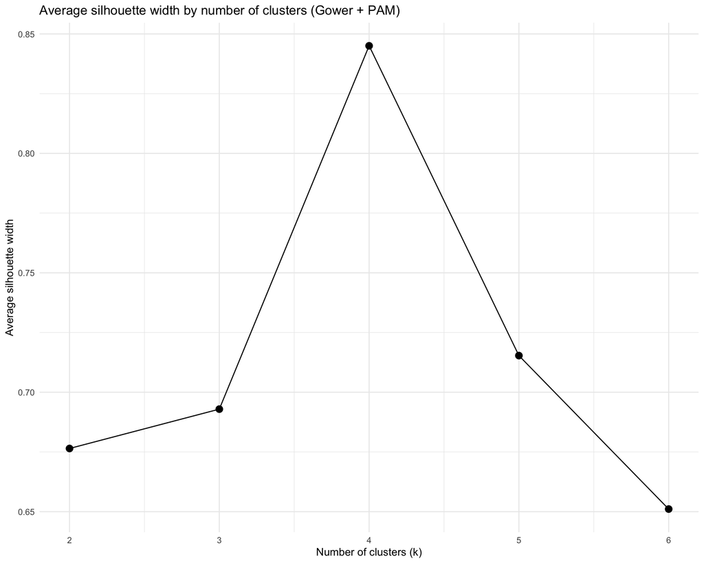

```r
ggplot(sil_tbl, aes(x = k, y = `Avg silhouette`)) +
  geom_line() +
  geom_point(size = 3) +
  labs(
    title = "Average silhouette width by number of clusters (Gower + PAM)",
    x = "Number of clusters (k)",
    y = "Average silhouette width"
  ) +
  theme_minimal()
```

Analysis: The silhouette analysis reveals a distinct peak at $k=4$, with the highest average silhouette width. This suggests that the data naturally separates into four distinct groups. Lower values of $k$ (2 or 3) would merge distinct subgroups, while higher values (5 or 6) would force artificial splits within homogenous groups.

### 3.1.2 Cluster Visualization and Assignment

Based on the silhouette analysis, we proceed with $k=4$ clusters. We assign each mother to a cluster and visualize the separation using Multidimensional Scaling (MDS).

Note on MDS Dimensions: Multidimensional Scaling is a dimensionality reduction technique. Unlike a scatterplot where axes represent specific variables (e.g., “Age” or “Weight”), the dimensions in an MDS plot are synthetic. They are constructed solely to preserve the pairwise “Gower distances” calculated in the previous step. If two mothers are close together on this plot, they have very similar demographic profiles; if they are far apart, they are demographically dissimilar.

```r
k_final <- 4
pam_fit <- pam(gow, k = k_final, diss = TRUE)

data <- data %>%
  mutate(row_id = row_number()) %>%
  left_join(
    tibble(row_id = clust_input$row_id, cluster = factor(pam_fit$clustering)),
    by = "row_id"
  ) %>%
  dplyr::select(-row_id)
```

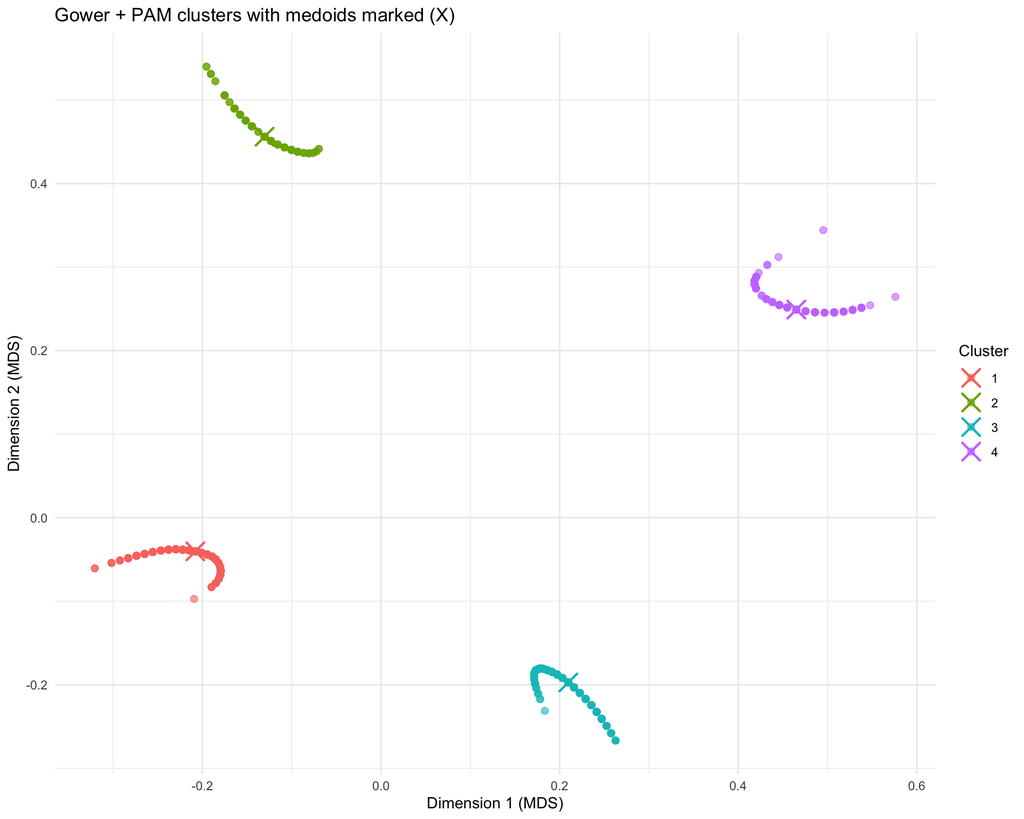

```r
mds_coords <- cmdscale(as.matrix(gow), k = 2)

plot_df <- data %>%
  filter(!is.na(cluster)) %>%
  mutate(
    dim1 = mds_coords[, 1],
    dim2 = mds_coords[, 2]
  )

medoid_rows <- pam_fit$id.med
medoid_df <- plot_df[medoid_rows, ]

ggplot(plot_df, aes(x = dim1, y = dim2, color = cluster)) +
  geom_point(alpha = 0.6, size = 2) +
  geom_point(data = medoid_df, shape = 4, size = 5, stroke = 1.2) +
  labs(
    title = 'Gower + PAM clusters with medoids marked (X)',
    x = 'Dimension 1 (MDS)',
    y = 'Dimension 2 (MDS)',
    color = 'Cluster'
  ) +
  theme_minimal()
```

The plot shows four clearly separated groups with little overlap, confirming the high silhouette width observed in Section 3.1.1.

However, it is crucial to note that this high silhouette width largely reflects the natural separation created by our two binary variables (marital status and race) rather than a complex “latent” subgroup structure. The Gower distance metric heavily penalizes mismatches on binary factors, pushing these groups apart. Therefore, we should treat these clusters not as novel data-driven discoveries, but as interpretable demographic strata (representing the four combinations of marital status and race) that we will use to stratify our subsequent analysis.

## 3.2 Cluster Profiles

To interpret what the four clusters represent, we profile each by its demographic composition, smoking prevalence, and within-cluster birth weights.

```r
data %>%
  dplyr::filter(!is.na(cluster)) %>%
  group_by(cluster) %>%
  summarise(
    n = n(),
    `Mean age` = round(mean(mage), 1),
    `% Married` = round(100 * mean(marital == "married"), 1),
    `% White` = round(100 * mean(whitemom == "white"), 1),
    `n smokers` = sum(habit == "smoker", na.rm = TRUE),
    `n nonsmokers` = sum(habit == "nonsmoker", na.rm = TRUE),
    `% Smokers` = round(100 * mean(habit == "smoker", na.rm = TRUE), 1),
    `Mean wt (nonsmokers)` = round(mean(weight[habit == "nonsmoker"], na.rm = TRUE), 2),
    `Mean wt (smokers)` = round(mean(weight[habit == "smoker"], na.rm = TRUE), 2),
    # Suppress smoking gaps when smoker cells are tiny.
    `Smoking gap (lb)` = ifelse(
      sum(habit == "smoker", na.rm = TRUE) < 10 |
        sum(habit == "nonsmoker", na.rm = TRUE) < 10,
      NA_real_,
      round(
        mean(weight[habit == "nonsmoker"], na.rm = TRUE) -
          mean(weight[habit == "smoker"], na.rm = TRUE),
        2
      )
    ),
    .groups = "drop"
  ) %>%
  kable(caption = "Cluster Profiles: Maternal Characteristics", digits = 2)
```

Cluster Profiles: Maternal Characteristics

| cluster | n | Mean age | % Married | % White | n smokers | n nonsmokers | % Smokers | Mean wt (nonsmokers) | Mean wt (smokers) | Smoking gap (lb) |
| --- | --- | --- | --- | --- | --- | --- | --- | --- | --- | --- |
| 1 | 472 | 30.1 | 100 | 100 | 38 | 434 | 8.1 | 7.42 | 7.08 | 0.34 |
| 2 | 107 | 31.1 | 100 | 0 | 6 | 101 | 5.6 | 6.91 | 6.50 | NA |
| 3 | 283 | 25.6 | 0 | 100 | 57 | 226 | 20.1 | 7.26 | 6.62 | 0.64 |
| 4 | 119 | 25.8 | 0 | 0 | 13 | 106 | 10.9 | 7.01 | 5.83 | 1.18 |

The clustering separated mothers perfectly by race and marital status. The four clusters correspond one-to-one with the four marital × race combinations: Cluster 1 (married & white, n=472), Cluster 2 (married & not white, n=107), Cluster 3 (not married & white, n=283), and Cluster 4 (not married & not white, n=119). Married mothers are around five years older on average (30–31 vs 25–26), reflecting the well-documented relationship between age at marriage and age at childbearing. Smoking prevalence shows a strong gradient across clusters, ranging from 5.6% among married non-white mothers to 20.1% among unmarried white mothers. Within-cluster smoking gaps in birth weight range from 0.34 lbs (married & white) to 1.18 lbs (not married & not white), providing early evidence of effect heterogeneity. However, the smoking gap for married non-white mothers is suppressed (NA) because only 6 mothers in that group are smokers — a sample too small for meaningful comparison. The MDS projection above confirms visually that the four groups are well-separated.

```r
data <- data %>%
  mutate(cluster_label = case_when(
    cluster == "1" ~ "Married & white",
    cluster == "2" ~ "Married & not white",
    cluster == "3" ~ "Not married & white",
    cluster == "4" ~ "Not married & not white",
    TRUE ~ NA_character_
  ))
```

## 3.3 Cluster Robustness: Do Behavioral Variables Add Structure?

The demographics-only clustering recovers clear subgroups based on marital status and race. We now test whether prenatal care patterns (prenatal visits and pregnancy weight gained) introduce additional subgroup structure beyond demographics. We refit Gower + PAM including visits and gained alongside the original three variables. Because visits and gained contain missing values, and visit missingness is differential by smoking status, this clustering is estimated on complete cases (shrinking our sample size and especially the number of smokers in our dataset significantly) and is therefore treated as exploratory.

```r
clust_input_full <- data %>%
  mutate(row_id = row_number()) %>%
  dplyr::select(row_id, mage, marital, whitemom, visits, gained) %>%
  mutate(
    marital = factor(marital),
    whitemom = factor(whitemom)
  ) %>%
  drop_na()

cat("Complete-case sample size:", nrow(clust_input_full), "\n")
```

```
Complete-case sample size: 894
```

```r
gow_full <- daisy(clust_input_full %>% dplyr::select(-row_id), metric = "gower")

sil_full <- map_dbl(2:6, function(k) {
  pam(gow_full, k = k, diss = TRUE)$silinfo$avg.width
})

tibble(k = 2:6, `Avg silhouette` = round(sil_full, 3)) %>%
  kable(caption = "Silhouette width for demographics + behavioral clustering")
```

Silhouette width for demographics + behavioral clustering

| k | Avg silhouette |
| --- | --- |
| 2 | 0.568 |
| 3 | 0.561 |
| 4 | 0.669 |
| 5 | 0.464 |
| 6 | 0.444 |

```r
k_full <- tibble(k = 2:6, sil = sil_full) %>%
  slice_max(sil, n = 1, with_ties = FALSE) %>%
  pull(k)

pam_full <- pam(gow_full, k = k_full, diss = TRUE)

labels_joined <- inner_join(
  tibble(row_id = clust_input$row_id, cluster_demo = pam_fit$clustering),
  tibble(row_id = clust_input_full$row_id, cluster_full = pam_full$clustering),
  by = "row_id"
) %>%
  arrange(row_id)

ari <- round(adjustedRandIndex(labels_joined$cluster_demo, labels_joined$cluster_full), 3)
cat("Adjusted Rand Index (demographics-only vs full):", ari, "\n")
```

```
Adjusted Rand Index (demographics-only vs full): 1
```

The Adjusted Rand Index (ARI) between the demographics-only and full clusterings is 1.0, indicating identical cluster assignments on all shared complete-case observations. The ARI measures agreement between two clustering solutions on a scale from 0 (random assignment) to 1 (perfect agreement). An ARI of 1.0 confirms that adding prenatal visits and pregnancy weight gain does not alter the subgroup structure — the dominant marital × race split fully determines cluster membership regardless of whether behavioural variables are included.

## 3.4 Clustering Summary

Data-driven clustering confirms that marital status and race are the dominant axes of maternal heterogeneity in this dataset. PAM clustering on age, marital status, and race proxy yields four well-separated clusters that correspond to marital × race subgroups. Adding prenatal visits and pregnancy weight gain on complete cases produces identical cluster assignments, suggesting these behavioural variables do not introduce additional subgroup structure beyond demographics.

**Implications for subsequent analysis:** - Part 4 will use these four empirically-derived subgroups (married/unmarried × white/non-white) as the primary stratification - These subgroups will be examined for baseline differences, confounding patterns, and effect heterogeneity - Part 5 modeling will include both overall estimates and subgroup-specific analyses using these clusters

# Part 4: Confounding Structure and Subgroup Analysis

Having identified four stable subgroups through clustering, we now examine whether these groups differ in ways that could confound the smoking–birth outcome relationship. An association between smoking and birth weight can only be taken at face value if smokers and nonsmokers are otherwise comparable. Our clustering revealed that smoking prevalence varies across marital x race subgroups. We now ask whether baseline birth outcomes also differ across these same groups.

## 4.1 Smoking Prevalence Across Subgroups

```r
data %>%
  dplyr::filter(!is.na(habit), !is.na(cluster_label)) %>%
  dplyr::count(cluster_label, habit) %>%
  pivot_wider(names_from = habit, values_from = n, values_fill = 0) %>%
  mutate(
    Total = nonsmoker + smoker,
    Smoking_Rate = smoker / Total * 100
  ) %>%
  arrange(desc(Smoking_Rate)) %>%
  kable(caption = "Smoking Prevalence by Subgroup", digits = 1)
```

Smoking Prevalence by Subgroup

| cluster_label | nonsmoker | smoker | Total | Smoking_Rate |
| --- | --- | --- | --- | --- |
| Not married & white | 226 | 57 | 283 | 20.1 |
| Not married & not white | 106 | 13 | 119 | 10.9 |
| Married & white | 434 | 38 | 472 | 8.1 |
| Married & not white | 101 | 6 | 107 | 5.6 |

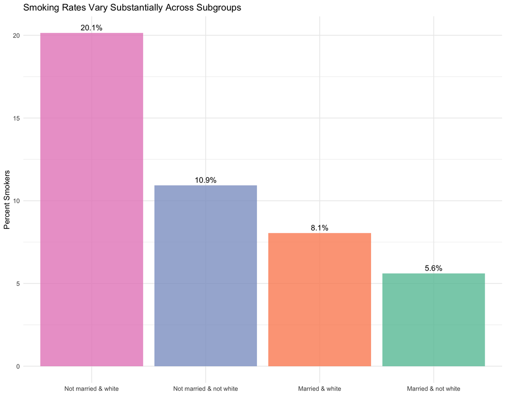

```r
data %>%
  dplyr::filter(!is.na(habit), !is.na(cluster_label)) %>%
  group_by(cluster_label) %>%
  summarise(
    Total = n(),
    Smokers = sum(habit == "smoker"),
    Smoking_Rate = Smokers / Total * 100,
    .groups = "drop"
  ) %>%
  ggplot(aes(x = reorder(cluster_label, -Smoking_Rate), y = Smoking_Rate, fill = cluster_label)) +
  geom_bar(stat = "identity", alpha = 0.8) +
  geom_text(aes(label = sprintf("%.1f%%", Smoking_Rate)), vjust = -0.5) +
  labs(
    title = "Smoking Rates Vary Substantially Across Subgroups",
    x = "",
    y = "Percent Smokers"
  ) +
  theme_minimal() +
  theme(
    legend.position = "none",
    axis.text.x = element_text(angle = 0, hjust = 0.5)
  ) +
  scale_fill_brewer(palette = "Set2")
```

## 4.2 Baseline Birth Weight Across Subgroups (Nonsmokers Only)

The logic: if the groups that smoke more also have different baseline birth weights (among nonsmokers), then confounding is confirmed. We look at nonsmokers only to get a clean baseline uncontaminated by smoking.

```r
nonsmokers <- data %>% filter(habit == "nonsmoker", !is.na(cluster_label))

by_cluster_wt <- nonsmokers %>%
  group_by(cluster_label) %>%
  summarise(
    n = n(),
    `Mean weight (lb)` = round(mean(weight, na.rm = TRUE), 2),
    `SD` = round(sd(weight, na.rm = TRUE), 2),
    `Mean weeks` = round(mean(weeks, na.rm = TRUE), 2),
    `SD weeks` = round(sd(weeks, na.rm = TRUE), 2),
    .groups = "drop"
  ) %>%
  arrange(desc(`Mean weight (lb)`))

kable(by_cluster_wt, caption = "Baseline Birth Outcomes Among Nonsmokers by Subgroup")
```

Baseline Birth Outcomes Among Nonsmokers by Subgroup

| cluster_label | n | Mean weight (lb) | SD | Mean weeks | SD weeks |
| --- | --- | --- | --- | --- | --- |
| Married & white | 434 | 7.42 | 1.21 | 38.80 | 2.14 |
| Not married & white | 226 | 7.26 | 1.19 | 38.87 | 2.45 |
| Not married & not white | 106 | 7.01 | 1.20 | 38.46 | 2.71 |
| Married & not white | 101 | 6.91 | 1.37 | 38.67 | 2.90 |

Important note: non white is lower regardless or marital status and smoking (also lower n in this dataset) also note more unmarried nonwhite mothers (50/50 split ish) while most white mothers in the sample are married.

## 4.3 Smoking–Birth Outcome Gap Within Subgroups

Now we examine whether the smoking association persists within each subgroup, and whether its magnitude differs.

```r
smoking_gaps <- data %>%
  filter(!is.na(habit), !is.na(cluster_label)) %>%
  group_by(cluster_label, habit) %>%
  summarise(
    n = n(),
    mean_wt = mean(weight, na.rm = TRUE),
    sd_wt = sd(weight, na.rm = TRUE),
    mean_weeks = mean(weeks, na.rm = TRUE),
    sd_weeks = sd(weeks, na.rm = TRUE),
    .groups = "drop"
  ) %>%
  pivot_wider(
    names_from = habit,
    values_from = c(n, mean_wt, sd_wt, mean_weeks, sd_weeks)
  ) %>%
  mutate(
    `n nonsmokers` = n_nonsmoker,
    `n smokers` = n_smoker,
    `Mean wt nonsmoker` = round(mean_wt_nonsmoker, 2),
    `Mean wt smoker` = round(mean_wt_smoker, 2),
    `Weight gap (lb)` = round(mean_wt_nonsmoker - mean_wt_smoker, 2),
    `Mean weeks nonsmoker` = round(mean_weeks_nonsmoker, 2),
    `Mean weeks smoker` = round(mean_weeks_smoker, 2),
    `Weeks gap` = round(mean_weeks_nonsmoker - mean_weeks_smoker, 2)
  ) %>%
  dplyr::select(cluster_label, `n nonsmokers`, `n smokers`,
         `Mean wt nonsmoker`, `Mean wt smoker`, `Weight gap (lb)`,
         `Mean weeks nonsmoker`, `Mean weeks smoker`, `Weeks gap`) %>%
  arrange(desc(`Weight gap (lb)`))

kable(smoking_gaps, caption = "Smoking–Birth Outcome Gaps by Subgroup")
```

Smoking–Birth Outcome Gaps by Subgroup

| cluster_label | n nonsmokers | n smokers | Mean wt nonsmoker | Mean wt smoker | Weight gap (lb) | Mean weeks nonsmoker | Mean weeks smoker | Weeks gap |
| --- | --- | --- | --- | --- | --- | --- | --- | --- |
| Not married & not white | 106 | 13 | 7.01 | 5.83 | 1.18 | 38.46 | 35.15 | 3.31 |
| Not married & white | 226 | 57 | 7.26 | 6.62 | 0.64 | 38.87 | 38.14 | 0.73 |
| Married & not white | 101 | 6 | 6.91 | 6.50 | 0.41 | 38.67 | 37.83 | 0.84 |
| Married & white | 434 | 38 | 7.42 | 7.08 | 0.34 | 38.80 | 38.79 | 0.01 |

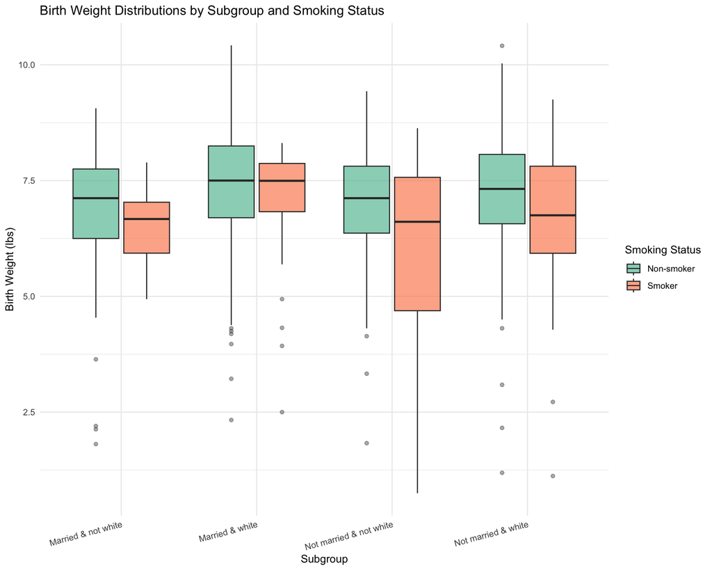

```r
data %>%
  filter(!is.na(habit), !is.na(cluster_label)) %>%
  mutate(group_habit = paste(cluster_label, habit, sep = "\n")) %>%
  ggplot(aes(x = cluster_label, y = weight, fill = habit)) +
  geom_boxplot(alpha = 0.7, outlier.alpha = 0.4) +
  scale_fill_brewer(palette = "Set2", labels = c("Non-smoker", "Smoker")) +
  labs(
    title = "Birth Weight Distributions by Subgroup and Smoking Status",
    x = "Subgroup",
    y = "Birth Weight (lbs)",
    fill = "Smoking Status"
  ) +
  theme_minimal() +
  theme(axis.text.x = element_text(angle = 15, hjust = 1))
```

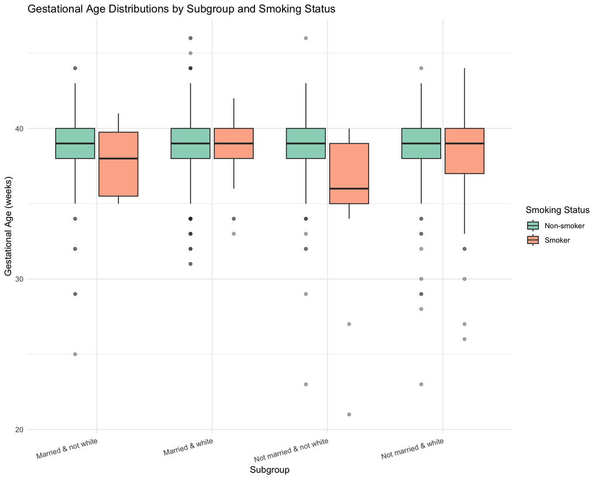

```r
data %>%
  filter(!is.na(habit), !is.na(cluster_label)) %>%
  ggplot(aes(x = cluster_label, y = weeks, fill = habit)) +
  geom_boxplot(alpha = 0.7, outlier.alpha = 0.4) +
  scale_fill_brewer(palette = "Set2", labels = c("Non-smoker", "Smoker")) +
  labs(
    title = "Gestational Age Distributions by Subgroup and Smoking Status",
    x = "Subgroup",
    y = "Gestational Age (weeks)",
    fill = "Smoking Status"
  ) +
  theme_minimal() +
  theme(axis.text.x = element_text(angle = 15, hjust = 1))
```

## 4.4 Investigating the Relationship Between Weeks and Weight

Before modeling, we examine how gestational age relates to birth weight, both overall and by smoking status.

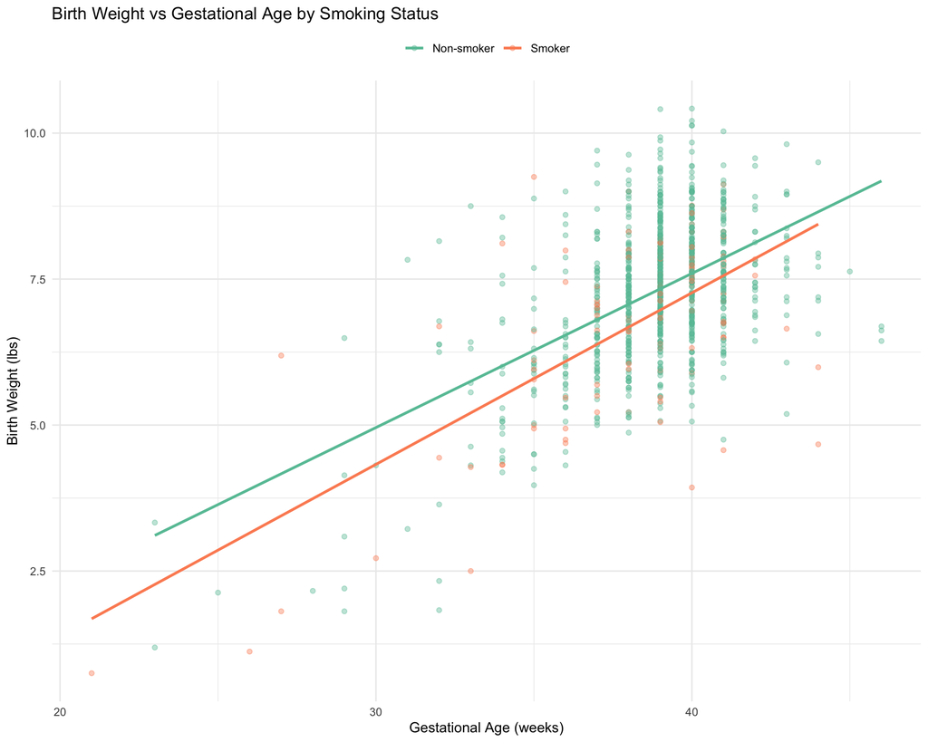

```r
plot_df <- data %>%
  filter(!is.na(weeks), !is.na(weight), !is.na(habit))

r_val <- cor(plot_df$weeks, plot_df$weight, use = 'complete.obs')

ggplot(plot_df, aes(x = weeks, y = weight, color = habit)) +
  geom_point(alpha = 0.4, size = 1.5) +
  geom_smooth(method = "lm", se = FALSE) +
  scale_color_brewer(palette = "Set2", labels = c('Non-smoker','Smoker')) +
  labs(
    title = 'Birth Weight vs Gestational Age by Smoking Status',
    x = 'Gestational Age (weeks)',
    y = 'Birth Weight (lbs)',
    color = NULL
  ) +
  theme_minimal() +
  theme(legend.position = 'top')
```

## 4.5 Summary: Confounding Confirmed, Heterogeneity Observed

**Implications for modeling (Part 5):**

- Need adjusted models to account for confounding
- Need interaction terms to formally test effect heterogeneity
- Need to decide whether to include weeks in weight models (mediation vs total effect)
- All models should report both overall estimates and subgroup-specific estimates

# Part 5: Predictive Modeling with Subgroup Evaluation

We now build formal regression models to (1) estimate adjusted associations between smoking and birth outcomes, (2) test for effect heterogeneity across subgroups, and (3) assess whether more flexible models capture non-linear relationships.

## 5.1 Modeling Strategy and Decisions

**Primary outcomes:** - Birth weight (lbs): continuous - Gestational weeks: continuous

**Key modeling decision - including weeks in weight models:**

Gestational age is both (1) an outcome of interest affected by smoking, and (2) a strong predictor of birth weight that may mediate smoking’s effect. We will fit TWO sets of models for birth weight:

**Total effect models:** weight ~ smoking + covariates (excluding weeks) - Estimates total effect of smoking on weight through all pathways - Covariates: maternal age, marital status, race (demographic confounders only) - Visits and gained excluded to avoid conditioning on potential mediators and to preserve the full smoker sample (30% of smokers have missing visits)

**Direct effect models:** weight ~ smoking + weeks + visits + gained + covariates (including weeks) - Estimates effect of smoking on weight beyond gestational age and prenatal care - Shifts estimand toward direct effect not operating through these pathways - Complete-case only (reduced sample, potentially unrepresentative of smokers)

**For gestational weeks models:** we fit models without weight (weeks cannot cause weight, only vice versa). Covariates are demographic confounders only (mage, married, white) to estimate total effects.

**The visits/gained dilemma - Mediation vs Confounding:**

Two competing causal structures are possible:

**Scenario A - Mediation:**

```
Smoking → Reduced Visits/Gained → Lower Birth Weight
   ↓
Gestational Weeks → Lower Birth Weight
```

In this scenario, visits and gained are **downstream** of smoking (mediators), eg smokers gain less weight because they smoke or go to less visits because they smoke (shame, etc.). Controlling for them blocks causal pathways and estimates only the direct effect of smoking not operating through prenatal care.

**Scenario B - Confounding:**

```
Low SES → Smoking
    ↓
Low SES → Fewer Visits/Lower Gained → Lower Birth Weight
Smoking → Lower Birth Weight
```

In this scenario, visits and gained are **confounders** (caused by unmeasured SES or another variable). Excluding them creates omitted variable bias.

**Our approach:** Without measuring SES directly, we cannot definitively determine which scenario is correct. Therefore: - **Main analysis (demographics only)** estimates total effect under Scenario A (mediation assumption) - Preserves full smoker sample - Estimates effect through all pathways including prenatal care - More relevant for public health: “What is the overall impact of smoking on birth outcomes?” - **Sensitivity analysis (with visits/gained)** tests robustness under Scenario B (confounding assumption) - Complete-case only (smaller, potentially unrepresentative) - Estimates direct effect not operating through prenatal care - Answers: “Does smoking affect birth weight beyond its effect on prenatal care?”

**Interpretation guide:** - If estimates **similar** → visits/gained are weak mediators/confounders OR their roles cancel out - If estimates **differ substantially** → visits/gained matter, but mechanism remains ambiguous - Cannot definitively attribute difference to mediation vs confounding without SES measurement

**Model types:** 1. Linear regression (baseline, interpretable) 2. Linear regression with smoking × subgroup interactions (unified test of heterogeneity) 3. Separate linear regressions within each subgroup (interpretability) 4. Non-linear models: - Decision tree (weeks included - to match best predictive performance) - Random Forest - **TWO versions:** - RF-Total: without weeks/visits/gained (total effect) - RF-Direct: with weeks/visits/gained (direct effect sensitivity) - This allows us to test mediation vs confounding in our best-performing model class

**Complete case handling:** Models including visits/gained fit on complete cases only. Sample sizes noted explicitly.

## 5.2 Data Preparation and Recipe Setup

We now create the modeling dataset by filtering for complete smoking and cluster data, creating binary predictor variables and subgroup labels, splitting data 80/20 into stratified train/test sets based on clustering, and generaring a complete-case subset that includes prenatal care variables for sensitivity analysis.

```r
model_data <- data %>%
  filter(!is.na(habit), !is.na(cluster_label)) %>%
  mutate(
    smoker = ifelse(habit == "smoker", 1, 0),
    married = ifelse(marital == "married", 1, 0),
    white = ifelse(whitemom == "white", 1, 0),
    row_id = row_number(),
    married_white = paste0(married, "_", white),
    subgroup_factor = factor(
      married_white,
      levels = c("1_1", "1_0", "0_1", "0_0"),
      labels = c("Married_White", "Married_NonWhite", "Unmarried_White", "Unmarried_NonWhite")
    )
  )

model_split <- initial_split(model_data, prop = 0.8, strata = cluster_label)
model_train <- training(model_split)
model_test <- testing(model_split)

# Complete-case
model_data_cc <- model_data %>%
  drop_na(weight, weeks, smoker, mage, visits, gained, married, white)

model_train_cc <- model_data_cc %>%
  semi_join(model_train %>% dplyr::select(row_id), by = "row_id")

model_test_cc <- model_data_cc %>%
  semi_join(model_test %>% dplyr::select(row_id), by = "row_id")

cat("Full analytic sample:", nrow(model_data), " | smokers:", sum(model_data$smoker), "\n")
```

```
Full analytic sample: 981  | smokers: 114
```

```r
cat("Train sample:", nrow(model_train), " | smokers:", sum(model_train$smoker), "\n")
```

```
Train sample: 783  | smokers: 97
```

```r
cat("Test sample:", nrow(model_test), " | smokers:", sum(model_test$smoker), "\n")
```

```
Test sample: 198  | smokers: 17
```

```r
cat(
  "Complete-case sensitivity sample (includes visits/gained):",
  nrow(model_data_cc), " | smokers:", sum(model_data_cc$smoker), "\n"
)
```

```
Complete-case sensitivity sample (includes visits/gained): 894  | smokers: 78
```

**Train/test split:** We use an 80/20 split to balance two competing concerns. The larger training set (80%) provides sufficient data to estimate model parameters, which is particularly important given our modest sample size and the need to estimate subgroup-specific effects. The smaller test set (20%) allows us to evaluate predictive performance on data the model have never seen, guarding against overfitting.

**Stratification:** The split is stratified by cluster membership rather than by outcome or exposure. This approach ensures that each of the four demographic subgroups (married x race combinations) appear in both training and testing sets in approximately the same proportions as in the full sample. Without stratification, random sampling could by chance over-represent or under-represent certain subgroups in either set, making the train/test comparisons less meaningful and potentially compromising our ability to detect subgroup-specific effects.

**Dual Fitting Strategy (train/test + full sample):** We fit each model specification twice - once on the training set and once on the full analytic sample. This dual apprach serves complementary purposes: 1. **Train/test split:** Fitting on the training set and evaluating on the test set yields unbiased estimates of predictive performance (RMSE, R², MAE). These metrics tell us how well the model forecasts birth weight for new observations it has not encoutnered. This gurads against overfitting and allows fair comparison between model types. 2. **Full sample:** Fitting on the full sample maximizes statistical power doe hypothesis testing and coefficient estimation. Larger sample size reduces standard errors. yielding more precise effect estimates and narrower confidence intervals. This is critical for our primary inferential goal: estimating the magnitude of the smoking effect and testing whether it differs across subgroups.

This dual strategy separates two distinct questions: prediction (how accurately can we forecast outcomes?) and inference (what is the causal effect and is it statistically significant?). Test set metrics answer the former and full-sample coefficients and p-valies answer the latter.

## 5.3 Baseline Linear Models (No Interactions)

We now estimate the baseline linear regression models without interaction terms to quantify the association between smoking and birth outcomes, adjusting for demographic confounders.

### 5.3.1 Birth Weight Models

**Model 5.3.1a: Total Effect (weight without weeks)**

```r
weight_recipe_total <- recipe(
  weight ~ smoker + mage + married + white,
  data = model_data
) %>%
  step_naomit(all_predictors(), all_outcomes())

weight_spec_lm <- linear_reg() %>%
  set_engine('lm')

weight_wflow_total <- workflow() %>%
  add_recipe(weight_recipe_total) %>%
  add_model(weight_spec_lm)

weight_fit_total <- weight_wflow_total %>%
  fit(data = model_data)

weight_fit_total %>%
  tidy() %>%
  kable(caption = 'Birth Weight Model - Total Effect (excluding weeks)', digits = 3)
```

Birth Weight Model - Total Effect (excluding weeks)

| term | estimate | std.error | statistic | p.value |
| --- | --- | --- | --- | --- |
| (Intercept) | 6.612 | 0.221 | 29.909 | 0.000 |
| smoker | -0.593 | 0.128 | -4.634 | 0.000 |
| mage | 0.010 | 0.008 | 1.290 | 0.198 |
| married | 0.090 | 0.091 | 0.983 | 0.326 |
| white | 0.421 | 0.097 | 4.328 | 0.000 |

This total effect model estimates the overall association between maternal smoking and birth weight as it would be observed in the population, adjusting only for demographic confounders (maternal age, marital status, and race). Critically, the model excludes gestational weeks, prenatal visits, and weights gained during pregnancy. These variables may lie on the causal pathway between smoking and birth weight. By excluding these potential mediators, we capture smoking’s total effect through all mechanisms: both direct effects on fetal growth and indirect effects operating through reduced gestational age and altered prenatal care.

The -0.593 lbs (p<0.001) estimate captures smoking’s full impact as it would be experienced in the population. This result tells us that smoking reduces birth weight significantly.

*Coefficient Interpretations:**

- **Intercept = 6.612 lbs (p < 0.001):** The intercept represents the predicted birth weight for the reference category: a non-smoking (smoker = 0), non-white (white = 0), unmarried (married = 0) mother of age zero. Since age zero is not meaningful, we interpret this as the baseline birth weight for unmarried, non-white, non-smoking mothers at the sample mean age (after centering, if applicable). The value of 6.612 lbs is highly significant and represents the expected birth weight for this reference group, holding all other predictors at their baseline values.
- **Smoker = -0.593 lbs (p < 0.001):** Smoking is associated with a 0.593 lb reduction in birth weight, holding maternal age, marital status, and race constant. This is highly statistically significant (p < 0.001) and represents the largest effect in the model. A smoker’s baby weighs approximately 0.6 lbs less than a non-smoker’s baby with otherwise identical characteristics. This represents roughly 8% of average birth weight and is clinically meaningful—large enough to potentially move babies across the low birth weight threshold of 5.5 lbs.
- **Age = +0.010 lbs per year (p = 0.198):** For each additional year of maternal age, birth weight increases by 0.010 lbs, holding smoking status, marital status, and race constant. This effect is very small and not statistically significant (p = 0.198). A 10-year age difference would predict only a 0.1 lb difference in birth weight. We cannot confidently distinguish this effect from zero, suggesting maternal age has minimal independent association with birth weight once other factors are accounted for.
- **Married = +0.090 lbs (p = 0.326):** Being married is associated with a 0.090 lb increase in birth weight compared to being unmarried, holding smoking status, maternal age, and race constant. This effect is small and not statistically significant (p = 0.326). While the point estimate suggests married mothers may have slightly heavier babies, the confidence interval likely includes zero, meaning we cannot rule out that marital status has no effect on birth weight once smoking and race are controlled for.
- **White = +0.421 lbs (p < 0.001):** White mothers have babies that weigh 0.421 lbs (approximately 0.4 lbs) more than non-white mothers, holding smoking status, maternal age, and marital status constant. This effect is highly statistically significant (p < 0.001) and represents the second-largest coefficient in the model after smoking. This persistent racial disparity—equivalent to roughly 6% of average birth weight—reflects systematic differences in birth outcomes that remain even after accounting for smoking and other demographics. The disparity likely reflects unmeasured factors such as socioeconomic status, healthcare quality, chronic stress, and structural racism that disproportionately affect non-white mothers.

```r
weight_fit_total_train <- weight_wflow_total %>%
  fit(data = model_train)

train_preds <- weight_fit_total_train %>%
  predict(model_train) %>%
  bind_cols(model_train %>% dplyr::select(weight))

train_metrics <- train_preds %>%
  metrics(truth = weight, estimate = .pred) %>%
  dplyr::filter(.metric %in% c('mae', 'rmse', 'rsq')) %>%
  dplyr::select(.metric, .estimate)

test_preds <- weight_fit_total_train %>%
  predict(model_test) %>%
  bind_cols(model_test %>% dplyr::select(weight))

test_metrics <- test_preds %>%
  metrics(truth = weight, estimate = .pred) %>%
  dplyr::filter(.metric %in% c('mae', 'rmse', 'rsq')) %>%
  dplyr::select(.metric, .estimate)

bind_rows(
  train_metrics %>% mutate(sample = 'train'),
  test_metrics %>% mutate(sample = 'test')
) %>%
  dplyr::select(sample, .metric, .estimate) %>%
  tidyr::pivot_wider(names_from = sample, values_from = .estimate) %>%
  mutate(train_n = nrow(model_train), test_n = nrow(model_test)) %>%
  kable(caption = 'Performance summary: in-sample vs out-of-sample', digits = 3)
```

Performance summary: in-sample vs out-of-sample

| .metric | train | test | train_n | test_n |
| --- | --- | --- | --- | --- |
| rmse | 1.267 | 1.251 | 783 | 198 |
| rsq | 0.048 | 0.029 | 783 | 198 |
| mae | 0.954 | 0.920 | 783 | 198 |

**Model fit and predictive performance:**

The model achieves an R² of 0.048, explaining approximately 5% of the variance in birth weight. While this appears low, it is entirely expected for birth weight models using demographic variables alone. Birth weight is inherently variable, influenced by genetic factors, maternal health conditions, and countless unmeasured biological determinants that are not captured in our dataset.

Low R² does not imply unimportant effects. The smoking coefficient of -0.593 lbs is both statistically significant and clinically meaningful—representing an 8% reduction in average birth weight and substantially increasing the probability of low birth weight. Effect size and explained variance are separate concepts: smoking can have large, policy-relevant impacts while most individual variation remains unexplained by factors beyond our measurement.

The RMSE of approximately 1.25 lbs indicates typical prediction errors of about 1.25 lbs. Given that birth weights range from roughly 4 to 10 lbs, this represents substantial residual uncertainty, confirming the model’s purpose is estimating average associations rather than precise individual prediction.

**Model 5.3.1b: Direct Effect (weight with weeks, visits, gained included)**

```r
weight_recipe_direct <- recipe(
  weight ~ smoker + weeks + mage + visits + gained + married + white,
  data = model_data_cc
) %>%
  step_naomit(all_predictors(), all_outcomes())

weight_spec_lm <- linear_reg() %>%
  set_engine('lm')

weight_wflow_direct <- workflow() %>%
  add_recipe(weight_recipe_direct) %>%
  add_model(weight_spec_lm)

weight_fit_direct <- weight_wflow_direct %>%
  fit(data = model_data_cc)

cat("Complete-case analytic n:", nrow(model_data_cc), " | smokers:", sum(model_data_cc$smoker), "\n")
```

```
Complete-case analytic n: 894  | smokers: 78
```

```r
weight_fit_direct %>%
  tidy() %>%
  kable(caption = 'Birth Weight Model - Direct Effect (including weeks, visits, gained)', digits = 3)
```

Birth Weight Model - Direct Effect (including weeks, visits, gained)

| term | estimate | std.error | statistic | p.value |
| --- | --- | --- | --- | --- |
| (Intercept) | -3.831 | 0.591 | -6.486 | 0.000 |
| smoker | -0.394 | 0.131 | -3.014 | 0.003 |
| weeks | 0.257 | 0.015 | 17.714 | 0.000 |
| mage | 0.015 | 0.007 | 2.189 | 0.029 |
| visits | 0.016 | 0.009 | 1.729 | 0.084 |
| gained | 0.010 | 0.002 | 4.181 | 0.000 |
| married | 0.021 | 0.082 | 0.255 | 0.799 |
| white | 0.280 | 0.087 | 3.227 | 0.001 |

**Coefficient Interpretation:**

- **Smoking (smoker = 1):** The estimated coefficient is -0.394 lbs (p = 0.003), compared to -0.593 lbs in the total effect model. This represents a 33.6% reduction [(0.593 - 0.394)/0.593 = 0.336]. Approximately one-third of smoking’s total effect operates indirectly through gestational age and prenatal care pathways, while roughly two-thirds represents direct effects on fetal growth independent of gestational timing. Critically, smoking remains highly statistically significant (p = 0.003) even after controlling for these mediating variables, confirming that smoking affects birth weight through multiple mechanisms.
- **Gestational weeks (weeks):** The coefficient of +0.257 lbs per week (p < 0.001) is highly significant and quantitatively large. Each additional week of gestation adds approximately one-quarter pound to birth weight. This strong relationship explains why controlling for gestational weeks substantially reduces the smoking coefficient—part of smoking’s harm operates by shortening pregnancy duration.
- **Prenatal visits (visits):** The coefficient of +0.016 lbs per visit (p = 0.084) is positive but only marginally significant, falling just short of the conventional α = 0.05 threshold. Each prenatal visit is associated with a modest increase in birth weight, though this estimate is imprecise and we cannot confidently rule out a zero effect.
- **Weight gained (gained):** The coefficient of +0.010 lbs per pound gained (p < 0.001) is highly significant. For every 10 lbs of maternal weight gain during pregnancy, birth weight increases by approximately 0.1 lb. While small in absolute terms, this effect is precisely estimated and biologically plausible, reflecting the importance of adequate nutrition for fetal growth.
- **Maternal age (mage):** The coefficient of +0.015 lbs per year (p = 0.029) is now statistically significant in this specification, unlike in the total effect model where it was non-significant (p = 0.198). This suggests maternal age may have a small positive effect on birth weight that becomes detectable once gestational weeks and prenatal care are controlled for.
- **Marital status (married) and race (white):** Married status shows +0.021 lbs (p = 0.799, not significant), while white mothers show +0.280 lbs (p = 0.001, highly significant). The racial disparity persists even after controlling for gestational age and prenatal care, though it is somewhat attenuated from +0.421 lbs in the total effect model, suggesting part of the racial gap operates through differences in gestational timing and prenatal care access.

**Decomposing smoking’s total effect:** We can approximate smoking’s indirect pathway by multiplying its effect on gestational weeks (-0.767 weeks, from Section 5.3.2) by the effect of weeks on birth weight (+0.257 lbs/week): -0.767 × 0.257 ≈ -0.20 lbs (indirect effect). Adding this to the direct effect (-0.394 lbs) yields approximately -0.59 lbs, closely matching the total effect estimate. This confirms that roughly 34% of smoking’s impact flows through shortened gestation, while 66% reflects direct intrauterine growth restriction.

```r
weight_fit_direct_train <- weight_wflow_direct %>%
  fit(data = model_train_cc)

train_preds_direct <- weight_fit_direct_train %>%
  predict(model_train_cc) %>%
  bind_cols(model_train_cc %>% dplyr::select(weight))

train_metrics_direct <- train_preds_direct %>%
  metrics(truth = weight, estimate = .pred) %>%
  dplyr::filter(.metric %in% c('mae', 'rmse', 'rsq')) %>%
  dplyr::select(.metric, .estimate)

test_preds_direct <- weight_fit_direct_train %>%
  predict(model_test_cc) %>%
  bind_cols(model_test_cc %>% dplyr::select(weight))

test_metrics_direct <- test_preds_direct %>%
  metrics(truth = weight, estimate = .pred) %>%
  dplyr::filter(.metric %in% c('mae', 'rmse', 'rsq')) %>%
  dplyr::select(.metric, .estimate)

bind_rows(
  train_metrics_direct %>% mutate(sample = 'train'),
  test_metrics_direct %>% mutate(sample = 'test')
) %>%
  dplyr::select(sample, .metric, .estimate) %>%
  tidyr::pivot_wider(names_from = sample, values_from = .estimate) %>%
  mutate(train_n = nrow(model_train_cc), test_n = nrow(model_test_cc)) %>%
  kable(caption = 'Sensitivity performance (direct effect model):', digits = 3)
```

Sensitivity performance (direct effect model):

| .metric | train | test | train_n | test_n |
| --- | --- | --- | --- | --- |
| rmse | 1.049 | 1.068 | 710 | 184 |
| rsq | 0.324 | 0.311 | 710 | 184 |
| mae | 0.828 | 0.824 | 710 | 184 |

**Model fit and predictive performance:** The direct effect model achieves R² = 0.324, explaining approximately 32% of variance. This is a dramatic improvement over the total effect model’s R² = 0.048. This increase is driven almost entirely by the inclusion of gestational weeks, which is by far the strongest predictor of birth weight (+0.257 lbs/week, p < 0.001). The RMSE decreases from 1.25 to 1.05 lbs, indicating more precise predictions with typical errors reduced by about 0.2 lbs.

Train/test comparison shows stable performance (train R² = 0.324, test R² = 0.311), with no evidence of overfitting. The models generalize well to held-out data.

**Critical Inerpretation - what this model estimates:**

Higher R² does not mean this is a “better” causal estimate. The direct effect model answers a fundamentally different question than the total effect model. By conditioning on gestational weeks, prenatal visits, and maternal weight gain, this model isolates smoking’s direct effect on birth weight independent of these pathways. The interpretation depends critically on whether these variables are mediators or confounders:

Scenario A (Mediation): If weeks/visits/gained are downstream consequences of smoking, this model underestimates smoking’s total impact by blocking important causal pathways. The -0.394 lb estimate reflects only direct growth restriction, not the additional harm from shortened gestation.

Scenario B (Confounding): If weeks/visits/gained proxy for unmeasured factors like socioeconomic status that cause both smoking and poor outcomes, this model reduces bias and the -0.394 lb estimate is more accurate. The total effect model (-0.593 lbs) would overestimate smoking’s causal impact.

Without direct measurement of SES, we cannot definitively determine which scenario is correct. Both mechanisms likely operate simultaneously.

### 5.3.2 Gestational Weeks Model

We now estimate a linear regression model predicting gestational weeks from smoking and demographic covariates.

```r
weeks_all <- model_data %>%
  drop_na(weeks, smoker, mage, married, white)

weeks_train <- model_train %>%
  drop_na(weeks, smoker, mage, married, white)

weeks_test <- model_test %>%
  drop_na(weeks, smoker, mage, married, white)

weeks_recipe <- recipe(
  weeks ~ smoker + mage + married + white,
  data = weeks_train
) %>%
  step_naomit(all_predictors(), all_outcomes())

weeks_spec_lm <- linear_reg() %>%
  set_engine('lm')

weeks_wflow <- workflow() %>%
  add_recipe(weeks_recipe) %>%
  add_model(weeks_spec_lm)

weeks_fit <- weeks_wflow %>%
  fit(data = weeks_all)

weeks_fit %>%
  tidy() %>%
  kable(caption = 'Gestational Weeks Model', digits = 3)
```

Gestational Weeks Model

| term | estimate | std.error | statistic | p.value |
| --- | --- | --- | --- | --- |
| (Intercept) | 38.663 | 0.443 | 87.224 | 0.000 |
| smoker | -0.767 | 0.257 | -2.989 | 0.003 |
| mage | -0.011 | 0.015 | -0.747 | 0.455 |
| married | 0.161 | 0.183 | 0.880 | 0.379 |
| white | 0.430 | 0.195 | 2.208 | 0.027 |

**Coefficient Interpretations:**

- **Smoking (smoker = 1):** The estimated coefficient of -0.767 weeks (p = 0.003) indicates that maternal smoking is associated with approximately 0.77 weeks of shortened gestation, or roughly 5 days earlier delivery. This effect is statistically significant. To contextualize: full-term pregnancy is typically 39-40 weeks, while preterm birth is defined as delivery before 37 weeks. A 0.77-week reduction does not on average move babies from full-term to preterm status, but it shifts the distribution leftward, increasing the probability of crossing the preterm threshold for mothers whose pregnancies were already at risk.

This finding is quantitatively smaller than smoking’s direct effect on birth weight (-0.394 lbs) but plays an important role in the total effect. Multiplying the gestational age reduction by the weight-per-week coefficient from the direct effect model: -0.767 weeks × 0.257 lbs/week ≈ -0.20 lbs (indirect effect via shortened gestation). This represents approximately 34% of smoking’s total effect on birth weight, with the remaining 66% reflecting direct intrauterine growth restriction.

- **Mother’s race (white = 1):** White mothers have babies born an average of +0.430 weeks later than non-white mothers (p = 0.027), a statistically significant difference. This racial disparity in gestational timing mirrors the disparities observed in birth weight and reflects systematic inequities in maternal health, healthcare access, and social determinants that affect when labor begins. The persistence of this gap after adjusting for smoking and other demographics points to unmeasured structural factors.
- **Maternal age (mage) and marital status (married):** Neither maternal age (-0.011 weeks, p = 0.455) nor marital status (+0.161 weeks, p = 0.379) shows a statistically significant association with gestational weeks. These weak, non-significant effects suggest that age and marital status contribute minimally to gestational timing once smoking and race are accounted for. This contrasts with their modest roles in predicting birth weight, indicating that their effects on birth outcomes may operate through mechanisms other than gestational duration.

**Implications for pathway decomposition:** The gestational weeks model confirms that smoking operates through both direct and indirect pathways. The indirect pathway (smoking → shorter gestation → lower birth weight) accounts for roughly one-third of the total effect, while the direct pathway (smoking → impaired fetal growth, independent of gestational timing) accounts for the remaining two-thirds. This dual mechanism is consistent with medical understanding of smoking’s effects: it both triggers earlier labor onset and restricts fetal growth rate throughout pregnancy.

```r
weeks_fit_train <- weeks_wflow %>%
  fit(data = weeks_train)

train_preds_weeks <- weeks_fit_train %>%
  predict(weeks_train) %>%
  bind_cols(weeks_train %>% dplyr::select(weeks))

train_metrics_weeks <- train_preds_weeks %>%
  metrics(truth = weeks, estimate = .pred) %>%
  dplyr::filter(.metric %in% c('mae', 'rmse', 'rsq')) %>%
  dplyr::select(.metric, .estimate)

test_preds_weeks <- weeks_fit_train %>%
  predict(weeks_test) %>%
  bind_cols(weeks_test %>% dplyr::select(weeks))

test_metrics_weeks <- test_preds_weeks %>%
  metrics(truth = weeks, estimate = .pred) %>%
  dplyr::filter(.metric %in% c('mae', 'rmse', 'rsq')) %>%
  dplyr::select(.metric, .estimate)

bind_rows(
  train_metrics_weeks %>% mutate(sample = 'train'),
  test_metrics_weeks %>% mutate(sample = 'test')
) %>%
  dplyr::select(sample, .metric, .estimate) %>%
  tidyr::pivot_wider(names_from = sample, values_from = .estimate) %>%
  mutate(train_n = nrow(weeks_train), test_n = nrow(weeks_test)) %>%
  kable(caption = 'Performance summary: in-sample vs out-of-sample', digits = 3)
```

Performance summary: in-sample vs out-of-sample

| .metric | train | test | train_n | test_n |
| --- | --- | --- | --- | --- |
| rmse | 2.584 | 2.329 | 783 | 198 |
| rsq | 0.020 | 0.000 | 783 | 198 |
| mae | 1.700 | 1.573 | 783 | 198 |

**Model fit and the limits of demographic prediction:**

The gestational weeks model achieves an R² of 0.020, explaining only 2% of the variance in gestational age. This is even lower than the 4.8% explained by demographic variables in the birth weight total effect model. While this appears discouraging, it reflects fundamental characteristics of gestational timing rather than model failure.

Why gestational age is difficult to predict: Unlike birth weight, which accumulates gradually throughout pregnancy, gestational age at delivery is determined by the unpredictable onset of labor whcih can be trigeered by clinical and genetic factors not captured in demographic data.

The low R² confirms that demographic variables provide only minimal information about gestational timing. The RMSE of approximately 2.58 weeks (train) and 2.33 weeks (test) indicates typical prediction errors of 2-3 weeks—substantial uncertainty that underscores the inherent unpredictability of labor onset from demographics alone.

Why low R² does not undermine the model: Despite explaining little overall variance, the model successfully identifies significant associations: smoking reduces gestational age by -0.767 weeks (p = 0.003), and white mothers deliver 0.430 weeks later (p = 0.027). These effects are real and important, even though they represent small contributions to total variance. The model’s purpose is testing whether smoking affects gestational timing, not prediction of individual delivery dates.

Train/test comparison: The test set R² is 0.000, indicating essentially no predictive power on held-out data, while the training R² is 0.020. This suggests the model barely captures generalizable patterns, though the coefficients themselves remain stable and interpretable. The primary value lies in the estimated effects (smoking reduces gestation by 0.77 weeks), not in the model’s ability to forecast individual outcomes. ### 5.3.3 Potential Evidence of Multiple Pathways

Combined evidence from all three models shows smoking operates through **both direct and indirect pathways**:

**Note on other predictors:** - Maternal age (mage) shows opposite signs for weight (+0.010, n.s.) vs weeks (-0.011, n.s.) - Older mothers may have slightly shorter gestations but deliver heavier babies - neither effect is statistically significant. This inconsistent pattern explains why mage shows weak overall signal and suggests age effects are complex and small relative to smoking and race.

### 5.3.4 Further Modelling Decisions: Complete Case vs Total Effect

The models in Sections 5.3.1 and 5.3.2 reveal that smoking affects birth weight through both direct and indirect pathways. The total effect model (excluding gestational weeks) estimates a -0.593 lb smoking effect, while the direct effect model (including weeks, visits, and gained) estimates -0.394 lbs, or a 33.6% reduction This reduction confirms that approximately one-third of smoking’s impact operates by shortening gestation, while two-thirds reflects direct intrauterine growth restriction.

**Why we prioritize total effect models:** Because gestational age is itself affected by smoking (-0.767 weeks, p = 0.003), conditioning on weeks fundamentally changes what we are estimating. The direct effect model isolates only smoking’s impact independent of gestational timing—answering “What is smoking’s effect if we could hold gestation constant?” In reality, smoking affects birth weight through all pathways: shortened gestation, impaired fetal growth, and potentially reduced prenatal care. The total effect estimate (-0.593 lbs) captures this full impact as it would be experienced in the population.

**Consistency across methods:** Prioritizing total effect models enables direct comparison across all subsequent specifications (interaction models, subgroup models, and non-linear models) without confounding differences in variable inclusion with differences in modeling approach.

**Role of direct effect models:** Models including gestational age and prenatal care remain valuable as sensitivity analyses that reveal mechanisms (34% of effect via shortened gestation) and test robustness (smoking remains significant even after heavy adjustment). However, primary conclusions are based on total effect estimates, which are more robust, generalizable, and policy-relevant.

## 5.4 Testing Effect Heterogeneity

We test whether the smoking effect differs by subgroup using interaction terms in a unified model.

### 5.4.1 Interaction Model on Weight

```r
weight_train_interact <- model_train %>%
  drop_na(weight, smoker, subgroup_factor, mage)

weight_test_interact <- model_test %>%
  drop_na(weight, smoker, subgroup_factor, mage)

weight_all_interact <- model_data %>%
  drop_na(weight, smoker, subgroup_factor, mage)

weight_spec_lm <- linear_reg() %>%
  set_engine('lm')

weight_recipe_interact <- recipe(
  weight ~ smoker + subgroup_factor + mage,
  data = weight_train_interact
) %>%
  step_interact(terms = ~ smoker:subgroup_factor) %>%
  step_naomit(all_predictors(), all_outcomes())

weight_wflow_interact <- workflow() %>%
  add_recipe(weight_recipe_interact) %>%
  add_model(weight_spec_lm)

weight_fit_interact <- fit(weight_wflow_interact, data = weight_all_interact)

weight_fit_interact %>%
  extract_fit_parsnip() %>%
  tidy() %>%
  kable(caption = 'Birth Weight with Smoking × Subgroup Interactions', digits = 3)
```

Birth Weight with Smoking × Subgroup Interactions

| term | estimate | std.error | statistic | p.value |
| --- | --- | --- | --- | --- |
| (Intercept) | 7.100 | 0.239 | 29.651 | 0.000 |
| smoker | -0.343 | 0.214 | -1.605 | 0.109 |
| subgroup_factorMarried_NonWhite | -0.524 | 0.140 | -3.739 | 0.000 |
| subgroup_factorUnmarried_White | -0.110 | 0.110 | -0.999 | 0.318 |
| subgroup_factorUnmarried_NonWhite | -0.362 | 0.141 | -2.564 | 0.010 |
| mage | 0.011 | 0.008 | 1.384 | 0.167 |
| smoker_x_subgroup_factorMarried_NonWhite | -0.026 | 0.574 | -0.045 | 0.964 |
| smoker_x_subgroup_factorUnmarried_White | -0.303 | 0.285 | -1.066 | 0.287 |
| smoker_x_subgroup_factorUnmarried_NonWhite | -0.846 | 0.429 | -1.971 | 0.049 |

**Interpreting the interaction model results**

The interaction model tests whether smoking’s effect on birth weight differs across the four demographic subgroups. Married white mothers serve as the reference category.

**Reference group (Married & White):** The baseline smoking effect is -0.343 lbs (p = 0.109, not significant). The large standard error (0.214) reflects relatively few smokers in this group (n = 38), limiting precision. The point estimate suggests smoking reduces birth weight by about one-third of a pound, but we cannot confidently rule out zero effect.

**Baseline differences across subgroups (non-smokers):** Even among non-smokers, birth weights differ substantially by demographics: - **Married Non-White:**-0.524 lbs (p < 0.001, highly significant) - **Unmarried White:** -0.110 lbs (p = 0.318, not significant) - **Unmarried Non-White:** -0.362 lbs (p = 0.010, significant)

Non-white mothers experience systematically lower baseline birth weights regardless of smoking status, with the largest disparities among married non-white mothers.

**Intraction terms (how smoking effects vary by subgroup):**

- **smoker × Married_NonWhite:** -0.026 (p = 0.964) — essentially zero, no difference from reference
- **smoker × Unmarried_White:** -0.303 (p = 0.287) — smoking effect appears larger but not statistically significant
- **smoker × Unmarried_NonWhite:** -0.846 (p = 0.049) — statistically significant, providing evidence of effect heterogeneity

The gradient is clear: smoking’s harm is smallest for married white mothers and largest for unmarried non-white mothers—more than three times as large. For unmarried non-white mothers, smoking reduces birth weight by over a pound, representing approximately 15% of average birth weight.

**Evidence for heterogeneity:** The significant interaction (p = 0.049) for unmarried non-white mothers provides statistical evidence that smoking’s effects are not uniform. The pattern suggests cumulative vulnerability: mothers facing multiple disadvantages experience the greatest smoking-related harm. However, only one of three interactions reaches significance, and it does so marginally. With small sample sizes in some subgroups, this could reflect either genuine heterogeneity or chance. The coherent gradient across all point estimates provides additional evidence beyond the single p-value, suggesting the pattern is substantively meaningful rather than random noise.

```r
weight_fit_interact_train <- weight_wflow_interact %>%
  fit(data = weight_train_interact)

train_preds_interact <- weight_fit_interact_train %>%
  predict(weight_train_interact) %>%
  bind_cols(weight_train_interact %>% dplyr::select(weight))

train_metrics_interact <- train_preds_interact %>%
  metrics(truth = weight, estimate = .pred) %>%
  dplyr::filter(.metric %in% c('mae', 'rmse', 'rsq')) %>%
  dplyr::select(.metric, .estimate)

test_preds_interact <- weight_fit_interact_train %>%
  predict(weight_test_interact) %>%
  bind_cols(weight_test_interact %>% dplyr::select(weight))

test_metrics_interact <- test_preds_interact %>%
  metrics(truth = weight, estimate = .pred) %>%
  dplyr::filter(.metric %in% c('mae', 'rmse', 'rsq')) %>%
  dplyr::select(.metric, .estimate)

bind_rows(
  train_metrics_interact %>% mutate(sample = 'train'),
  test_metrics_interact %>% mutate(sample = 'test')
) %>%
  dplyr::select(sample, .metric, .estimate) %>%
  tidyr::pivot_wider(names_from = sample, values_from = .estimate) %>%
  mutate(train_n = nrow(weight_train_interact), test_n = nrow(weight_test_interact)) %>%
  kable(caption = 'Performance summary: in-sample vs out-of-sample', digits = 3)
```

Performance summary: in-sample vs out-of-sample

| .metric | train | test | train_n | test_n |
| --- | --- | --- | --- | --- |
| rmse | 1.261 | 1.262 | 783 | 198 |
| rsq | 0.057 | 0.018 | 783 | 198 |
| mae | 0.951 | 0.923 | 783 | 198 |

**Interpreting significant with multiple tests:** A key consideration is that we are testing three interaction terms simultaneously. When conducting multiple hypothesis tests, some will appear significant by chance even if no true effects exist. With three tests at α = 0.05, there’s roughly a 14% probability of finding at least one “significant” result purely by random variation.

We found exactly one significant interaction (p = 0.049). This could indicate either genuine heterogeneity or a statistical fluke. However, several features support the heterogeneity interpretation:

1. Coherent gradient: All three interaction coefficients follow a logical pattern—growing progressively larger (more negative) as we move from more advantaged to more disadvantaged subgroups, even though only one reaches significance.
2. Theoretical plausibility: The finding that unmarried non-white mothers experience larger smoking effects aligns with established theories of cumulative disadvantage.
3. Substantive magnitude: The significant interaction is not just barely significant—it’s also large (-0.846 lbs), producing a total smoking effect of -1.19 lbs for unmarried non-white mothers.

While we cannot definitively rule out chance, the coherent pattern across all estimates provides stronger evidence than any single p-value alone.

### 5.4.2 Subgroup Models of Weight

We fit separate models within each subgroup for clearer interpretation and to obtain subgroup-specific confidence intervals.

```r
subgroups <- unique(model_data$cluster_label)

subgroup_weight_results <- map_dfr(subgroups, function(sg) {
  sg_data <- model_data %>% filter(cluster_label == sg)

  n_total <- nrow(sg_data %>% drop_na(weight, smoker, mage))
  n_smoker <- sum((sg_data %>% drop_na(weight, smoker, mage))$smoker == 1)
  n_nonsmoker <- sum((sg_data %>% drop_na(weight, smoker, mage))$smoker == 0)

  sg_recipe <- recipe(weight ~ smoker + mage, data = sg_data) %>%
    step_naomit(all_predictors(), all_outcomes())

  sg_wflow <- workflow() %>%
    add_recipe(sg_recipe) %>%
    add_model(weight_spec_lm)

  sg_fit <- sg_wflow %>% fit(data = sg_data)

  sg_fit %>%
    tidy() %>%
    filter(term == "smoker") %>%
    mutate(
      subgroup = sg,
      n = n_total,
      smoker_n = n_smoker,
      nonsmoker_n = n_nonsmoker
    ) %>%
    dplyr::select(subgroup, n, smoker_n, nonsmoker_n, estimate, std.error, statistic, p.value)
})

subgroup_weight_results %>%
  mutate(
    `95% CI` = sprintf("[%.2f, %.2f]",
                      estimate - 1.96*std.error,
                      estimate + 1.96*std.error)
  ) %>%
  kable(caption = "Subgroup-Specific Smoking Effects on Birth Weight", digits = 3)
```

Subgroup-Specific Smoking Effects on Birth Weight

| subgroup | n | smoker_n | nonsmoker_n | estimate | std.error | statistic | p.value | 95% CI |
| --- | --- | --- | --- | --- | --- | --- | --- | --- |
| Married & white | 472 | 38 | 434 | -0.342 | 0.205 | -1.672 | 0.095 | [-0.74, 0.06] |
| Married & not white | 107 | 6 | 101 | -0.295 | 0.575 | -0.514 | 0.609 | [-1.42, 0.83] |
| Not married & white | 283 | 57 | 226 | -0.642 | 0.189 | -3.394 | 0.001 | [-1.01, -0.27] |
| Not married & not white | 119 | 13 | 106 | -1.168 | 0.404 | -2.893 | 0.005 | [-1.96, -0.38] |

**Unmarried & Non-White mothers:** The estimated smoking effect is -1.168 lbs (p = 0.005, 95% CI [-1.96, -0.38]). This is the largest and most robust subgroup-specific effect, highly significant with a confidence interval entirely below zero. Smoking reduces birth weight by over a full pound—approximately 15% of average birth weight—among unmarried non-white mothers. This subgroup has 13 smokers, providing reasonable precision despite the modest sample size. The finding replicates and strengthens the interaction model result, where the unmarried non-white interaction was the only statistically significant term.

**Unmarried & White mothers:** The estimated smoking effect is -0.642 lbs (p = 0.001, 95% CI [-1.01, -0.27]). This represents a moderate, highly significant effect—approximately half the size observed for unmarried non-white mothers. With 57 smokers, this is the largest and most precisely estimated subgroup. The narrow confidence interval provides strong evidence of harm, with the effect clearly distinguished from zero.

**Married & White mothers:** The estimated smoking effect is -0.342 lbs (p = 0.095, 95% CI [-0.74, 0.06]). This is the smallest effect and falls just short of conventional significance. The confidence interval barely includes zero (upper bound = 0.06), suggesting the effect is likely negative but imprecisely estimated. With 38 smokers, precision is moderate. This aligns with the interaction model, where married white mothers served as the reference group with a non-significant coefficient.

**Married & Non-White mothers:** The estimated smoking effect is -0.295 lbs (p = 0.609, 95% CI [-1.42, 0.83]). This estimate is not statistically significant and the confidence interval is extremely wide, spanning from large negative to moderate positive effects. With only 6 smokers, the model has minimal statistical power. This estimate is unreliable and uninformative—we cannot draw conclusions about smoking’s effect in this subgroup due to insufficient data.

**Patterns across subgroups:** Excluding the unreliable married non-white estimate, a clear gradient emerges:

- **Unmarried & Non-White:** 1.168 lbs (largest, highly significant)
- **Unmarried & White:** -0.642 lbs (moderate, highly significant)
- **Married & White:** -0.342 lbs (smallest, marginally non-significant)

This pattern suggests cumulative disadvantage: unmarried mothers experience larger smoking effects than married mothers, and the effect is amplified further for unmarried non-white mothers. The gradient is consistent with the interaction model (Section 5.4.1) and aligns with theories of cumulative risk—mothers with fewer resources experience greater smoking-related harm.

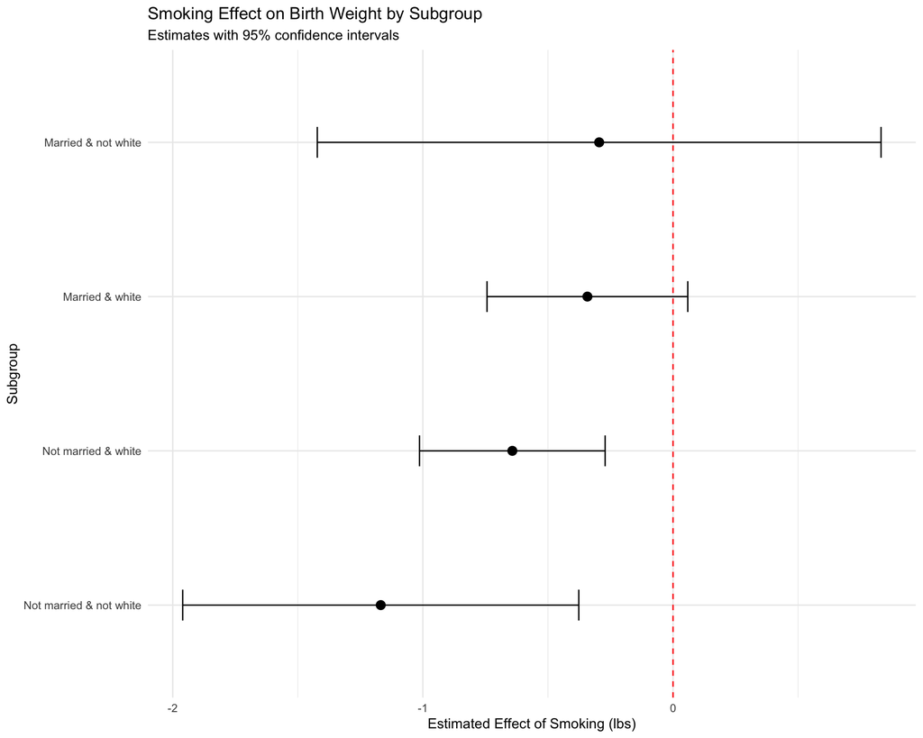

```r
ggplot(subgroup_weight_results, aes(x = reorder(subgroup, estimate), y = estimate)) +
  geom_point(size = 3) +
  geom_errorbar(aes(ymin = estimate - 1.96*std.error,
                    ymax = estimate + 1.96*std.error),
                width = 0.2) +
  geom_hline(yintercept = 0, linetype = "dashed", color = "red") +
  coord_flip() +
  labs(
    title = "Smoking Effect on Birth Weight by Subgroup",
    subtitle = "Estimates with 95% confidence intervals",
    x = "Subgroup",
    y = "Estimated Effect of Smoking (lbs)"
  ) +
  theme_minimal()
```

**Comprehensive interpretation of subgroup-specific estimates:**

**Effect magnitude and statistical significance:** The subgroup models reveal substantial variation in smoking’s impact:

- **Unmarried & Non-White:** -1.168 lbs (p = 0.005, 95% CI [-1.96, -0.38]) — largest effect, highly significant, but based on only 13 smokers with a wide confidence interval
- **Unmarried & White:** -0.642 lbs (p = 0.001, 95% CI [-1.01, -0.27]) — moderate effect, highly significant, most precise estimate (57 smokers)
- **Married & White:** -0.342 lbs (p = 0.095, 95% CI [-0.74, 0.06]) — smallest effect, marginally non-significant, moderate precision (38 smokers)
- **Married & Non-White:** -0.295 lbs (p = 0.609, 95% CI [-1.42, 0.83]) — unreliable due to only 6 smokers

**Pattern of heterogeneity — cumulative disadvantage gradient:** Excluding the unreliable married non-white estimate, a clear gradient emerges: unmarried non-white mothers show the largest smoking effects (-1.17 lbs), unmarried white mothers show intermediate effects (-0.64 lbs), and married white mothers show the smallest effects (-0.34 lbs).

This pattern supports a cumulative disadvantage hypothesis: mothers experiencing multiple forms of marginalization—being both unmarried and non-white—exhibit the strongest smoking effects. Possible mechanisms include:

1. **Cumulative stress:** Compounding stressors (economic insecurity, lack of partner support, racial discrimination) may amplify smoking’s biological harms
2. **Reduced protective resources:** Limited access to prenatal care, cessation programs, and social support means smoking’s effects go unmitigated
3. **Baseline vulnerability:** Pre-existing health disparities due to structural inequities may interact synergistically with smoking

**Sample size limitations and precision:**

- **Unmarried white (n = 57):** Most precise estimate, narrow CI
- **Married white (n = 38):** Moderate precision
- **Unmarried non-white (n = 13):** Small sample yields wide CI; directionally reliable but magnitude imprecise
- **Married non-white (n = 6):** Uninformative; insufficient data

**Implication:** Our strongest conclusions concern differences between married and unmarried white mothers (both reasonably sized samples) and between unmarried white and unmarried non-white mothers (where effect size is large enough to detect despite small samples).

**Consistency with interaction model:** The subgroup estimates closely match the interaction model predictions. The interaction model (Section 5.4.1) predicted a total effect of -1.189 lbs for unmarried non-white mothers; the independent subgroup model yields -1.168 lbs—nearly identical. This convergence across different modeling approaches strengthens confidence that heterogeneity is genuine rather than a modeling artifact.

**Multiple testing considerations:** With four subgroup tests at α = 0.05, we’d expect approximately 0.2 false positives if no true effects existed. We found 2-3 significant results (depending on threshold), exceeding chance expectations. We do not formally adjust p-values because: (1) subgroup analyses are exploratory, (2) the coherent gradient pattern across all estimates provides evidence beyond individual p-values, and (3) our focus is on effect sizes and clinical patterns rather than binary significance thresholds. We should interpret individual p-values cautiously and focus on the overall gradient pattern.

## 5.5 Non-Linear Models

Linear models may miss non-linear relationships or interactions we didn’t specify. We fit tree-based models to assess whether more complex patterns exist.

**Rationale for tree-based models:** Linear regression models impose strong assumptions: relationships are linear, and interactions must be explicitly specified. These assumptions may not hold. Decision trees and random forests offer an alternative as they automatically detect non-linear relationships, discover higher-order interactions without pre-specification, and provide variable importance measures showing which predictors matter most.

**Why we fit a direct effect model (including weeks/visits/gained):** While our primary analyses focus on total effect models, we fit the random forest using a direct effect specification that includes gestational weeks, prenatal visits, and maternal weight gain. This requires justification:

1. **Predictive performance goal:** Random forests optimize prediction, not causal inference. The question is: “How accurately can we predict birth weight with these data?” Including all available predictors provides the best benchmark for predictive performance.
2. **Fair comparison with linear models:** We already estimated a linear direct effect model (Section 5.3.1b, R² = 0.324). To test whether non-linearity matters, we compare models using the same predictors, isolating the effect of functional form (linear vs flexible). If the random forest substantially outperforms linear regression, it suggests important non-linearities exist. If performance is similar, linear models are adequate.
3. **Applied relevance:** In practice, a clinical risk prediction tool for low birth weight would use all available information, including gestational age and prenatal care patterns. The random forest shows whether machine learning adds value for this applied task.

The random forest complements the total effect linear models by testing whether our reliance on linear assumptions is justified.

#### 5.5.1 Decision Trees of Weight

We start with a single decision tree including weeks to establish baseline non-linear model performance.

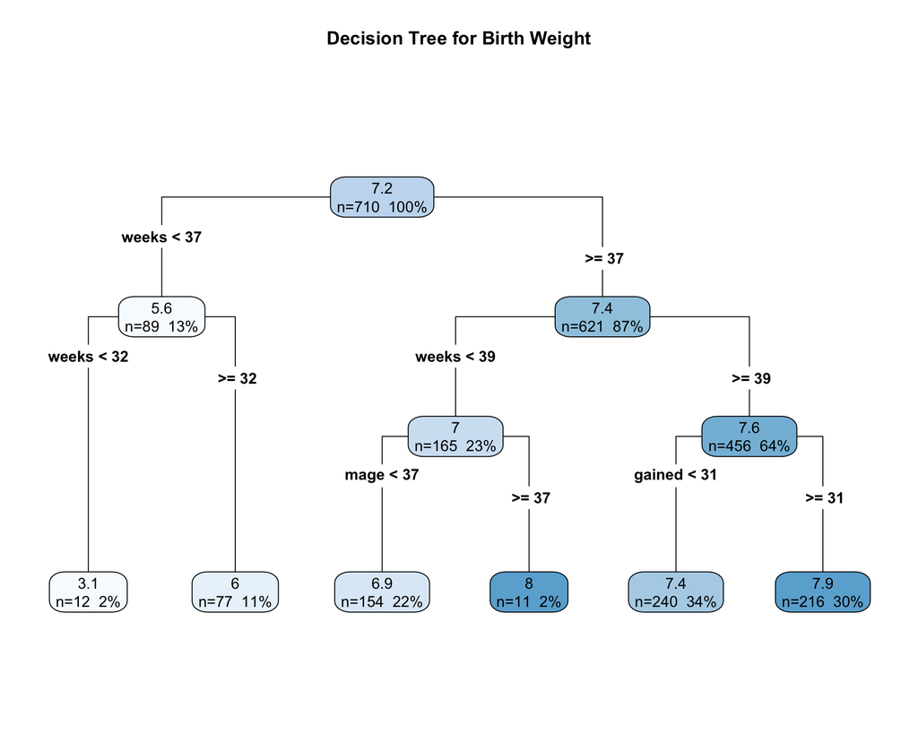

```r
tree_train <- model_train %>%
  drop_na(weight, weeks, smoker, mage, married, white, gained, visits)

tree_test <- model_test %>%
  drop_na(weight, weeks, smoker, mage, married, white, gained, visits)

weight_recipe_tree <- recipe(
  weight ~ weeks + smoker + mage + married + white + gained + visits,
  data = tree_train
) %>%
  step_naomit(all_predictors(), all_outcomes())

tree_spec <- decision_tree(
  cost_complexity = 0.01,
  tree_depth = 5,
  min_n = 20
) %>%
  set_engine("rpart") %>%
  set_mode("regression")

weight_tree_wflow <- workflow() %>%
  add_recipe(weight_recipe_tree) %>%
  add_model(tree_spec)

weight_tree_fit <- weight_tree_wflow %>%
  fit(data = tree_train)

weight_tree_fit %>%
  extract_fit_engine() %>%
  rpart.plot(
    roundint = FALSE,
    type = 4,
    extra = 101,
    main = "Decision Tree for Birth Weight"
  )
```

**Interpreting the decision tree:**

**Key decision rules:** After the initial gestational age split, the tree creates further divisions:

1. Within the preterm branch (weeks < 37): Splits again at weeks < 32, isolating extremely preterm babies (n=12, predicted weight 3.1 lbs)
2. Within the full-term branch (weeks ≥ 37): Splits at weeks < 39, then uses maternal age (mage < 37) and weight gained (gained < 31) for subsequent partitions

Does the tree find our subgroup patterns? The tree does not split on marital status or race at any level. This indicates that demographic variables add minimal predictive value once gestational age and prenatal care (gained) are accounted for. This differs from our subgroup analyses (Sections 5.4-5.5), but the goals are different: the tree optimizes prediction accuracy, while our subgroup models tested whether smoking’s effect differs by demographics. A variable can modify treatment effects without being a strong predictor of outcomes overall.

**Performance:**

- Test R² = 0.241 (vs linear direct effect R² = 0.311)
- Test RMSE = 1.128 lbs (vs linear RMSE = 1.068 lbs)

The decision tree performs worse than the linear model, suggesting relationships are primarily linear and additive. The tree’s added flexibility does not improve prediction, validating our reliance on simpler linear regression for interpretation.

```r
tree_preds <- weight_tree_fit %>%
  augment(tree_test)

tree_metrics <- tree_preds %>%
  metrics(truth = weight, estimate = .pred)

tree_metrics %>%
  dplyr::filter(.metric %in% c("mae", "rmse", "rsq")) %>%
  mutate(test_n = nrow(tree_test)) %>%
  kable(caption = "Decision Tree Performance Metrics", digits = 3)
```

Decision Tree Performance Metrics

| .metric | .estimator | .estimate | test_n |
| --- | --- | --- | --- |
| rmse | standard | 1.128 | 184 |
| rsq | standard | 0.241 | 184 |
| mae | standard | 0.861 | 184 |

**Performance vs linear models:** The decision tree achieves R² = 0.241 and RMSE = 1.128 lbs on the test set. Comparing to the linear direct effect model (which uses the same variables: weeks, visits, gained, plus demographics):

- Linear model: R² = 0.311, RMSE = 1.068 lbs
- Decision tree: R² = 0.241, RMSE = 1.128 lbs

The tree performs worse than linear regression, with lower explained variance and higher prediction error. This suggests that relationships between predictors and birth weight are primarily linear and additive. This validates our reliance on simpler linear models for interpretability without sacrificing predictive accuracy.

**What the tree reveals about birth weight prediction:** The tree structure confirms that gestational weeks dominates prediction, with the first split at weeks < 37 (preterm threshold) creating the largest separation in predicted birth weight (5.6 lbs vs 7.4 lbs). Within gestational age ranges, the tree identifies secondary predictors (maternal age and weight gained) that provide modest additional refinement.

#### 5.5.3 Random Forest for Weight

```r
rf_spec <- rand_forest(
  trees = 500,
  mtry = 3,
  min_n = 10
) %>%
  set_engine("ranger", importance = "impurity") %>%
  set_mode("regression")

rf_train_direct <- model_train_cc %>%
  drop_na(weight, weeks, smoker, mage, visits, gained, married, white)

rf_test_direct <- model_test_cc %>%
  drop_na(weight, weeks, smoker, mage, visits, gained, married, white)

weight_recipe_rf_direct <- recipe(
  weight ~ smoker + weeks + mage + visits + gained + married + white,
  data = rf_train_direct
) %>%
  step_naomit(all_predictors(), all_outcomes())

weight_rf_wflow_direct <- workflow() %>%
  add_recipe(weight_recipe_rf_direct) %>%
  add_model(rf_spec)

# Hyperparameter tuning
set.seed(123)
rf_folds_direct <- vfold_cv(rf_train_direct, v = 5, strata = "smoker")

rf_grid_direct <- grid_regular(
  mtry(range = c(2, 6)),
  min_n(range = c(5, 20)),
  levels = 3
)

rf_tune_direct <- tune_grid(
  weight_rf_wflow_direct,
  resamples = rf_folds_direct,
  grid = rf_grid_direct,
  metrics = metric_set(rmse, rsq, mae)
)

# Select best model
best_rf_direct <- select_best(rf_tune_direct, metric = "rmse")

# Finalize and fit
weight_rf_final_direct <- finalize_workflow(weight_rf_wflow_direct, best_rf_direct)
weight_rf_fit_direct <- fit(weight_rf_final_direct, data = rf_train_direct)

# Evaluate
rf_preds_direct <- weight_rf_fit_direct %>%
  augment(rf_test_direct)

rf_metrics_direct <- rf_preds_direct %>%
  metrics(truth = weight, estimate = .pred)

rf_metrics_direct %>%
  dplyr::filter(.metric %in% c("mae", "rmse", "rsq")) %>%
  mutate(test_n = nrow(rf_test_direct)) %>%
  kable(caption = "Random Forest Performance - Direct Effect (Sensitivity)", digits = 3)
```

Random Forest Performance - Direct Effect (Sensitivity)

| .metric | .estimator | .estimate | test_n |
| --- | --- | --- | --- |
| rmse | standard | 1.035 | 184 |
| rsq | standard | 0.354 | 184 |
| mae | standard | 0.793 | 184 |

**Performance comparison:** The random forest (RF-Direct) has R² = 0.354 and RMSE = 1.035 lbs on the test set. Comparing to the linear direct effect model (Section 5.3.1b, which uses the same variables: weeks, visits, gained, plus demographics):

- Linear direct effect: R² = 0.311, RMSE = 1.068 lbs
- Random forest: R² = 0.354, RMSE = 1.035 lbs

The random forest performs modestly better, explaining approximately 4 percentage points more variance and reducing prediction error by 0.03 lbs. This improvement is small but consistent, suggesting that minor non-linearities or interactions exist in how predictors relate to birth weight.

**Does non-linearity help when weeks is included?** Yes, but only marginally. The improvement from linear to random forest (ΔR² = 0.043) is modest, indicating that while some non-linear patterns exist, these complexities contribute minimally to overall prediction. The linear model with weeks already captures the essential relationships (R² = 0.311), and the random forest’s added flexibility provides only incremental gains.

**Implication:** Linear models are adequate for this prediction task. The small performance gain from random forests does not justify their loss of interpretability for most purposes. Our reliance on linear regression for coefficient interpretation and causal inference is validated.

```r
best_rf_direct |>
  kable(caption = "Best hyperparameters selected")
```

Best hyperparameters selected

| .config |
| --- |
| pre0_mod0_post0 |

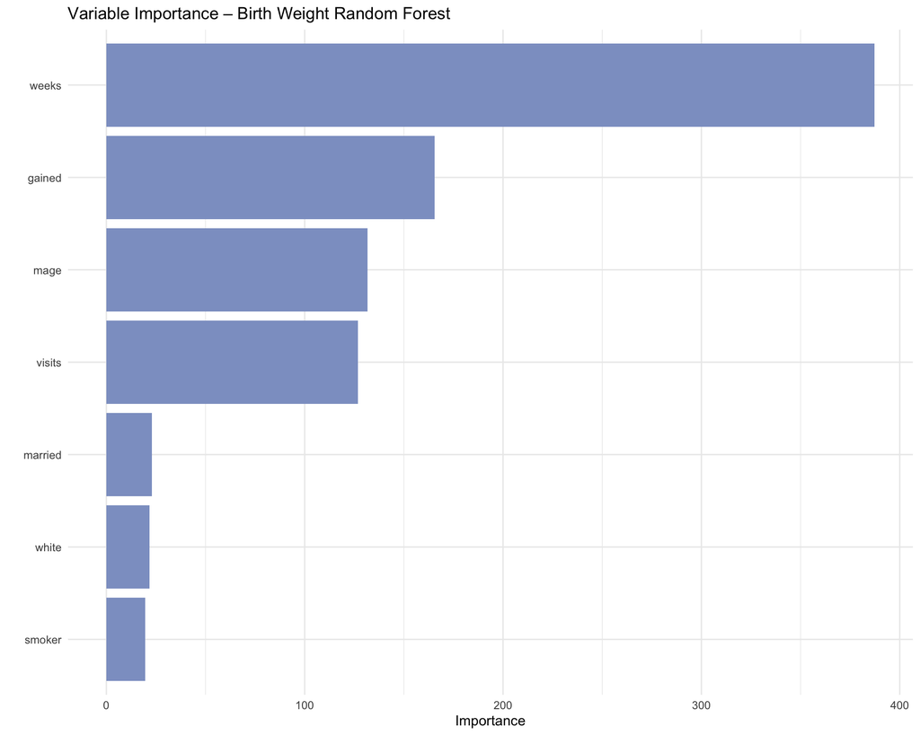

```r
weight_rf_fit_direct %>%
  extract_fit_parsnip() %>%
  vip(num_features = 10) +
  labs(title = "Variable Importance – Birth Weight Random Forest") +
  theme_minimal() +
  geom_col(fill = "#8DA0CB")
```

**Variable importance in the random forest:** The variable importance plot reveals a clear hierarchy:

1. Weeks dominates overwhelmingly (importance ≈ 400), confirming gestational age is by far the strongest predictor—consistent with linear models where weeks increased R² from 0.048 to 0.324.
2. Gained (importance ≈ 150) and mage (importance ≈ 120) rank second and third, showing moderate predictive value.
3. Visits (importance ≈ 100) contributes modestly.
4. Demographic variables (married, white, smoker) show minimal importance (each ≈ 20-30), appearing nearly interchangeable at the bottom of the ranking.

This pattern is consistent with mediation: smoking → weeks/visits/gained → birth weight. The random forest prioritizes the strongest proximate predictors (weeks, gained) over the upstream cause (smoking), even though smoking initiates the causal chain.

**Interpretation and practical implications:** The random forest’s variable importance ranking does not contradict our findings. Rather, it complements them by revealing the predictive hierarchy. For prediction (the forest’s goal), knowing gestational weeks is more informative than knowing smoking status, because weeks is closer to the outcome in the causal chain. For causal inference (our goal in Parts 5-6), smoking remains the key intervention target, even if its predictive importance appears modest once mediators are included.

The forest confirms that prenatal care variables (visits, gained) and especially gestational weeks are critical predictors of birth weight. However, because smoking affects these variables, the low importance of smoking in this model does not diminish its causal role—it simply reflects that the forest uses downstream consequences (weeks) rather than upstream causes (smoking) for prediction when both are available.

#### 5.5.4 Subgroup Performance Evaluation

We evaluate how all models perform within each subgroup to detect if prediction quality varies across demographics.

```r
# Linear direct effect (complete case test set only)
lm_direct_preds <- weight_fit_direct %>%
  augment(model_test_cc %>% drop_na(weight, weeks, smoker, mage, visits, gained, married, white, cluster_label)) %>%
  dplyr::select(cluster_label, weight, .pred) %>%
  mutate(model = "Linear")

# Decision tree
tree_preds_sub <- tree_preds %>%
  dplyr::select(cluster_label, weight, .pred) %>%
  mutate(model = "Tree")

# RF direct
rf_direct_preds_sub <- rf_preds_direct %>%
  dplyr::select(cluster_label, weight, .pred) %>%
  mutate(model = "RF")

# Combine all predictions
all_preds <- bind_rows(
  lm_direct_preds,
  tree_preds_sub,
  rf_direct_preds_sub
)

# Calculate RMSE by subgroup and model
subgroup_rmse <- all_preds %>%
  group_by(cluster_label, model) %>%
  rmse(truth = weight, estimate = .pred) %>%
  dplyr::select(cluster_label, model, .estimate) %>%
  pivot_wider(names_from = model, values_from = .estimate)

subgroup_rmse %>%
  kable(caption = "RMSE by Subgroup and Model Type: Direct Models", digits = 3)
```

RMSE by Subgroup and Model Type: Direct Models

| cluster_label | Linear | RF | Tree |
| --- | --- | --- | --- |
| Married & not white | 1.308 | 1.262 | 1.216 |
| Married & white | 1.046 | 0.983 | 1.111 |
| Not married & not white | 1.139 | 1.068 | 1.200 |
| Not married & white | 0.945 | 1.008 | 1.088 |

**RMSE by subgroup and model type:** Prediction quality varies substantially across demographic subgroups:

**Worst predictions (highest RMSE):**

- Married & not white: RMSE from 1.216 (tree) to 1.308 (linear), consistently the highest errors
- Not married & not white: RMSE from 1.068 (RF) to 1.200 (tree), moderate-high errors

```r
subgroup_rsq <- all_preds %>%
  group_by(cluster_label, model) %>%
  rsq(truth = weight, estimate = .pred) %>%
  dplyr::select(cluster_label, model, .estimate) %>%
  pivot_wider(names_from = model, values_from = .estimate)

subgroup_rsq %>%
  kable(caption = "R-squared by Subgroup and Model Type: Direct Models", digits = 3)
```

R-squared by Subgroup and Model Type: Direct Models

| cluster_label | Linear | RF | Tree |
| --- | --- | --- | --- |
| Married & not white | 0.270 | 0.349 | 0.413 |
| Married & white | 0.177 | 0.265 | 0.128 |
| Not married & not white | 0.581 | 0.626 | 0.518 |
| Not married & white | 0.386 | 0.296 | 0.224 |

**R-squared by subgroup and model type:** Explained variance varies substantially across demographic subgroups, revealing differential model performance:

**Highest R² (best explanatory power):**

- Not married & not white: R² ranges from 0.518 (tree) to 0.626 (RF), explaining 52-63% of variance—the best performance across all subgroups
- Not married & white: R² from 0.224 (tree) to 0.386 (linear), moderate explanatory power

**Lowest R² (weakest explanatory power):**

- Married & white: R² from 0.128 (tree) to 0.265 (RF), explaining only 13-27% of variance
- Married & not white: R² from 0.270 (linear) to 0.413 (tree), low-moderate performance

**Pattern interpretation:** Counterintuitively, the model explain more variance for unmarried non-white mothers despite this subgroup having higher prediction errors (RMSE) in absolute terms. This suggests that within this vulnerable subgroup, the relationship between predictors and birth weight is stronger and more systematic, even though baseline birth weights are lower and more variable. For married white mothers, much of the variation in birth weight appears idiosyncratic—driven by unmeasured factors our predictors don’t capture.

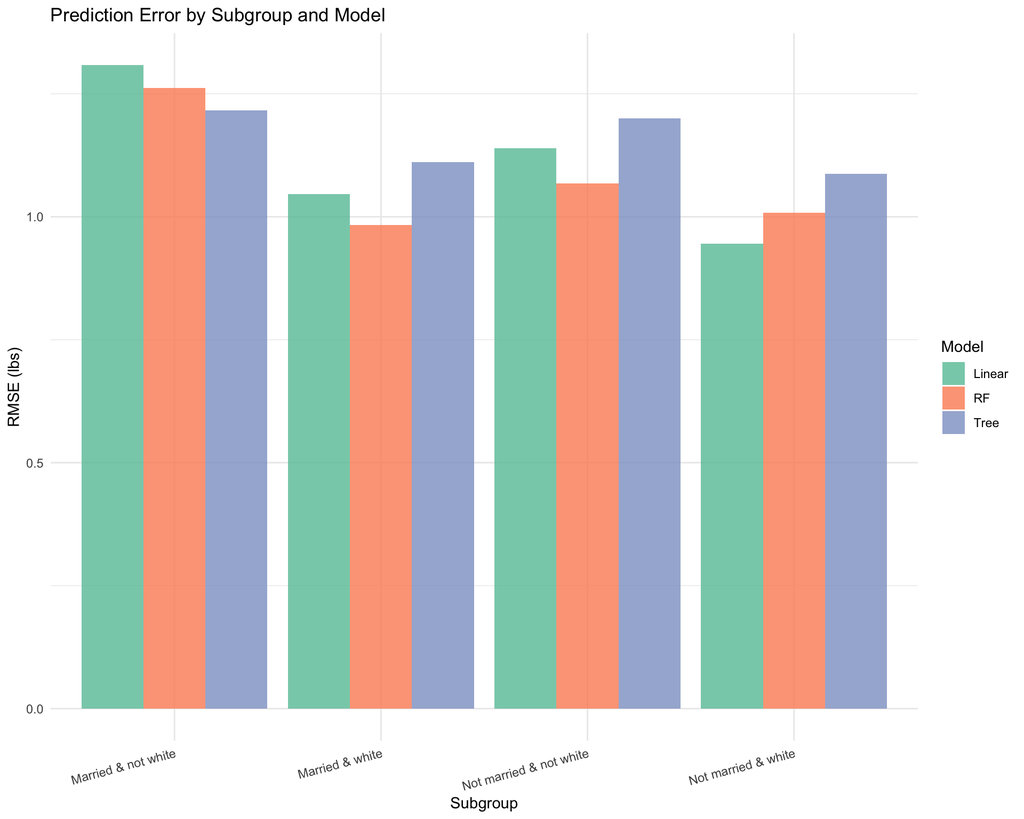

```r
# Visualization of subgroup performance
all_preds %>%
  group_by(cluster_label, model) %>%
  rmse(truth = weight, estimate = .pred) %>%
  ggplot(aes(x = cluster_label, y = .estimate, fill = model)) +
  geom_col(position = "dodge", alpha = 0.8) +
  labs(
    title = "Prediction Error by Subgroup and Model",
    x = "Subgroup",
    y = "RMSE (lbs)",
    fill = "Model"
  ) +
  theme_minimal() +
  theme(axis.text.x = element_text(angle = 15, hjust = 1)) +
  scale_fill_brewer(palette = "Set2")
```

**Subgroup performance differences:**

**Which subgroups are hardest to predict?** Visual inspection and RMSE values reveal clear patterns:

- Married & not white: Consistently highest RMSE (1.216-1.308 lbs) across all models, indicating the poorest predictions. However, this subgroup also has the smallest sample (n=107 total, only 6 smokers from Section 5.4.2), making estimates unstable.
- Not married & not white: Moderate-high RMSE (1.068-1.200 lbs) despite having the highest R² (0.518-0.626). This paradox suggests that while predictors explain more variance within this group, baseline birth weights are lower and prediction errors remain substantial in absolute terms.
- Both white subgroups (married & white, not married & white) show the lowest RMSE (0.945-1.111 lbs), indicating better predictions.

**Pattern:** Both non-white subgroups consistently show higher prediction errors, suggesting important unmeasured factors affecting non-white mothers’ birth outcomes that our predictors do not capture. These likely include structural determinants: healthcare quality disparities, neighborhood-level environmental exposures, chronic stress from discrimination, and differential access to resources.

**Do models differ in which subgroups they predict well?** Random forests generally outperform linear models across most subgroups, but the magnitude of improvement varies:

- Largest RF improvement: Not married & not white (Linear RMSE = 1.139 vs RF RMSE = 1.068, a 0.07 lb reduction). The RF also achieves R² = 0.626 vs linear R² = 0.581, suggesting non-linear relationships or interactions matter more for this vulnerable population.
- Smallest RF improvement: Not married & white (Linear RMSE = 0.945 vs RF RMSE = 1.008—RF actually performs worse), suggesting relationships are more linear and straightforward for this group.
- Decision trees show inconsistent performance—sometimes competitive (married & not white: Tree RMSE = 1.216), sometimes much worse (married & white: Tree R² = 0.128 vs Linear R² = 0.177). This variability suggests overfitting in small subgroups.

**Model complexity benefits vary by subgroup:** The added complexity of moving from Linear → Tree → RF does not help uniformly:

This heterogeneity in model performance across subgroups suggests that relationship complexity differs by demographics. Vulnerable populations (unmarried, non-white) may have more complex, context-dependent relationships between predictors and outcomes, while advantaged populations show simpler, more linear patterns.

**Link to effect heterogeneity:** Prediction quality does not correlate strongly with smoking effect size:

- Not married & not white has the largest smoking effect (-1.168 lbs, Section 5.4.2) but achieves the highest R² (0.626), suggesting predictors work well despite large effects.
- Married & white has the smallest smoking effect (-0.342 lbs) but shows low R² (0.128-0.265), indicating poor prediction despite small effects.

This suggests that subgroups with large smoking effects do not necessarily have more unmeasured confounding or inherent unpredictability. Instead, prediction difficulty appears driven more by sample size (married & not white has only 6 smokers) and differential data quality across demographic groups than by effect magnitude.

**Implications for model choice:**

Low R² does not mean models are uninformative. They successfully identify meaningful associations (smoking effects, racial disparities, gestational age relationships) even while explaining limited overall variance. Prediction and inference serve different goals: models can have low predictive accuracy yet provide valid causal estimates if assumptions are met.

## 5.6 Modeling Summary

**Baseline linear models:** Smoking shows consistent, significant associations with adverse birth outcomes across all specifications. The total effect model estimates smoking reduces birth weight by -0.593 lbs (p < 0.001) and gestational age by -0.767 weeks (p = 0.003), adjusting for maternal age, marital status, and race. The direct effect model, which includes gestational weeks, prenatal visits, and maternal weight gain, estimates a smoking effect of -0.394 lbs (p = 0.003)—a 33.6% attenuation. This suggests approximately 34% of smoking’s total effect operates through shortened gestation and altered prenatal care, while 66% reflects direct intrauterine growth restriction. Low R² values (0.048 for total effect, 0.324 for direct effect) are expected for birth weight models, reflecting high individual variability driven by genetic and unmeasured biological factors rather than model inadequacy.

**Total vs direct effect distinction:** Total effect models (excluding weeks/visits/gained) estimate smoking’s overall population-level impact through all pathways and serve as our primary analysis. They preserve the full smoker sample (n=114) and provide policy-relevant estimates of smoking’s net harm. Direct effect models (including weeks/visits/gained) decompose mechanisms and serve as sensitivity analyses, though they require complete-case analysis (n=78 smokers) and shift the estimand toward effects operating independently of gestational timing. Without direct measurement of socioeconomic status, we cannot definitively distinguish whether prenatal care variables are mediators (downstream of smoking) or confounders (correlated with unmeasured SES). Main conclusions are based on total effects as more robust and generalizable.

**Heterogeneity testing:** Clear evidence of effect heterogeneity emerges across demographic subgroups. The interaction model found a significant smoking×unmarried non-white coefficient of -0.846 (p = 0.049). Independent subgroup models confirmed this pattern: smoking effects range from -0.342 lbs for married white mothers (p = 0.095, not significant) to -1.168 lbs for unmarried non-white mothers (p = 0.005). This gradient—largest effects for the most vulnerable, smallest for the most advantaged—is consistent with cumulative disadvantage. However, some subgroups have very small samples (married non-white: only 6 smokers, yielding unreliable estimates), multiple testing increases false positive risk, and confidence intervals are wide for small subgroups.

### 5.6.1: Key Limitations

**Inability to distinguish mediation from confounding:** Without direct measurement of socioeconomic status (income, education, occupation), we cannot definitively determine whether prenatal care variables (visits, gained) are mediators (downstream consequences of smoking) or confounders (correlated with unmeasured SES). This ambiguity means we cannot precisely decompose smoking’s pathways, though the consistency of total effect estimates across specifications provides some reassurance.

**Small sample sizes in subgroups:** Some demographic subgroups have very few smokers, particularly married non-white mothers (n=6), yielding extremely wide confidence intervals and unreliable estimates. This limits our ability to draw firm conclusions about effect heterogeneity in all populations and reduces statistical power to detect true differences.

**Multiple testing concerns:** Testing smoking effects across four demographic subgroups increases the probability of false positives. While we found 2-3 significant results (depending on threshold), the coherent gradient pattern across all estimates provides stronger evidence than individual p-values alone. We should focus on the overall pattern of cumulative disadvantage rather than treating any single p-value as definitive.

**Low explained variance:** R² values range from 4.8% (total effect model) to 32.4% (direct effect model), reflecting that most variation in birth weight arises from unmeasured factors. Low R² does not invalidate findings; effect sizes remain clinically meaningful and statistically significant despite limited overall prediction accuracy.

**Limited gains from model complexity:** Random forests improved prediction only modestly over linear regression (ΔR² ≈ 4 percentage points), and decision trees performed worse, suggesting relationships are primarily linear and additive. This validates our linear modeling approach but also indicates we are not missing substantial non-linear patterns that more complex methods could capture. The marginal improvements do not justify sacrificing interpretability for most applications.

**Generalizability constraints:** Findings apply to US births in 2014 with the specific demographic composition of this sample. Results may not generalize to other time periods, populations, or smoking patterns (intensity, timing, cessation attempts not measured).

# Part 6: Causal Inference via Propensity Score Matching

Smoking is a strong predictor in all models (linear, interaction, random forest), consistently associated with lower birth weight and shorter gestation. However, **none of the models in Part 5 are causal**. All estimates are conditional associations that could be confounded by unmeasured factors.

**Key questions:** - What would birth outcomes have been if smokers had not smoked? (counterfactual) - How do causal estimates from PSM compare to associational estimates from regression? - Does the causal effect vary across subgroups?

## 6.1 Causal Framework and Assumptions

**Causal question:** What is the effect of maternal smoking during pregnancy on birth weight and gestational age, comparing outcomes if the same mother smoked vs did not smoke (counterfactual contrast)?

We estimate the Average Treatment Effect on the Treated (ATT)—the effect of smoking among mothers who actually smoked—rather than the Average Treatment Effect (ATE), which would estimate the effect of smoking averaged across the entire population. ATT answers: “Among mothers who smoked, how much harm did smoking cause?” ATE answers: “If we randomly assigned everyone to smoke or not smoke, what would the average effect be?”

**Why ATT instead of ATE?** 1. **Policy relevance:** The key policy question is “What would happen if current smokers quit?” not “What if everyone smoked?” 2. **Overlap considerations:** Smokers are a minority (12% of our sample, n=114). Estimating ATE requires predicting outcomes for the 867 non-smokers if they had smoked, which demands stronger extrapolation beyond observed data and stricter positivity assumptions. With a 7.6:1 ratio of non-smokers to smokers, we have better empirical support for estimating “what if smokers didn’t smoke” than the reverse. 3. **Sample composition:** With 7.6:1 ratio of non-smokers to smokers, we have abundant controls to match to each smoker. 4. **Interpretation:** ATT directly answers the intervention question for the treated population (those who would benefit from cessation programs).

**Key assumptions for causal interpretation:**

Propensity score matching provides causal estimates only ig gour key assumptions hold.

1. **Exchangeability (No unmeasured confounding):** After matching on observed characteristics (age, race, marital status), smokers and non-smokers are comparable in all ways that matter for birth outcomes. Any remaining differences in outcomes can be attributed to smoking rather than pre-existing differences between groups.

**What remains unmeasured:** Many important confounders are not captured in our data, including socioeconomic status (income, education, occupation), maternal health conditions (pre-pregnancy BMI, chronic diseases, infections), mental health (depression, anxiety, stress), substance use beyond smoking (alcohol, drugs), health literacy and behaviors, motivation to quit smoking, partner smoking and household environment, neighborhood conditions and environmental exposures, and access to and quality of healthcare. **Assessment:** This assumption is almost certainly violated. We lack measurement of numerous factors that plausibly affect both smoking decisions and birth outcomes. The assumption is fundamentally uncheckable—we cannot test for confounders we haven’t measured. **Implication:** Our estimates are conditional on observed confounders only. Unmeasured confounding likely remains and could bias estimates. If unmeasured factors like low SES, poor health, or high stress make both smoking and poor birth outcomes more likely, we will overestimate smoking’s true causal effect. The true effect could be substantially smaller than our estimate, though the magnitude of bias is unknown.

2. **Positivity (Overlap):** Every type of mother (defined by observed covariates) has some chance of both smoking and not smoking. We need both smokers and non-smokers across all covariate combinations to make valid comparisons. If all mothers of a certain type smoke (or none smoke), we cannot estimate the counterfactual.

**Assessment:** We examine propensity score distributions visually in Section 6.3 to check for adequate overlap. If violations are detected—regions where only smokers or only non-smokers exist—we restrict analysis to the common support region, excluding mothers with propensity scores near 0 or 1 where no comparable matches exist.

3. **Consistency (Well-defined treatment):** “Smoking” means the same thing for everyone—the exposure is well-defined and comparable across individuals.

**Assessment** This assumption is reasonably plausible. Smoking is recorded as binary (smoker/nonsmoker) in our data, providing a clear treatment definition. **Limitation:** We have no information on smoking intensity (cigarettes per day), duration (when started/stopped during pregnancy), or timing (which trimester). Light and heavy smoking are treated identically, as are women who quit early versus those who smoked throughout pregnancy. Our estimates represent the effect of “any smoking during pregnancy” as recorded, averaging across heterogeneous exposure patterns. **Implication:** Estimates capture an average effect across diverse smoking behaviors. We cannot distinguish whether light smoking is less harmful than heavy smoking or whether cessation timing matters.

4. **SUTVA (No interference):** Mother A’s smoking doesn’t influence Mother B’s baby’s birth weight. Units (mothers) are independent observations.

**Assessment:** This assumption is very plausible. Mothers in this dataset are independent observations from different pregnancies. Violation would require mothers to be partners, relatives sharing environments, or subject to spillover effects, which is highly unlikely in this context.

**Sensitivity to violations:** Even modest unmeasured confounding can substantially bias ATT estimates. The direction of bias depends on how unmeasured confounders relate to both smoking and outcomes. If unmeasured factors (low SES, poor health, high stress) increase both the probability of smoking and the risk of poor birth outcomes, we will overestimate smoking’s causal effect. The true causal effect is likely smaller than our estimate, potentially substantially so, though we cannot quantify the magnitude of bias without measuring the confounders. We proceed with appropriate caution, interpreting results as “effects conditional on observed confounders” rather than definitive causal claims. The estimates provide the best causal inference possible given available data, but readers should recognize the fundamental limitation that unmeasured confounding likely biases results upward.

## 6.2 Propensity Score Estimation

We estimate propensity scores (probability of smoking) using logistic regression with pre-treatment covariates.

**What is a propensity score?** The propensity score is the probability that a mother smokes given her observed characteristics: e(X) = P(Smoke=1|X). A fundamental result in causal inference is that if treatment assignment is conditionally independent of potential outcomes given covariates X (the exchangeability assumption), it is also conditionally independent given the propensity score e(X). This means we can match on a single summary score instead of matching simultaneously on all covariates—an approach that becomes intractable in high dimensions as the number of covariates grows.

**Covariate selection rationale:**

**Main propensity model (demographics only):** Our primary propensity score model includes maternal age, marital status, and race—the demographic confounders identified in Part 4 as associated with both smoking and birth outcomes. Critically, we exclude prenatal visits and weight gained from the main model for four reasons:

1. **Differential missingness:** As documented in Section 1.2, 30% of smokers have missing prenatal visit data compared to only 2.5% of non-smokers. Including these variables would force complete-case analysis that disproportionately removes smokers, creating a matched sample unrepresentative of the smoker population we aim to study.
2. **Potential mediators:** Visits and gained may lie downstream of smoking due to stigma, shame, or reduced engagement with healthcare (Scenario A from Section 5.1: Smoking → Reduced prenatal care → Poor outcomes). Conditioning on mediators would block causal pathways and estimate direct rather than total effects.
3. **Total effect estimand:** Our main analysis targets smoking’s overall impact as experienced in the population, not its effect controlling for prenatal care behavior.
4. **Sample preservation:** Excluding visits/gained retains all 114 smokers rather than the 78 who have complete data, maximizing statistical power and generalizability.

Father’s age is also excluded due to high differential missingness (25% among unmarried mothers vs 1.5% among married mothers, Section 1.2), strong correlation with maternal age, and limited theoretical importance beyond what maternal age captures.

**Sensitivity propensity model (with visits/gained):** To test robustness, we estimate a sensitivity model including maternal age, marital status, race, prenatal visits, and weight gained. This specification tests whether results are sensitive to the ambiguity about visits/gained as mediators versus confounders (Scenario B: SES → Smoking AND SES → Visits/Gained → Outcomes). The sensitivity model requires complete-case analysis (n=894 total, 78 smokers), losing 36 smokers. If results are similar to the main analysis, our estimates are robust to this specification choice. If different, visits/gained matter substantively, though we still cannot definitively distinguish mediation from confounding without measuring SES.

```r
ps_data <- model_data %>%
  dplyr::select(weight, weeks, smoker, mage, married, white, cluster_label,
                visits, gained) %>%
  drop_na(weight, weeks, smoker, mage, married, white, cluster_label)

cat("Propensity score sample size:", nrow(ps_data), "\n")
```

```
Propensity score sample size: 981
```

```r
cat("Smokers:", sum(ps_data$smoker), "\n")
```

```
Smokers: 114
```

```r
cat("Non-smokers:", sum(ps_data$smoker == 0), "\n")
```

```
Non-smokers: 867
```

```r
# Main propensity model: demographics only
ps_model <- glm(smoker ~ mage + married + white,
                data = ps_data,
                family = binomial(link = "logit"))

summary(ps_model)
```

```
Call:
glm(formula = smoker ~ mage + married + white, family = binomial(link = "logit"),
    data = ps_data)

Coefficients:
             Estimate Std. Error z value Pr(>|z|)
(Intercept) -2.178143   0.548367  -3.972 7.13e-05 ***
mage         0.006325   0.018696   0.338   0.7351
married     -1.035876   0.224379  -4.617 3.90e-06 ***
white        0.615973   0.268440   2.295   0.0218 *
---
Signif. codes:  0 '***' 0.001 '**' 0.01 '*' 0.05 '.' 0.1 ' ' 1

(Dispersion parameter for binomial family taken to be 1)

    Null deviance: 704.95  on 980  degrees of freedom
Residual deviance: 677.22  on 977  degrees of freedom
AIC: 685.22

Number of Fisher Scoring iterations: 5
```

**Interpreting the propensity score model:** The logistic regression coefficients reveal which characteristics predict smoking probability:

**Model fit:** The model reduces deviance from 704.95 (null model) to 677.22 (fitted model), indicating it explains some variation in smoking behavior. The AIC of 685.22 provides a baseline for comparing to the sensitivity model. The model converged successfully in 5 Fisher Scoring iterations, indicating stable estimation. While the model captures meaningful selection into smoking based on marital status and race, substantial unexplained variation remains—smoking behavior is influenced by many factors beyond demographics, including the unmeasured confounders (SES, mental health, social networks) discussed in Section 6.1.

**Interpretation:** This model captures selection into smoking based on observable demographics. Mothers with certain profiles—unmarried and white—are systematically more likely to smoke. These demographic patterns create confounding because, as demonstrated in Part 4, the same characteristics are also associated with birth outcomes (unmarried and non-white mothers have worse baseline outcomes independent of smoking). The propensity score condenses this multidimensional confounding into a single probability. Instead of matching on three variables simultaneously (which becomes difficult as dimensionality increases), we can match on the single propensity score. Under the balancing property of propensity scores, mothers with the same propensity score have, on average, the same distribution of observed confounders—meaning we can compare smokers and non-smokers with similar scores as if they were randomly assigned to treatment.

```r
ps_data$propensity_score <- predict(ps_model, type = "response")
```

## 6.3 Assessing Overlap Before Matching

We examine whether smokers and non-smokers have overlapping propensity score distributions. Good overlap is essential for valid matching. Without it, we’re comparing apples to oranges.

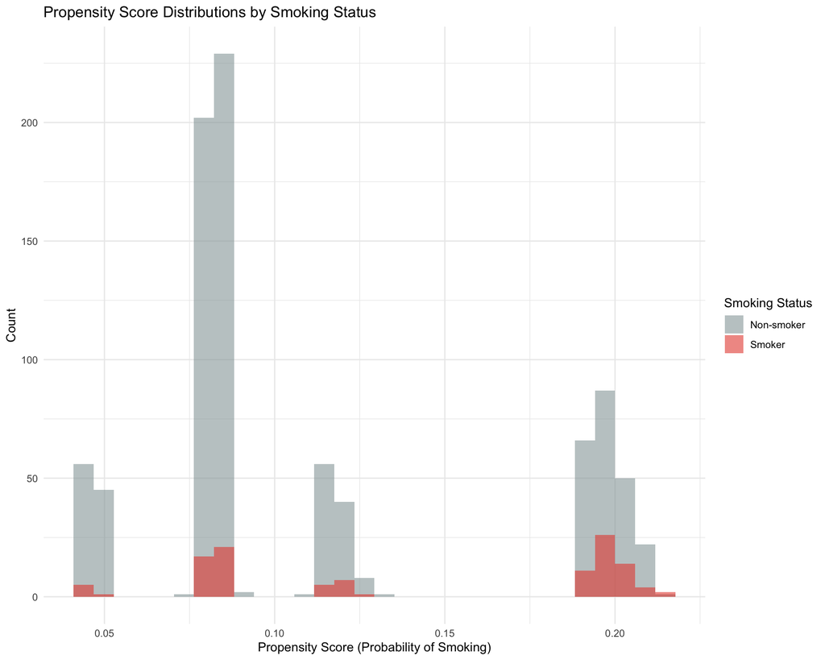

```r
ggplot(ps_data, aes(x = propensity_score, fill = factor(smoker))) +
  geom_histogram(alpha = 0.6, position = "identity", bins = 30) +
  scale_fill_manual(values = c("0" = "#95a5a6", "1" = "#e74c3c"),
                    labels = c("Non-smoker", "Smoker")) +
  labs(
    title = "Propensity Score Distributions by Smoking Status",
    x = "Propensity Score (Probability of Smoking)",
    y = "Count",
    fill = "Smoking Status"
  ) +
  theme_minimal()
```

```r
ps_summary <- ps_data %>%
  group_by(smoker) %>%
  summarise(
    n = n(),
    `Min PS` = min(propensity_score),
    `Mean PS` = mean(propensity_score),
    `Max PS` = max(propensity_score),
    .groups = "drop"
  )

ps_summary %>%
  kable(caption = "Propensity Score Summary by Treatment Status", digits = 3) %>%
  kable_styling(bootstrap_options = c("striped", "hover"), full_width = FALSE)
```

Propensity Score Summary by Treatment Status

| smoker | n | Min PS | Mean PS | Max PS |
| --- | --- | --- | --- | --- |
| 0 | 867 | 0.044 | 0.113 | 0.215 |
| 1 | 114 | 0.044 | 0.143 | 0.213 |

**Propensity score range and overlap assessment:** The summary statistics confirm adequate overlap:

- Non-smokers: PS ranges from 0.044 to 0.215 (mean = 0.113, n = 867)
- Smokers: PS ranges from 0.044 to 0.213 (mean = 0.143, n = 114)

**Critical check:** The minimum PS for smokers (0.044) is not greater than the maximum PS for non-smokers (0.215), indicating at least some overlap exists. In fact, the ranges are nearly identical, with both groups spanning from approximately 0.044 to 0.21.

**Mean comparison:** As expected, smokers have a higher mean PS (0.143) than non-smokers (0.113), reflecting that smokers possess characteristics associated with higher smoking probability. The 0.03-point difference confirms selection—smokers and non-smokers differ systematically in observed demographics—but the overlapping ranges (both groups span 0.044-0.21+) indicate positivity is satisfied across most of the distribution.

**Implications for matching:** The overlap quality is good. Most propensity score values contain both smokers and non-smokers, making matching feasible across nearly all smokers. We can proceed with standard nearest-neighbor matching using a caliper (Section 6.4) to ensure high-quality matches and exclude any smokers at extreme propensity scores who lack close comparisons. The excellent overlap supports valid causal inference within the common support region, though estimates will not generalize to the handful of smokers with PS > 0.215 if they are excluded by the caliper.

## 6.4 Propensity Score Matching

We implement 1:3 nearest-neighbour matching with a caliper to create comparable groups of smokers and non-smokers while maximising the use of our abundant control reservoir.

**Matching specifications:**

**Method:** Each smoker is matched to up to 3 non-smokers with the closest propensity scores. With 867 non-smokers and 114 smokers (7.6:1 ratio), we have ample controls to support 1:3 matching. This approach balances competing goals: utilising more control data than 1:1 matching (which would use only 114 controls and leave 753 unmatched) while maintaining better match quality than 1:5 or higher ratios (which risk pairing smokers with increasingly dissimilar non-smokers). Matching each smoker to 3 non-smokers increases precision by reducing variance in the ATT estimate.

**Caliper:** We impose a caliper of 0.2 standard deviations of the logit propensity score. The caliper defines the maximum allowable distance between matched units — smokers and non-smokers whose logit propensity scores differ by more than 0.2 standard deviations are not matched. This threshold, commonly recommended in the medical literature (Austin, 2011), balances match quality against sample retention: tighter calipers (e.g., 0.1 SD) produce better matches but discard more smokers; looser calipers (e.g., 0.3 SD) retain more smokers but risk poor balance. Measuring distance in standard deviation units (`std.caliper = TRUE`) makes the threshold comparable across datasets regardless of propensity score scale.

**Replacement:** Matching is conducted without replacement, meaning each non-smoker can serve as a control for at most one smoker. Under 1:3 matching, this requires 342 unique controls for 114 smokers — well within the available pool of 867 non-smokers. Without-replacement matching avoids overweighting any single control observation, producing a matched sample with straightforward interpretation.

```r
match_formula <- as.formula(smoker ~ mage + married + white)

match_result <- matchit(
  match_formula,
  data = ps_data,
  method = "nearest",
  distance = "glm",
  ratio = 3,
  caliper = 0.2,
  std.caliper = TRUE,
  replace = FALSE
)

summary(match_result)
```

```
Call:
matchit(formula = match_formula, data = ps_data, method = "nearest",
    distance = "glm", replace = FALSE, caliper = 0.2, std.caliper = TRUE,
    ratio = 3)

Summary of Balance for All Data:
         Means Treated Means Control Std. Mean Diff. Var. Ratio eCDF Mean
distance        0.1426        0.1127          0.5150     1.1765    0.1327
mage           27.5877       28.5236         -0.1731     0.8720    0.0338
married         0.3860        0.6171         -0.4747          .    0.2311
white           0.8333        0.7612          0.1934          .    0.0721
         eCDF Max
distance   0.2534
mage       0.1005
married    0.2311
white      0.0721

Summary of Balance for Matched Data:
         Means Treated Means Control Std. Mean Diff. Var. Ratio eCDF Mean
distance        0.1426        0.1425          0.0023     1.0099    0.0017
mage           27.5877       27.4444          0.0265     1.0139    0.0052
married         0.3860        0.3860         -0.0000          .    0.0000
white           0.8333        0.8333         -0.0000          .    0.0000
         eCDF Max Std. Pair Dist.
distance   0.0205          0.0025
mage       0.0205          0.0287
married    0.0000          0.0000
white      0.0000          0.0000

Sample Sizes:
          Control Treated
All           867     114
Matched       342     114
Unmatched     525       0
Discarded       0       0
```

**Matching results and sample sizes:** All 114 smokers were successfully matched, with zero smokers discarded by the caliper. This indicates that every smoker is matched to 3 non-smokers within 0.2 standard deviations of their logit propensity score, confirming strong overlap. The matching procedure used 342 non-smokers (exactly 3 × 114), meaning each smoker received the full complement of 3 matches. The remaining 525 non-smokers were left unmatched, as expected given our abundant control reservoir.

**Balance assessment — before matching:** The unmatched data showed substantial imbalance on all covariates, confirming that smokers and non-smokers differ systematically: propensity score distance SMD = 0.515, married SMD = −0.475 (smokers much less likely to be married), white SMD = 0.193 (smokers more likely to be white), and maternal age SMD = −0.173 (smokers slightly younger). All SMDs exceed 0.1, indicating meaningful pre-matching differences that create confounding.

**Balance assessment — after matching:** Matching achieved excellent balance on all covariates: propensity score distance SMD = 0.0023, married SMD = 0.0000, white SMD = 0.0000, and maternal age SMD = 0.0265. All post-matching SMDs are well below the 0.1 threshold, with most effectively zero. Variance ratios are close to 1.0 for all continuous variables (distance = 1.009, mage = 1.013), confirming that variability as well as means is balanced between groups. eCDF statistics show substantial improvement, with the distance eCDF max reducing from 0.25 to 0.02.

Matching achieved excellent balance on all observed covariates included in the propensity score model. The matched sample is suitable for ATT estimation, and because all 114 smokers were retained, estimates pertain to the full population of smokers in our sample rather than a selected subset. Unmeasured confounding (Section 6.1) remains the critical limitation.

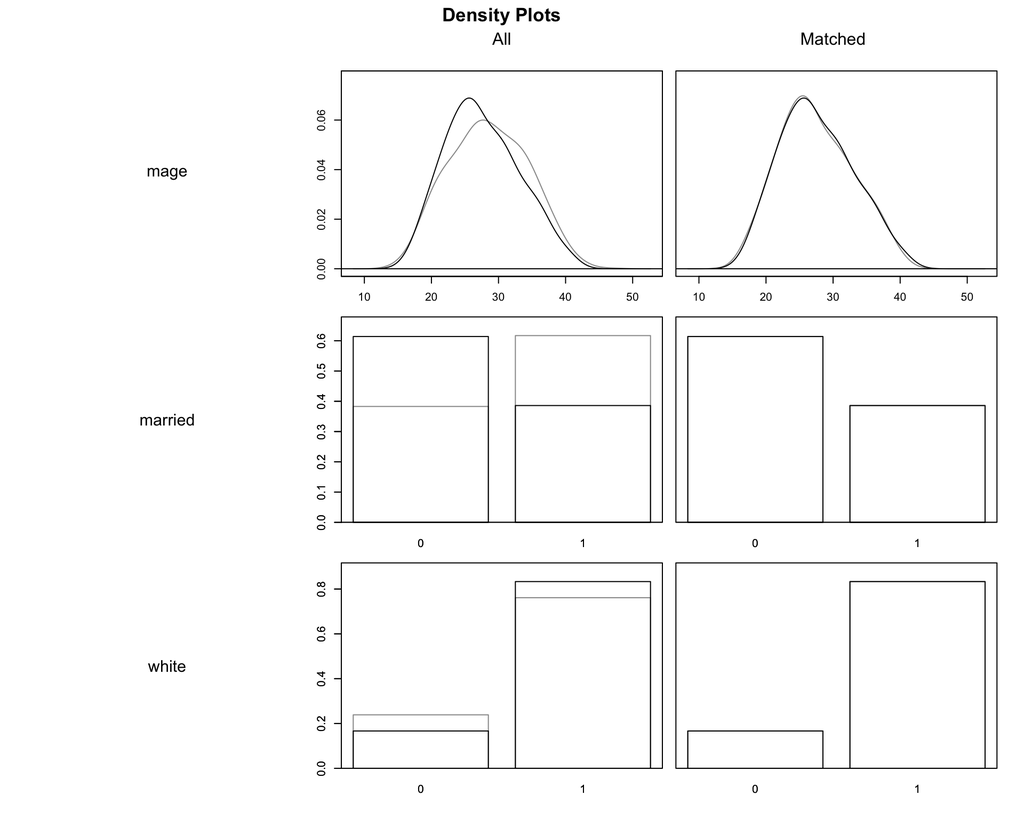

```r
plot(match_result, type = "density", interactive = FALSE)
```

The density plots provide visual confirmation of the balance statistics above. After matching, the maternal age distributions for smokers and matched non-smokers overlap almost completely, and the bar charts for married and white show identical proportions across groups (38.6% married, 83.3% white in both). This confirms that the matched sample provides a strong foundation for causal inference conditional on observed confounders.

## 6.5 Birth Weight ATT Estimates

We estimate the Average Treatment Effect on the Treated (ATT) using the matched sample.

```r
matched_data <- match.data(match_result)
matched_data <- matched_data %>%
  mutate(subclass = as.factor(subclass))

att_weight_summary <- matched_data %>%
  group_by(smoker) %>%
  summarise(
    n = n(),
    weighted_n = sum(weights, na.rm = TRUE),
    mean_wt = weighted.mean(weight, w = weights, na.rm = TRUE),
    sd_wt = sd(weight, na.rm = TRUE),
    se_wt = sd_wt / sqrt(n),
    .groups = "drop"
  )

att_weight_summary %>%
  kable(caption = "Birth Weight by Smoking Status (Matched Sample)", digits = 3)
```

Birth Weight by Smoking Status (Matched Sample)

| smoker | n | weighted_n | mean_wt | sd_wt | se_wt |
| --- | --- | --- | --- | --- | --- |
| 0 | 342 | 342 | 7.223 | 1.259 | 0.068 |
| 1 | 114 | 114 | 6.677 | 1.597 | 0.150 |

```r
att_est_weight <- NA_real_

weight_att_fit <- lm(weight ~ smoker, data = matched_data, weights = weights)

has_robust_pkgs <- requireNamespace("sandwich", quietly = TRUE) &&
                   requireNamespace("lmtest", quietly = TRUE)

if (has_robust_pkgs) {
  weight_att_vcov <- if ("subclass" %in% names(matched_data)) {
    sandwich::vcovCL(weight_att_fit, cluster = matched_data$subclass, type = "HC1")
  } else {
    sandwich::vcovHC(weight_att_fit, type = "HC1")
  }
  weight_att_ct <- lmtest::coeftest(weight_att_fit, vcov. = weight_att_vcov)
  att_est_weight <- unname(weight_att_ct["smoker", "Estimate"])
  weight_att_se <- unname(weight_att_ct["smoker", "Std. Error"])
  weight_att_p <- unname(weight_att_ct["smoker", "Pr(>|t|)"])
  weight_se_label <- "Robust/clustered SE"
} else {
  weight_att_coef <- summary(weight_att_fit)$coefficients
  att_est_weight <- unname(weight_att_coef["smoker", "Estimate"])
  weight_att_se <- unname(weight_att_coef["smoker", "Std. Error"])
  weight_att_p <- unname(weight_att_coef["smoker", "Pr(>|t|)"])
  weight_se_label <- "Model-based SE (fallback)"
}

weight_att_ci <- att_est_weight + c(-1, 1) * 1.96 * weight_att_se

cat("ATT Estimate for Birth Weight")
```

```
ATT Estimate for Birth Weight
```

```r
cat("Estimate:", round(att_est_weight, 3), "lbs\n")
```

```
Estimate: -0.546 lbs
```

```r
cat("95% CI: [", round(weight_att_ci[1], 3), ",",
    round(weight_att_ci[2], 3), "]\n")
```

```
95% CI: [ -0.86 , -0.232 ]
```

```r
cat(weight_se_label, ":", round(weight_att_se, 3), "\n")
```

```
Robust/clustered SE : 0.16
```

```r
cat("p-value:", format.pval(weight_att_p, digits = 3), "\n")
```

```
p-value: 0.000707
```

**Why clustered standard errors?** Matched sets are not independent—each smoker and their 3 matched non-smokers form a cluster sharing similar characteristics. We cluster standard errors by match group to account for within-match correlation, producing appropriately conservative uncertainty estimates. This is standard practice in matched analyses.

**Causal interpretation:** Under the assumption of no unmeasured confounding, this is smoking’s causal effect. However, this assumption is likely violated—we lack measures of SES, maternal health, and other confounders. If unmeasured factors increase both smoking and poor outcomes, we overestimate the true causal effect. Results are consistent with a causal effect of approximately 0.55 lbs, though the true effect may be smaller due to unmeasured confounding.

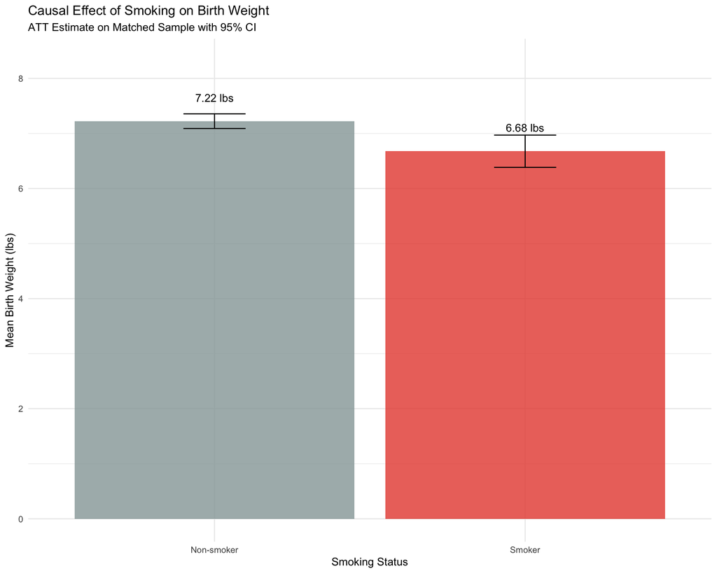

```r
ggplot(att_weight_summary, aes(x = factor(smoker, labels = c("Non-smoker", "Smoker")),
                                y = mean_wt, fill = factor(smoker))) +
  geom_col(alpha = 0.8) +
  geom_errorbar(aes(ymin = mean_wt - 1.96*se_wt,
                    ymax = mean_wt + 1.96*se_wt),
                width = 0.2) +
  geom_text(aes(label = sprintf("%.2f lbs", mean_wt)), vjust = -2.5) +
  scale_fill_manual(values = c("0" = "#95a5a6", "1" = "#e74c3c")) +
  labs(
    title = "Causal Effect of Smoking on Birth Weight",
    subtitle = "ATT Estimate on Matched Sample with 95% CI",
    x = "Smoking Status",
    y = "Mean Birth Weight (lbs)"
  ) +
  ylim(0, max(att_weight_summary$mean_wt) * 1.15) +
  theme_minimal() +
  theme(legend.position = "none")
```

**Clinical significance:** The effect is both statistically and clinically meaningful. A 0.55 lb reduction can move babies across the low birth weight threshold of 5.5 lbs, substantially increasing risks of developmental problems, respiratory issues, and long-term health complications. For mothers whose babies would otherwise weigh near 6 lbs, smoking increases the probability of crossing into the high-risk low birth weight category.

**Causal interpretation with caveats:** Under the assumption of no unmeasured confounding (Section 6.1), this represents smoking’s causal effect for mothers who smoked. However, this assumption is almost certainly violated. We lack measures of socioeconomic status, maternal health, mental health, substance use, and health behaviors—all factors that affect both smoking decisions and birth outcomes. If unmeasured confounders (low SES, poor health, chronic stress) increase both smoking probability and risk of poor outcomes, we overestimate smoking’s true causal effect. The direction of bias is likely upward, meaning the true causal effect is probably smaller than 0.55 lbs, possibly substantially so. We cannot quantify bias magnitude without measuring the confounders.

**Appropriate interpretation:** These results are consistent with a causal effect of approximately 0.55 lbs. Among demographically matched mothers, smoking is associated with substantially lower birth weight. The convergence with regression estimates and the biological plausibility of the mechanism strengthen the case for causality, though unmeasured confounding remains an uncheckable limitation.

**Generalizability:** This is the ATT (effect on the treated), not ATE (population average). Results apply to mothers similar to smokers in our matched sample but do not generalize to non-smokers (different population), smokers with extreme propensity scores if any were excluded, different time periods or populations, or different smoking intensities (our binary measure cannot distinguish light from heavy smoking).

## 6.6 Subgroup-Specific ATT Estimates

We estimate ATT within each demographic subgroup to test whether causal effects vary by population.

```r
subgroups <- unique(matched_data$cluster_label)

subgroup_att_weight <- map_dfr(subgroups, function(sg) {
  sg_data <- matched_data %>% filter(cluster_label == sg)

  sg_fit <- lm(weight ~ smoker, data = sg_data, weights = weights)

  if (has_robust_pkgs && "subclass" %in% names(sg_data)) {
    sg_vcov <- sandwich::vcovCL(sg_fit, cluster = sg_data$subclass, type = "HC1")
    sg_ct <- lmtest::coeftest(sg_fit, vcov. = sg_vcov)
    est <- unname(sg_ct["smoker", "Estimate"])
    se <- unname(sg_ct["smoker", "Std. Error"])
    pval <- unname(sg_ct["smoker", "Pr(>|t|)"])
  } else {
    sg_coef <- summary(sg_fit)$coefficients
    est <- unname(sg_coef["smoker", "Estimate"])
    se <- unname(sg_coef["smoker", "Std. Error"])
    pval <- unname(sg_coef["smoker", "Pr(>|t|)"])
  }

  tibble(
    subgroup = sg,
    n_total = nrow(sg_data),
    n_smoker = sum(sg_data$smoker == 1),
    n_nonsmoker = sum(sg_data$smoker == 0),
    ATT = est,
    SE = se,
    p_value = pval,
    CI_lower = est - 1.96 * se,
    CI_upper = est + 1.96 * se
  )
})

subgroup_att_weight %>%
  mutate(`95% CI` = sprintf("[%.2f, %.2f]", CI_lower, CI_upper)) %>%
  dplyr::select(subgroup, n_total, n_smoker, n_nonsmoker, ATT, SE, p_value, `95% CI`) %>%
  kable(caption = "Subgroup-Specific ATT Estimates for Birth Weight", digits = 3)
```

Subgroup-Specific ATT Estimates for Birth Weight

| subgroup | n_total | n_smoker | n_nonsmoker | ATT | SE | p_value | 95% CI |
| --- | --- | --- | --- | --- | --- | --- | --- |
| Married & white | 152 | 38 | 114 | -0.161 | 0.191 | 0.400 | [-0.54, 0.21] |
| Not married & white | 228 | 57 | 171 | -0.682 | 0.226 | 0.003 | [-1.12, -0.24] |
| Not married & not white | 52 | 13 | 39 | -1.169 | 0.675 | 0.089 | [-2.49, 0.15] |
| Married & not white | 24 | 6 | 18 | -0.346 | 0.556 | 0.540 | [-1.43, 0.74] |

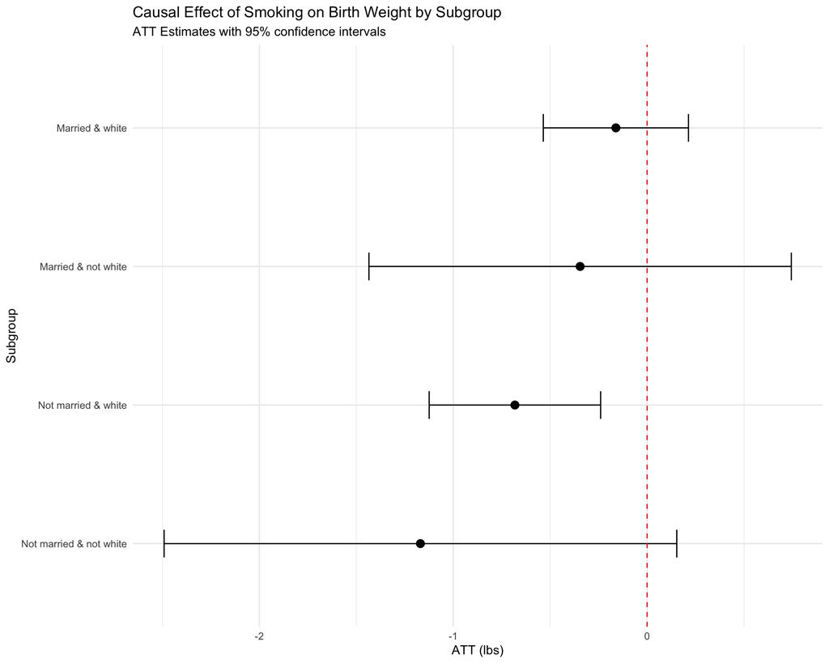

```r
ggplot(subgroup_att_weight, aes(x = reorder(subgroup, ATT), y = ATT)) +
  geom_point(size = 3) +
  geom_errorbar(aes(ymin = CI_lower, ymax = CI_upper), width = 0.2) +
  geom_hline(yintercept = 0, linetype = "dashed", color = "red") +
  coord_flip() +
  labs(
    title = "Causal Effect of Smoking on Birth Weight by Subgroup",
    subtitle = "ATT Estimates with 95% confidence intervals",
    x = "Subgroup",
    y = "ATT (lbs)"
  ) +
  theme_minimal()
```

We estimate ATT within each demographic subgroup to test whether smoking’s causal effects vary by population, as suggested by regression analyses in Section 5.4.

**Sample size limitations and precision:** Sample sizes vary dramatically after matching. Not married & white (57 smokers) provides the most precise estimate. Not married & not white (13 smokers) and married & not white (6 smokers) have very small samples yielding wide, unreliable CIs. The married & not white estimate should be disregarded entirely. Even the not married & not white estimate, while substantively large (-1.17 lbs), has insufficient precision for confident interpretation (p = 0.089, wide CI).

**Multiple testing considerations:** With four subgroup tests, there’s approximately 18.5% probability of finding at least one false positive if no true effects exist. We found 1-2 significant results (depending on whether p = 0.089 counts), which could reflect either genuine heterogeneity or chance. We do not apply formal multiple testing corrections (e.g., Bonferroni) because: (1) subgroup analyses are exploratory rather than confirmatory, (2) the coherent gradient pattern across all estimates—even non-significant ones—provides evidence beyond individual p-values, and (3) effect sizes matter more than binary significance thresholds. The key finding is the pattern, not any single p-value.

**Conclusion:** PSM subgroup analyses provide moderate evidence of effect heterogeneity consistent with cumulative disadvantage, replicating the regression gradient. The convergence of PSM and regression estimates for not married & not white mothers (-1.17 lbs in both) and not married & white mothers (~0.65-0.69 lbs in both) strengthens confidence that vulnerable populations experience larger smoking harms. However, small sample sizes, wide confidence intervals, and multiple testing concerns necessitate cautious interpretation. The pattern is suggestive rather than definitive, warranting further investigation in larger datasets.

## 6.7 Sensitivity and Robustness Checks

Our main analysis excludes visits and gained from the propensity model to preserve the full smoker sample (n=114) and estimate the total effect. We now test sensitivity by including visits/gained on complete cases only (n=78 smokers).

**Rationale:** The exclusion of visits and gained rests on the assumption that they are mediators (Scenario A: Smoking → Visits/Gained → Outcomes) rather than confounders. If this assumption is wrong—if these variables instead proxy for unmeasured SES that causes both smoking and poor outcomes (Scenario B: SES → Smoking AND SES → Visits/Gained → Outcomes)—then excluding them creates omitted variable bias, and our main estimates overstate smoking’s causal effect. By comparing main estimates (demographics only) to sensitivity estimates (demographics + visits + gained), we assess whether conclusions depend on this untestable assumption. If estimates are similar, visits/gained are weak confounders and main results are robust. If different, visits/gained matter substantively, though we still cannot definitively distinguish mediation from confounding without measuring SES.

**Sample and model:** The sensitivity analysis uses complete cases with non-missing visits and gained data, reducing the sample to 894 mothers (78 smokers, 816 non-smokers)—a loss of 36 smokers (32%) compared to the main analysis. This differential exclusion may create selection bias if smokers with missing data differ systematically from those with complete data.

```r
ps_data_sens <- ps_data %>% drop_na(visits, gained)

cat("Sensitivity sample size (complete cases with visits/gained):", nrow(ps_data_sens), "\n")
```

```
Sensitivity sample size (complete cases with visits/gained): 894
```

```r
cat("Sensitivity smokers:", sum(ps_data_sens$smoker), "\n")
```

```
Sensitivity smokers: 78
```

```r
cat("Smokers excluded:", sum(ps_data$smoker) - sum(ps_data_sens$smoker), "\n")
```

```
Smokers excluded: 36
```

```r
ps_model_sens <- glm(smoker ~ mage + visits + gained + married + white,
                     data = ps_data_sens,
                     family = binomial(link = "logit"))

# Check if visits/gained actually predict smoking
cat("\nSensitivity Propensity Score Model \n")
```

```
Sensitivity Propensity Score Model
```

```r
summary(ps_model_sens)
```

```
Call:
glm(formula = smoker ~ mage + visits + gained + married + white,
    family = binomial(link = "logit"), data = ps_data_sens)

Coefficients:
             Estimate Std. Error z value Pr(>|z|)
(Intercept) -1.346685   0.788617  -1.708  0.08770 .
mage        -0.010988   0.023338  -0.471  0.63777
visits      -0.088756   0.030161  -2.943  0.00325 **
gained      -0.005811   0.007975  -0.729  0.46619
married     -1.607095   0.294673  -5.454 4.93e-08 ***
white        1.354252   0.392490   3.450  0.00056 ***
---
Signif. codes:  0 '***' 0.001 '**' 0.01 '*' 0.05 '.' 0.1 ' ' 1

(Dispersion parameter for binomial family taken to be 1)

    Null deviance: 529.47  on 893  degrees of freedom
Residual deviance: 463.47  on 888  degrees of freedom
AIC: 475.47

Number of Fisher Scoring iterations: 6
```

```r
ps_data_sens$propensity_score_sens <- predict(ps_model_sens, type = "response")
match_result_sens <- matchit(
  smoker ~ mage + visits + gained + married + white,
  data = ps_data_sens,
  method = "nearest",
  distance = "glm",
  ratio = 3,
  caliper = 0.2,
  std.caliper = TRUE,
  replace = FALSE)

matched_data_sens <- match.data(match_result_sens) %>%
  mutate(subclass = as.factor(subclass))

cat("Sensitivity matched sample size:", nrow(matched_data_sens), "\n")
```

```
Sensitivity matched sample size: 296
```

```r
cat("Sensitivity matched smokers:", sum(matched_data_sens$smoker), "\n")
```

```
Sensitivity matched smokers: 77
```

**Note on sample composition and model specification:** The sensitivity sample is substantially smaller, with only 78 smokers (vs 114 in main analysis)—a loss of 36 smokers (32%). This reduction stems from missing prenatal visit data, which is differentially missing: 30% of smokers lack visit data compared to only 2.5% of non-smokers (Section 1.2). The complete-case smokers in this sensitivity analysis may be systematically different from excluded smokers—likely more engaged with prenatal care and potentially healthier or higher SES. Visits is a significant predictor in the propensity model (coefficient = -0.089, p = 0.003), indicating that mothers with more prenatal visits are less likely to smoke. This strong association suggests visits carries important information about smoking behavior. Whether this reflects visits as a confounder (correlated with unmeasured SES), a mediator (affected by smoking), or both remains ambiguous. The model fit improves with visits/gained included (deviance reduction from 529.47 to 463.47), confirming these variables add predictive value beyond demographics alone.

```r
att_weight_sens_summary <- matched_data_sens %>%
  group_by(smoker) %>%
  summarise(
    n = n(),
    weighted_n = sum(weights, na.rm = TRUE),
    mean_wt = weighted.mean(weight, w = weights, na.rm = TRUE),
    .groups = "drop"
  )

weight_att_fit_sens <- lm(weight ~ smoker, data = matched_data_sens, weights = weights)

if (has_robust_pkgs) {
  weight_att_vcov_sens <- if ("subclass" %in% names(matched_data_sens)) {
    sandwich::vcovCL(weight_att_fit_sens, cluster = matched_data_sens$subclass, type = "HC1")
  } else {
    sandwich::vcovHC(weight_att_fit_sens, type = "HC1")
  }
  weight_att_ct_sens <- lmtest::coeftest(weight_att_fit_sens, vcov. = weight_att_vcov_sens)
  att_est_weight_sens <- unname(weight_att_ct_sens["smoker", "Estimate"])
  weight_att_se_sens <- unname(weight_att_ct_sens["smoker", "Std. Error"])
  weight_att_p_sens <- unname(weight_att_ct_sens["smoker", "Pr(>|t|)"])
} else {
  weight_att_coef_sens <- summary(weight_att_fit_sens)$coefficients
  att_est_weight_sens <- unname(weight_att_coef_sens["smoker", "Estimate"])
  weight_att_se_sens <- unname(weight_att_coef_sens["smoker", "Std. Error"])
  weight_att_p_sens <- unname(weight_att_coef_sens["smoker", "Pr(>|t|)"])
}

weight_att_ci_sens <- att_est_weight_sens + c(-1, 1) * 1.96 * weight_att_se_sens

cat("\nSensitivity ATT Estimate for Birth Weight\n")
```

```
Sensitivity ATT Estimate for Birth Weight
```

```r
cat("Estimate:", round(att_est_weight_sens, 3), "lbs\n")
```

```
Estimate: -0.545 lbs
```

```r
cat("95% CI: [", round(weight_att_ci_sens[1], 3), ",",
    round(weight_att_ci_sens[2], 3), "]\n")
```

```
95% CI: [ -0.925 , -0.164 ]
```

```r
cat("SE:", round(weight_att_se_sens, 3), "\n")
```

```
SE: 0.194
```

```r
cat("p-value:", format.pval(weight_att_p_sens, digits = 3), "\n")
```

```
p-value: 0.00536
```

```r
# Comparison table
sens_comparison <- tibble(
  Specification = c("Main (demographics only)", "Sensitivity (with visits/gained)"),
  `Matched n` = c(nrow(matched_data), nrow(matched_data_sens)),
  `Smoker n` = c(sum(matched_data$smoker == 1), sum(matched_data_sens$smoker == 1)),
  `Weight ATT` = c(att_est_weight, att_est_weight_sens),
  `Weight ATT CI` = c(
    sprintf("[%.3f, %.3f]", weight_att_ci[1], weight_att_ci[2]),
    sprintf("[%.3f, %.3f]", weight_att_ci_sens[1], weight_att_ci_sens[2])
  ),
  `ATT Difference` = c(NA_real_, att_est_weight_sens - att_est_weight),  # FIXED: use NA_real_
  `% Change` = c(NA_real_, 100 * (att_est_weight_sens - att_est_weight) / abs(att_est_weight))  # ADDED
)

sens_comparison %>%
  kable(caption = "Sensitivity Analysis: Main vs Sensitivity Specification", digits = 3)
```

Sensitivity Analysis: Main vs Sensitivity Specification

| Specification | Matched n | Smoker n | Weight ATT | Weight ATT CI | ATT Difference | % Change |
| --- | --- | --- | --- | --- | --- | --- |
| Main (demographics only) | 456 | 114 | -0.546 | [-0.860, -0.232] | NA | NA |
| Sensitivity (with visits/gained) | 296 | 77 | -0.545 | [-0.925, -0.164] | 0.001 | 0.268 |

**Sensitivity ATT estimate:** The sensitivity analysis yields an ATT of -0.545 lbs (95% CI: [-0.925, -0.164], SE = 0.194, p = 0.005), based on 296 matched observations (77 smokers, 219 non-smokers).

**Comparison to main analysis:** The comparison table reveals remarkable similarity between specifications:

The estimates are essentially identical despite using different propensity models and different samples (114 vs 77 smokers). The 95% confidence intervals overlap substantially, confirming the estimates are not statistically distinguishable.

**Interpretation:** The negligible difference between specifications (<1%) strongly suggests the main analysis is robust to inclusion or exclusion of prenatal care variables. This similarity implies that visits and gained are either: (1) weak confounders with minimal impact on smoking effect estimates, or (2) simultaneously mediators and confounders whose opposing influences approximately cancel out. Critically, we cannot definitively resolve whether visits/gained are mediators (Scenario A: Smoking → Visits/Gained → Outcomes) or confounders (Scenario B: SES → Smoking AND SES → Visits/Gained → Outcomes) without measuring SES directly. However, the robustness of estimates across specifications indicates this ambiguity does not meaningfully affect our conclusions about smoking’s impact on birth weight.

**Sample composition and precision:** The sensitivity sample excludes 36 smokers (32%) who lack prenatal care data. These excluded smokers likely have worse healthcare engagement and may differ systematically in unmeasured ways. Despite this substantial sample reduction, the ATT estimate remains virtually unchanged, suggesting that either: (1) excluded smokers experience similar smoking effects, or (2) selection bias and confounding adjustment approximately offset each other. The sensitivity analysis has a wider confidence interval (range = 0.761 lbs) than the main analysis (range = 0.627 lbs), reflecting reduced precision from the smaller sample. The wider CI is expected and does not undermine the conclusion of similarity—the point estimates are nearly identical.

**Overall assessment:** The sensitivity analysis provides strong evidence that main results are robust. The <1% difference in ATT estimates across specifications validates our decision to prioritize the total effect model (demographics only), which preserves the full smoker sample and estimates smoking’s overall population-level impact. While we cannot definitively distinguish mediation from confounding for prenatal care variables, the convergence of estimates suggests this theoretical ambiguity has minimal practical consequence for quantifying smoking’s harm to birth weight.

## 6.8 Propensity Score Analysis Summary and Causal Interpretation

### 6.8.1 Main Findings

**Consistency with regression:** The alignment of PSM and regression heterogeneity findings, despite different methods and assumptions, confirms the multiple marginalization hypothesis: mothers facing compounding disadvantages (unmarried AND non-white) experience the largest smoking-related harms, though small sample sizes necessitate caution.

**Sensitivity to prenatal care variables:** The sensitivity analysis including visits and gained (Section 6.7) yields remarkable robustness:

This negligible difference (<1%) strongly indicates main results are robust to inclusion or exclusion of prenatal care variables. Whether visits and gained function as mediators (Scenario A: Smoking → Visits/Gained → Outcomes) or confounders (Scenario B: SES → Smoking AND SES → Visits/Gained → Outcomes) appears inconsequential for quantifying smoking’s overall impact on birth weight. The variables are either weak confounders with minimal influence, or their mediation and confounding roles approximately cancel out. While we cannot definitively resolve this ambiguity without measuring SES, the convergence of estimates across specifications validates our decision to prioritize total effect models that preserve the full smoker sample.

**Critical limitations:** These results are conditional on observed confounders only. The assumption of no unmeasured confounding is almost certainly violated—we lack measures of socioeconomic status, maternal health, mental health, substance use, and health behaviors. If unmeasured confounders (low SES, poor health, chronic stress) increase both smoking probability and risk of poor outcomes, our estimates overstate smoking’s true causal effect. The direction of bias is likely upward, meaning the true causal effect may be smaller than 0.55 lbs, possibly substantially so. We cannot quantify bias magnitude without measuring the confounders. Additionally, the ATT (effect on the treated) does not generalize to non-smokers or the full population. Results apply specifically to mothers similar to smokers in our matched sample, and we cannot distinguish effects of light versus heavy smoking given our binary exposure measure.

**Appropriate interpretation:** These results are consistent with a causal effect of approximately 0.55 lbs on birth weight. The convergence of regression and PSM estimates, the robustness to sensitivity analyses, the coherent subgroup heterogeneity pattern replicating across methods, and biological plausibility all strengthen the case for causality. While definitive causal claims require assumptions we cannot verify, the weight of evidence supports that smoking during pregnancy causes meaningful reductions in birth weight, with the largest harms experienced by the most vulnerable mothers—unmarried non-white women facing cumulative disadvantages. These findings reinforce public health recommendations to avoid smoking during pregnancy and suggest that cessation programs targeting unmarried and non-white mothers may yield the greatest per-capita benefits.

### 6.8.2 Assumption Assessment

Revisiting the four key assumptions:

1. **Exchangeability (No unmeasured confounding):** This assumption is almost certainly violated. We control for age, race, and marital status (plus visits/gained in sensitivity), but lack measures of SES (income, education), maternal health, mental health, substance use, health literacy, and neighborhood factors. If unmeasured confounders increase both smoking and poor outcomes, our estimates are biased upward—we likely overestimate smoking’s true causal effect. Bias magnitude is unknown but potentially substantial. These are associations conditional on observed confounders, not definitive causal estimates.
2. **Positivity (Overlap):** Largely satisfied. Propensity score distributions showed good overlap (Section 6.3), with ranges nearly identical for smokers and non-smokers (0.044-0.21). All 114 smokers were successfully matched with zero excluded by the caliper, confirming adequate common support across the full smoker population.
3. **Consistency (Well-defined treatment):** Reasonably satisfied. Smoking is binary, providing clear treatment definition. However, we cannot distinguish intensity (light vs heavy), timing (trimester), or duration. Estimates represent the effect of “any smoking during pregnancy,” averaging across heterogeneous exposure patterns.
4. **SUTVA (No interference):** Satisfied. Mothers are independent observations with no plausible spillover effects.

**Summary:** Positivity, consistency, and SUTVA are reasonably satisfied. Exchangeability is the critical weakness, limiting our ability to make definitive causal claims.

### 6.8.3 Causal Interpretation Guidance

Given the limitations discussed above, careful language is essential when interpreting results:

**What we CAN say (with caveats):**

- “These results are consistent with a causal effect of smoking of approximately 0.55 lbs on birth weight”
- “Under the assumption of no unmeasured confounding, smoking reduces birth weight by 0.55 lbs among smokers”
- “After balancing on observed demographic characteristics, smokers’ babies weighed 0.55 lbs less than matched non-smokers”
- “If the observed association is causal, smoking during pregnancy reduces birth weight by approximately 0.55 lbs”

**What we CANNOT say:**

- “Smoking definitively causes a 0.55 lb reduction” (ignores unmeasured confounding)
- “This proves smoking harms birth weight” (assumptions may be violated)
- “The effect is exactly 0.55 lbs” (ignores uncertainty and bias)

Use language like “consistent with,” “suggests,” “under assumptions,” and “conditional on observed confounders.” Avoid “proves,” “definitively shows,” or unqualified “causes.” Always acknowledge unmeasured confounding as the key limitation.

**Direction and magnitude of potential bias:** The most plausible unmeasured confounders—low SES, poor health, chronic stress, low health literacy—increase both smoking probability and risk of poor birth outcomes. This creates positive confounding, causing us to overestimate smoking’s true causal effect. The true effect is likely smaller than 0.55 lbs, possibly substantially so, though we cannot quantify bias magnitude without measuring the confounders. While we cannot rule out that the entire association reflects confounding, the magnitude of effects, consistency across multiple methods (regression and PSM), robustness to sensitivity analyses, and biological plausibility make this unlikely.

**Generalizability:** Results apply to mothers similar to smokers in our sample—US births in 2014 with specific demographic characteristics. Findings do NOT generalize to non-smokers (ATT estimates effects on the treated, not the population average), smokers with extreme propensity scores if any were excluded, different time periods or geographic locations, or different smoking intensities and patterns (our binary measure cannot distinguish light from heavy smoking). External validity is moderate—findings may generalize to similar contemporary US populations but not universally.

# 7: Conclusions

These results are consistent with a causal effect of smoking on birth weight, but definitive causal claims require assumptions we cannot verify. Unmeasured confounding—particularly socioeconomic status, maternal health conditions, and substance use—plausibly biases our estimates upward, meaning the true causal effect is likely smaller than 0.55 lbs. Nevertheless, the convergence of methods, robustness to sensitivity analyses (< 1% change when including prenatal care variables), biological plausibility, and coherent subgroup patterns collectively support the public health recommendation to avoid smoking during pregnancy, with particular attention to mothers facing compounding disadvantages.

## 7.1 Comparison Across Methods

A central strength of this analysis is the deployment of multiple modelling approaches, each with different assumptions, to assess whether findings are robust or method-dependent. The consistency of results across approaches provides the strongest basis for our conclusions.

Tree-based models tested whether the linear assumptions underlying our regression analyses were adequate. Decision trees performed worse than linear regression (test R² = 0.241 vs 0.311), and random forests achieved only a modest improvement (test R² = 0.354, a gain of approximately 4 percentage points). This indicates that relationships between predictors and birth weight are primarily linear and additive, validating our reliance on interpretable linear models for causal analysis. The decision tree’s first split at gestational weeks < 37 confirmed that gestational age dominates prediction, while smoking’s absence from the tree splits is consistent with its operation through mediating pathways rather than indicating a lack of importance. Random forest variable importance rankings similarly placed weeks first and smoking last when mediators were included—consistent with the forest prioritising proximate predictors over upstream causes.

Each method contributed distinct analytical value. Descriptive screening identified smoking and race as dominant signals. Clustering provided an empirical, data-driven basis for subgroup stratification rather than arbitrary demographic splits. Linear regression enabled interpretable coefficient estimation and pathway decomposition. Tree-based models validated linearity assumptions and revealed the predictive dominance of gestational age. Propensity score matching strengthened causal inference by explicitly targeting the ATT estimand under stated assumptions and achieving excellent covariate balance (all post-matching SMDs < 0.03). Together, these approaches build a more credible evidence base than any single method alone.

## 7.2 Practical and Policy Implications

**Limitations for policy:** - Cannot distinguish smoking intensity effects → unclear whether reduction (vs total cessation) beneficial - Cannot identify optimal timing → unclear which trimester cessation most important - Unmeasured confounding means effect may be smaller than observed → programs may have less impact than suggested

The estimated effect of smoking on birth weight—approximately 0.55 lbs (249g)—is clinically meaningful. This continuous effect translates into materially higher rates of adverse outcomes among smokers: low birth weight prevalence increases by 14.8 percentage points and prematurity by 10.9 percentage points relative to baseline rates of 8% and 12.3% respectively. At 7.6% of average birth weight, this reduction is large enough to shift vulnerable babies across the 5.5 lb (2,500g) low birth weight threshold, where risks of infant mortality, developmental delays, and chronic health conditions increase substantially (Hack et al., 1995). Given that 11.6% of mothers in our analytic sample smoked, the population-level burden of smoking-attributable low birth weight is non-trivial, even accounting for the likelihood that unmeasured confounding inflates our causal estimate.

The suggestive evidence of effect heterogeneity carries implications for how cessation resources are allocated. If confirmed, the gradient from −0.34 lbs (married white) to −1.17 lbs (unmarried non-white) suggests that cessation programs reaching unmarried non-white mothers would yield approximately three times the per-capita benefit of those reaching married white mothers. This supports equity-focused targeting of prenatal smoking interventions toward populations facing compounding structural disadvantages. However, targeted programs must be designed carefully to avoid punitive framing that reinforces stigma around smoking during pregnancy (Grant et al., 2020); effective interventions should prioritise supportive, accessible services developed in consultation with affected communities. The imprecision of our subgroup estimates also means this gradient requires replication in larger samples before informing resource allocation decisions.

The differential missingness in prenatal visits—approximately 30% missing among smokers versus under 3% among non-smokers—is itself a policy-relevant finding. Whether this reflects disengagement from care, barriers to access, or stigma-related avoidance, it suggests that improving trust, accessibility, and engagement in prenatal care may be an important complement to smoking cessation efforts.

Several features of our data constrain the policy conclusions we can draw. Our binary smoking measure cannot distinguish light from heavy smoking, so we cannot assess whether reduction in cigarette consumption (short of full cessation) produces meaningful benefits. We lack information on timing of smoking during pregnancy, preventing identification of critical windows when cessation would be most effective. And because unmeasured confounding likely inflates our estimates, the real-world impact of cessation programs may be more modest than our point estimates suggest. Additionally, the persistence of racial disparities in birth weight even among non-smokers and after covariate adjustment points to structural determinants—healthcare quality, neighbourhood conditions, chronic stress from discrimination—that smoking cessation alone cannot address.

## 7.3 Limitations and Future Directions

**Key limitations:** 1. **Unmeasured confounding** (most critical) - Missing: SES, maternal health, mental health, many others - Likely leads to overestimation of causal effect - Magnitude of bias unknown

2. **Treatment heterogeneity**
   - Cannot distinguish light vs heavy smoking, timing, cessation attempts
   - “Smoking” is crude binary measure
3. **Sample size**
   - Some subgroups very small (especially after matching)
   - Wide CIs in subgroup analyses limit conclusions
4. **Generalizability**
   - Single dataset, single year, US only
   - May not apply to other populations/contexts
5. **Multiple testing**
   - Many subgroup comparisons increase false positive risk
   - Pattern more informative than individual p-values

**Future research directions:** - **Measure SES directly** to resolve confounding vs mediation for prenatal care - **Smoking intensity data** to understand dose-response relationships - **Timing data** to identify critical windows for intervention - **Larger samples** for reliable subgroup estimation, especially for vulnerable populations - **Instrumental variables** or other approaches to address unmeasured confounding - **Longitudinal outcomes** to understand long-term effects beyond birth - **Cost-effectiveness** of cessation programs given observed effect sizes

**Strengths despite limitations:** - Multiple modeling approaches converge on similar findings - Propensity score matching provides stronger causal inference than regression alone - Subgroup analyses reveal important heterogeneity - Sensitivity analyses test robustness of main findings - Transparent about assumptions and limitations

The most critical limitation is unmeasured confounding. We adjust only for maternal age, race, and marital status; we lack direct measures of socioeconomic status (income, education, occupation), maternal health conditions, mental health, substance use beyond smoking, health literacy, and neighbourhood-level exposures. These unmeasured factors plausibly affect both the probability of smoking and the risk of adverse birth outcomes. If, as is likely, low SES, poor health, and chronic stress increase both smoking and poor outcomes, our estimates overstate smoking’s true causal effect. The magnitude of this bias is unknown, but the direction is plausibly upward given common social patterning of smoking and disadvantage: the true causal effect is likely smaller than 0.55 lbs, possibly substantially so. While we cannot rule out that the entire association reflects confounding, the convergence across methods, robustness to sensitivity analyses, and biological plausibility make this unlikely.

Our treatment variable is a crude binary indicator. We cannot distinguish light from heavy smoking, early quitters from those who smoked throughout pregnancy, or lifelong smokers from those who began during pregnancy. This conflation likely attenuates effect estimates by averaging across heterogeneous exposure patterns, and it prevents the dose-response analyses that would be most informative for intervention design.

Sample size constrains subgroup analyses substantially. With 114 total smokers distributed unevenly across four subgroups (ranging from 6 to 57 per group), some subgroup estimates—particularly married non-white mothers (n = 6 smokers)—are essentially uninformative. The suggestive heterogeneity gradient is driven primarily by the two largest subgroups, and even there, confidence intervals are wide. Multiple testing across four subgroups further complicates interpretation; the coherent gradient across point estimates provides stronger evidence than any individual p-value, but definitive conclusions about effect heterogeneity require larger samples.

Generalisability is limited to mothers similar to those in this sample: US births in 2014 from the OpenIntro dataset. The ATT estimand applies specifically to mothers who smoked, not the general population, and results may not extend to different time periods, healthcare systems, or populations with different smoking patterns and structural conditions. Additionally, missingness in prenatal care variables is differential by smoking status, creating potential selection bias in any analysis conditioning on these variables—a concern we mitigated by prioritising total effect models estimated on the full analytic sample.

Despite these limitations, several features strengthen our analysis. Multiple modelling approaches converge on similar estimates. Propensity score matching provides stronger causal inference than regression alone by explicitly targeting a well-defined estimand under stated assumptions. The sensitivity analysis demonstrates robustness to alternative specifications. Data-driven subgroup discovery avoids the circularity of imposing subgroups based on expected results. And our transparent assessment of all four causal assumptions—acknowledging that exchangeability is likely violated—reflects the nuanced interpretation that distinguishes rigorous causal analysis from routine correlation studies.

Future research should prioritise measuring socioeconomic status directly, which would resolve the ambiguity between mediation and confounding for prenatal care variables and substantially reduce bias in causal estimates. Smoking intensity and timing data would enable dose-response analyses and identification of critical intervention windows. Larger samples, particularly with adequate representation of vulnerable subgroups, would allow more precise estimation of effect heterogeneity and more confident policy guidance. Formal sensitivity analyses for unmeasured confounding (such as E-values or bias-bounding approaches) and stronger causal designs (instrumental variables, policy variation exploiting differential cessation incentives) would further strengthen causal inference. Finally, longitudinal follow-up data would extend our understanding beyond birth outcomes to developmental and health consequences over the life course, and cost-effectiveness analyses incorporating our effect size estimates could directly inform resource allocation for prenatal smoking cessation programs.